# Logic for Programmers · 程序员的逻辑学

中英对照：中文在上，英文在下。代码、公式与原始图片保留原样。

Chinese above English. Original code, formulas, and illustrations preserved.

[figure not shown]

感谢 Tsvetan Tsvetanov、Predrag Gruevsky、Jeremy Kun、Saul Pwanson、Yeray Cabello、Igor Kuvychko、Puikei Cheng、Daniel Prager、Harald M Müller 和 Marianne Belloti 对内容提出反馈。感谢 David Mazarro、Jeroen Heijmans、Ophelia Stevens、Oyendrila Dobe、Nirmalya Sengupta、Mike Mull 和 Marcus Millin 指出文中的错误。Thanks to Tsvetan Tsvetanov, Predrag Gruevsky, Jeremy Kun, Saul Pwanson, Yeray Cabello, Igor Kuvychko, Puikei Cheng, Daniel Prager, Harald M Müller, and Marianne Belloti for feedback on content. Thanks to David Mazarro, Jeroen Heijmans, Ophelia Stevens, Oyendrila Dobe, Nirmalya Sengupta, Mike Mull, and Marcus Millin for identifying errors in the text.

感谢 Zac Hatfield Dodds 在 Sphinx 使用方面提供帮助，感谢 Alexey Zubkov 提供排版建议。Thanks to Zac Hatfield Dodds for helping with Sphinx and Alexey Zubkov for advice on typesetting.

在本书的制作过程中，Tim Nelson、Marianne Belloti 和 Saul Pwanson 都曾在不同阶段帮助我按计划推进。Tim Nelson, Marianne Belloti, and Saul Pwanson all helped me keep on schedule at various points in this book's production.

“求解器”一章 SMT 一节中使用的例子是 Nelson Elhage 想出来的。Nelson Elhage came up with the example I used for the SMT section of the "solver" chapter.

# 程序员的逻辑学Logic for Programmers

目录Contents

- 引言Intro
  - 测试版说明Beta Notes
  - v0.11 新增内容：New in v0.11:
  - 为什么写这本书Why this book
  - 设计理念Design Philosophy
  - 如何阅读本书How to Read This Book
- 逻辑速成A Crash Course in Logic
  - 谓词Predicates
  - 集合Sets
  - 量词Quantifiers
  - 记号Notation
  - 实践：重写规则In Practice: Rewrite Rules
  - 小结Summary
- 重构代码Refactoring Code
  - 简化条件表达式Simplifying Conditionals
  - 用量词重构Refactoring with Quantifiers
  - 程序不是数学Programs are not Math
  - 使用集合Using sets
  - 小结Summary
- 编写更好的测试Writing Better Tests
  - 强测试与弱测试Strong and Weak Tests
  - 实践：基于性质的测试In Practice: Property-Based Testing
  - 性质测试注意事项Notes on Property Testing
  - 小结Summary
- 功能正确性Functional Correctness
  - 断言Assertions
  - 契约Contracts
  - 契约与类型的比较Contracts vs Types
  - 多态与重构Polymorphism and Refactoring
  - 小结Summary
- 证明代码正确Proving Code Correct
  - 什么是证明？What is a proof?
  - 证明Proofs
  - 形式化验证Formal Verification
  - 小结Summary
- 情形分析Case Analysis
  - 决策表Decision Tables
  - 另一个需求示例Another Requirements Example
  - 分析代码Analyzing Code
  - 技巧Techniques
  - 什么时候不该选择表格？When is a Table the Wrong Choice?
  - 小结Summary
- 数据库Databases
  - 关系模型概览A Relational Model Overview
  - 查询数据Querying Data
  - 数据库约束Database Constraints
  - 约束就是查询Constraints Are Queries
  - 小结Summary
- 数据建模Data Modeling
  - 从数据中抽象Abstracting from Data
  - 实践：形式化规约In Practice: Formal Specification
  - 用规约发现缺陷Finding Bugs with Specifications
  - 小结Summary
- 系统建模System Modeling
  - 场景Situation
  - 相关逻辑The Logic
  - 实践：TLA+In Practice: TLA+
  - 实际应用中的规约Specification in the wild
  - 小结Summary
- 求解器Solvers
  - 逻辑Logic
  - 实践：求解器In Practice: Solvers
  - 该用哪一种？Which to use?
  - 小结Summary
- 逻辑编程Logic Programming
  - Prolog 语言Prolog
  - 演绎数据库Deductive Databases
  - 约束逻辑编程Constraint Logic Programming
  - 规划Planning
  - 小结Summary

附录Appendix

- 数学记号Math Notation
- 实用重写规则Useful Rewrite Rules
- 逻辑之外Beyond Logic
- 练习答案Answers to Exercises

# 引言Intro

## 测试版说明Beta Notes

这本书采用抢先阅读的发布方式，因此所有内容都还处于测试阶段。大部分内容已经写入，但我仍需润色和修订、增加练习、改进格式，并吸收读者的反馈。I’m doing early access with this book, so this is all beta. Most of the material is now in, but I still need to polish and revise it, add more exercises, improve formatting, and incorporate reader feedback.

我欢迎任何意见，尤其想了解以下几点：I welcome any and all comments. I’m particularly interested in:

1. 你觉得这些例子有用吗？练习有帮助吗？Do the examples seem useful to you? Were the exercises helpful?
2. 哪些主题最需要重点讲解？Which topics need the most focus?
3. 有哪些资源适合推荐为“延伸阅读”？What resources would be good to recommend as “further reading”?
4. 你希望看到哪些例子和新主题？What examples and new topics would you like to see?
5. 哪些地方需要更多练习？What needs more exercises?

你可以发邮件到 `h@hillelwayne.com` 联系我。非常感谢！You can email me at `h@hillelwayne.com`. Thank you very much!

说明Note

说明框中的内容，都是我写给各位早期读者的话，包括我拿不准的地方、打算进一步润色的地方、计划补写的内容等。[[双重大括号]] 也是类似的意思。欢迎随时向我提意见！Anything in a note box is a message from me to you as early readers. Things I’m uncertain about, things I plan to polish more, things that I plan to write, etc. [[double braces]] are similar. Feel free to throw comments my way!

## v0.11 新增内容：New in v0.11:

- 全新章节“证明代码正确”，涵盖证明、循环不变式和形式化验证Brand new chapter, “Proving Code Correct”, covering proofs, loop invariants, formal verification
- 全面重写“数据库”一章：Total rewrite of “Database” chapter:
  - 现在涵盖数据库表示、关系模型、查询、联接和约束Now covers database representations, relational model, queries, joins, and constraints
  - 新增两个关于约束的可执行 SQL 示例Two new executable SQL examples on constraints
  - 新增一幅图One new image
- 全面重写“功能正确性”：Total rewrite of “Functional Correctness”:
  - 现在涵盖断言、MISU、多态和相关建议Now covers assertions, MISU, polymorphism, advice
  - 循环不变式和形式化验证移至证明一章Loop invariants and formal verification moved to proofs chapter
- 全面重写“情形覆盖”，现更名为“情形分析”：Total rewrite of “Case Coverage”, now called “Case Analysis”:
  - 全新的引言和引入示例New introduction and motivating example
  - 增加用决策表分析代码的内容、相关技巧，以及不宜使用决策表的情形More material on analysing code with decision tables, techniques, when not to use DTs
  - 删除冗余示例Redundant examples removed
- 改进逻辑一章，现在先介绍远为常见的有作用域量词，再介绍无作用域量词Logic chapter improved, now covers the way-more-common scoped quantifiers before unscoped
- 修正“对称差”练习Fixed “symmetric difference” exercise
- 删除六道练习，新增十一道（总计增加 +5 道）Six exercises removed, eleven added (+5 total)
- 改进证明表和重写规则的格式Better format for proof tables and rewrite rules
- 对目录做了一些初步调整Some initial table of contents tweaks
- 修复 PDF 缺陷：提示侧栏现在能在 Acrobat 中正确显示Fixed PDF bug: admonition sidebars now render correctly in Acrobat

## 为什么写这本书Why this book

> 如果我在下午 3:05 启动一次构建，需要 12 分钟才能完成，那么构建会在什么时候结束？If I start a build at 3:05 PM and it takes 12 minutes to complete, when will the build be finished?

要回答这个问题，我们需要知道如何对数进行运算。研究数的数学叫作*算术*。算术教我们如何将两个数相乘、使用分数、判断两个数中哪个更大，等等。To answer this question, we need to how to manipulate numbers. The mathematics of numbers is called *arithmetic*. Arithmetic shows us how to multiply two numbers, use fractions, determine which of two numbers is larger, and more.

> 如果有条件表达式 `if(sensor_offline || inactive)`，而且我确定 `sensor_offline` 为真，那么 `inactive` 的值还重要吗？If I have the conditional `if(sensor_offline || inactive)`, and I know for sure that `sensor_offline` is true, does the value of `inactive` matter?

要回答这个问题，我们需要知道如何对布尔值进行运算。研究布尔值的数学叫作*逻辑*。逻辑教我们如何简化布尔表达式、使用集合、判断一个陈述是否比另一个更强，等等。To answer this question, we need to know how to manipulate booleans. The mathematics of booleans is called *logic*. Logic shows us how to simplify a boolean expression, use sets, determine if one statement is stronger than another, and more.

不过，算术与逻辑有一个关键区别。我们在小学学过算术，却很少有人正式学过逻辑。大多数程序员靠耳濡目染学到了一点逻辑，但即便如此，接触到的内容也很少超出基础范围。But there is one key difference between arithmetic and logic. We were taught arithmetic in elementary school. Few of us were formally taught logic. Most programmers pick up a little logic by osmosis, but even that rarely exposes people to anything beyond the basics.

因此，逻辑成了程序员能学到的数学主题中最有用的一个。但我们该怎么学呢？市面上有很多面向哲学家、数学家和计算机科学家的书，而这些人对理论的需求远大于对实践的需求。却没有哪本逻辑书是为希望掌握日常工作实用技能的自学程序员写的。这就好像没有人肯教我们骑自行车，只肯教我们造自行车。This makes logic the single most useful topic in math a programmer can learn. But how are we supposed to learn it? There are plenty of books available written for philosophers, mathematicians, and computer scientists, who all have far more need for the theory than the practice. There are no books on logic meant for the self-studying programmer, who is looking for practical skills useful in day-to-day work. It is as if nobody will teach us how to ride a bicycle, only how to build one.

这正是本书要做的事。我希望教你逻辑的基础知识，以及如何将它应用于各种日常软件问题，例如测试代码、设计数据库，或者梳理客户需求。读完本书，你将能够自如地操作逻辑表达式，并更深入地理解软件运用逻辑的各种方式——无论这种运用是否明确。That is the goal of this book. I aim to teach you the basics of logic and how to apply it to various everyday software problems, like testing code, designing a database, or working out customer requirements. By the end of this book, you will be comfortable manipulating logical expressions and have a greater understanding of all of the ways software uses logic, implicitly or not.

## 设计理念Design Philosophy

本书专门面向对形式数学知之甚少或完全不了解的程序员。在所有取舍中，我都优先考虑易懂易用，而不是精确或严谨。这是一本技术实用指南，而不是教科书。This book is meant specifically for programmers with little to no familiary with formal math. In all cases, I opted for accessibility and ease-of-use over precision or rigor. This is a technical how-to, not a textbook.

### 记号Notation

数学与编程有许多共同的运算，但表示方式不同，例如将“与”写成 ∧，而不是 `&&`。我会尽可能使用编程术语。我还附上了一份附录，列出常见编程符号与数学符号的对应关系。Mathematics shares many operations in common with programming but uses different representations, such as writing “and” as ∧ instead of `&&`. I will using programming terminology wherever possible. I included an appendix which maps conventional programming symbols to math symbols.

对于没有常见编程对应形式的数学符号（例如 ∀），我选择使用含义明确的英文等价写法（例如 `all`）。In cases where math symbols don’t have common programming analogs (such as ∀), I have opted to use an explicit English equivalent (such as `all`).

最后是数组下标的问题。数组 `arr` 是从 `arr[1]` 还是 `arr[0]` 开始的？编程界没有统一约定，因为不同语言有不同选择。我本想采用数学家的约定，可惜数学界同样没有统一约定：不同数学分支的选择也不一样！所以，除非是在演示采用从 1 开始的下标的工具或语言，否则我默认使用从 0 开始的下标；遇到例外时会明确说明。Lastly comes the question of array indexing. Does the array `arr` start at `arr[1]` or `arr[0]`? There is no universal programming convention, as different languages make different choices. I would use the mathematician’s convention except that does not exist either: different branches of mathematics make different choices too! So I will default to 0-based indexing unless demonstrating a tool or language which uses 1-based indexing, which I will explicitly note.

## 如何阅读本书How to Read This Book

建议先读逻辑速成，然后直接阅读你最感兴趣的技巧。除另有说明外，各技巧章节彼此独立；如果存在依赖，会提供指向前文的引用。I recommend first reading A Crash Course in Logic, and then moving to whichever technique looks most interesting. Techniques chapters are independent except when otherwise noted, in which case backreferences are provided.

较长的代码示例可在网上获取：https://github.com/logicforprogrammers/book-assets。Large code samples are available online at https://github.com/logicforprogrammers/book-assets.

### 练习Exercises

书中的练习旨在帮助你检验知识，并进一步培养技能。所有练习在书后都有答案。有些练习有多种解法。即使你的答案与“官方”解答不同，也可能是正确的！Exercises are provided to help you check your knowledge and develop your skills further. All exercises have solutions in the back of the book. Some of the exercises have multiple possible solutions. Your answer can be correct even if it differs from the “official” solution!

有些问题需要编写简短的代码片段。遇到这类问题时，你可以使用自己喜欢的任何语言。我给出的例子会使用 Python 或伪代码。在编写 Python 时，我尽量让代码易于理解，因此有些写法并不符合 Python 的惯用风格。Some questions involve writing short snippets of code. In these cases, use whatever language you like. I will personally give examples in Python or pseudocode. When writing Python, I have tried to make it as accessible as possible, meaning it does not do things in an idiomatic way.

# 逻辑速成A Crash Course in Logic

形式逻辑是一种非常强大的工具，同时也很简单。这一章将说明各个基本概念和语法的用途，并加以讲解。凭借编程经验，其中许多内容你可能早已熟悉！Formal logic is a very powerful tool, but it’s also very simple. Over this chapter, we’ll motivate and explain all of the basic concepts and syntax. Much of it may already be familiar to you from programming experience!

## 谓词Predicates

粗略地说，*谓词*就是返回布尔值的函数。作为程序员，你大概已经写过几十个谓词了。下面这些都是谓词：To a first approximation, a *predicate* is a function that returns a boolean. You have probably written dozens of predicates as a programmer. These are all predicates:

- 如果 x 大于 0，`Positive(x)` 就为真`Positive(x)` is true if x is greater than 0
- 如果 x 加 y 等于 z，`IsSum(x, y, z)` 就为真`IsSum(x, y, z)` is true if x plus y equals z
- 如果计算机 `c` 至少有 `r` 字节的物理内存，`RAMAtLeast(c, r)` 就为真。`RAMAtLeast(c, r)` is true if the computer `c` has at least `r` bytes of physical RAM.

我说*粗略地说*，是因为谓词是数学概念，而不是编程构造。程序中的函数必须提供计算答案的方法，而谓词只是定义答案是什么。以 `RAMAtLeast` 为例：软件实现会取决于编程语言、操作系统，甚至可能取决于用户权限。但谓词呢？计算机有这么多内存就为真，否则为假。仅此而已。I say *to a first approximation* because predicates are a mathematical concept, not a programming construct. A program function needs to come with a way of computing the answer, while a predicate simply defines what the answer is. Take `RAMAtLeast`: the software implementation would depend on the programming language, operating system, and possibly even user permissions. But the predicate? True if the computer has the RAM, false if not. That’s it.

这意味着，谓词可以比编程函数更抽象，表达我们尚不知道如何计算、甚至不知道是否*能够*计算的事情。下面这些同样是有效的谓词：This means predicates can be more abstract than programming functions, expressing things that we don’t yet know how to compute or even *can* compute. These are all valid predicates, too:

- 如果计算机 `c` 能够运行我们的程序，`CanRunProgram(c)` 就为真，至于“能够”的具体含义是什么都不影响这个定义`CanRunProgram(c)` is true if the computer `c` is capable of running our program, whatever “capable” ends up meaning
- 如果在 `date` 这一天，加拿大某处下过雨，`RainyDayInCa(date)` 就为真`RainyDayInCa(date)` is true if on `date`, it rained somewhere in Canada
- 如果外星人确实存在，`NotAlone()` 就为真。`NotAlone()` is true if aliens are real.

[[话虽如此，谓词并不*一定*要抽象。如果我们知道如何计算一个谓词的结果，直接实现它完全没有问题！谓词的强大之处在于，它可以涵盖从具体到抽象的整个范围。]] 下面引入一些语法。如果谓词是抽象的，我会把它的主体放在 `反引号` 中：[[That said, predicates don’t *have* to be abstract. If we know how to compute the result of a predicate, there’s nothing wrong with just implementing it! The power of predicates is that they can span the full range of abstraction.]] So let’s introduce some syntax. If a predicate is abstract, I will wrap the body in `backticks`:

```
# concrete
Positive(x) = x > 0
IsSum(x, y, z) = x + y == z

# abstract
CanRunProgram(c) = `c can run our program`
```

这不是数学家的常见约定，但对程序员来说足够清楚。为了区分谓词与 `add_two` 之类的“普通函数”，谓词一律采用 TitleCased 命名，而函数一律采用 `snake_cased` 命名。This is not a common mathematician convention, but it’s clear enough to programmers. To distinguish predicates from “ordinary functions” like `add_two`, predicates will always be TitleCased and functions will always be `snake_cased`.

### 一个实际例子A Practical Example

谓词在我们用人类语言谈论系统的方式，与用编程语言编码系统的方式之间架起了桥梁。回到 `CanRunProgram`。我之所以举这个例子，是因为曾见过一个程序有如下要求：Predicates act as a bridge between how we talk about systems in a human language and how we encode them in a programming language. Let’s come back to `CanRunProgram`. I included that example because I once saw a program with these requirements:

> 计算机必须有足够的内存和快速的 CPU 或性能良好的显卡（GPU）。The computer must have enough RAM and a fast CPU or a good graphics card (GPU).

这让我有些困惑。这句话用英语说很自然，但用逻辑将其形式化后，我们就能发现问题。先为每项子要求写一个谓词，如下所示：I found this confusing. The sentence sounds natural enough in English, but we can find a problem by formalizing with logic. We will start by first writing predicates for each subrequirement, like so:

```
RAM(c) = `c has enough RAM`
CPU(c) = `c has a fast CPU`
GPU(c) = `c has a good GPU`
```

这些谓词是抽象的，因为我们不知道这些要求的具体含义。64gb 算“足够的内存”吗？32gb 呢？对我们来说，这些细节并不重要，因为现有信息已经足以将 `CanRunProgram` 写成具体的数学表达式。These predicates are abstract because we don’t know the specifics of what these mean. Is 64gb “enough RAM”? Is 32gb? The specifics don’t matter for us, because this is already enough to write `CanRunProgram` as a concrete mathematical expression.

```
CanRunProgram(c) = RAM(c) && CPU(c) || GPU(c)
```

（这里我们用 `&&` 表示“与”，用 `||` 表示“或”。这只是本书的约定；在其他资料中，你可能会看到“`and`”和“`or`”或别的写法。数学家使用 ∧ 和 ∨。我*不会*使用它们，因为键盘上没有这些符号。我们还会用 `!` 表示“非”；数学家使用 ¬。）(Here we’re using `&&` for AND and `||` for OR. This is just the convention for this book: you may see other resources use “`and`” and “`or`” or something else. Mathematicians use ∧ and ∨. I’m *not* going to use these because they’re not found on the keyboard. We’ll also use `!` for “not”; mathematicians use ¬.)

现在问题更清楚了：`a && b || c` 究竟应该读作 `(a && b) || c`，还是 `a && (b || c)`？这个谓词的写法不规范，我们有两种不同的方式让它变得有明确含义：Now the problem is clearer: is `a && b || c` supposed to be read as `(a && b) || c` or as `a && (b || c)`? The predicate is malformed and we have two different ways of making it make sense:

```
# way 1
CanRunProgram(c) = RAM(c) && (CPU(c) || GPU(c))

# way 2
CanRunProgram(c) = (RAM(c) && CPU(c)) || GPU(c)
```

两种解释在英语里都说得通！但对于某些输入，它们会产生不同的输出。我们可以列出内存、CPU、GPU 各种取值的所有可能组合，看看每种情况下 `CanRunProgram` 的值。这就叫作*真值表*。Both interpretations make sense in English! But they have different outputs for some inputs. We can see this by listing every single possible combination of values for RAM/CPU/GPU, and see what they give for `CanRunProgram`. This is called a *truth table*.

| R（内存）R (RAM) | C（处理器 CPU）C (CPU) | G（显卡 GPU）G (GPU) | **R && (C \|\| G)** | **(R && C) \|\| G** |
| --- | --- | --- | --- | --- |
| T | T | T | T | T |
| T | T | F | T | T |
| T | F | T | T | T |
| T | F | F | F | F |
| F | T | T | **F** | **T** |
| F | F | T | **F** | **T** |
| F | T | F | F | F |
| F | F | F | F | F |

有两种输入组合，在一种解释下结果为假，另一种解释下却为真。厂商写要求时，*本意*可能是第一种解释，而我却*读成*了第二种。于是我确信程序能在自己的计算机上运行，厂商却从未认为它能运行，我还会因为厂商“骗了”我而生气。用数学来表达要求就好多了！There are two combinations of inputs where one interpretation is false and the other is true. It’s possible that the vendor *meant* the first interpretation when writing the requirements, but I *read* it as the second interpretation. Then I am sure that the program will run on my computer, the vendor never expects it to, and I get mad that they “lied” to me. Much better to express the requirement mathematically!

用形式逻辑表达性质，比用非形式化的英语表达歧义更少。为了便于教学，我们假定原本想表达的谓词是 `(RAM(c) && CPU(c)) || GPU(c))`。Expressing properties with formal logic is less ambiguous than with informal English. For the purpose of teaching, we will assume the intended predicate is `(RAM(c) && CPU(c)) || GPU(c))`.

提示Tip

如果你觉得生成真值表有困难，可以尝试使用真值表生成器，例如[这个](https://web.stanford.edu/class/cs103/tools/truth-table-tool/) [https://web.stanford.edu/class/cs103/tools/truth-table-tool/]。先试试 `p || !q`，再在此基础上做些实验。If you ever have trouble generating a truth table, you can try to use a truth table generator, like [here](https://web.stanford.edu/class/cs103/tools/truth-table-tool/) [https://web.stanford.edu/class/cs103/tools/truth-table-tool/]. Try `p || !q` and experiment from there.

### 条件谓词Conditional Predicates

现在稍微改变一下谓词。有些程序既有原生版，也有网页版。原生版使用本地计算机的资源，网页版则把大部分处理交给某处的云端计算机。因此原生版需要性能强劲的计算机，而*任何*计算机都能运行网页客户端。Let’s now make a variation on our predicate. Some programs have a native version and a web version. The native version uses the local computer’s resources, the web version does most of the processing on some cloud computer somewhere. So the native version requires a beefy computer, but *any* computer can run the web client.

> 如果计算机运行的是原生版，那么要使用这个程序，它必须有足够的内存和快速的 CPU 或性能良好的显卡（GPU）。但如果运行的不是原生版，就没有问题。If a computer is running the native version, it must have enough RAM and a fast CPU or a good graphics card (GPU) to use this program. But if it’s not running the native version, you’re fine.

为了对它建模，我们需要一个新谓词 `Native(p)`。`Native` 是*程序*的性质，而不是*计算机*的性质。因此，`CanRunProgram` 同时取决于程序和计算机。To model this, we’ll need a new predicate, `Native(p)`. `Native` is a property of the *program*, not the *computer*. `CanRunProgram` then depends on both the program and the computer.

```
CanRunProgram(c, p) = `true unless Native(p),
 in which case (RAM(c) && CPU(c)) || GPU(c))`
```

这里使用反引号，是因为谓词的一半仍是非形式化的英语。不过，其实我们已经具备了表达它所需的工具。我们希望，只要 `Native(p)` 为假，`CanRunProgram(c, p)` 就自动为真：甚至无需查看计算机的硬件配置。I used backticks here because half the predicate is still in informal English. It turns out, though, that we already have the tools we need to express this. We want that if `Native(p)` is false, `CanRunProgram(c, p)` is automatically true: we don’t need to even look at the computer specs.

```
CanRunProgram(c, p) = !Native(p) || ((RAM(c) && CPU(c)) || GPU(c))
```

这怎么实现呢？把右边的表达式提取成一个新谓词，例如 `Beefy(c)`，就容易看清了。这样我们得到 `!Native(p) || Beefy(c)`。下面是这个表达式的真值表（用 `N(p)` 代替 `Native(p)`，用 `B(c)` 代替 `Beefy(c)`）：How does this work? It’s easier to see if we pull out the right hand side into a new predicate, like `Beefy(c)`, so we have `!Native(p) || Beefy(c)`. Here’s the truth table for that expression (using `N(p)` for `Native(p)` and `B(c)` for `Beefy(c)`):

| N(p) | B(c) | **!N(p) \|\| B(c)** |
| --- | --- | --- |
| T | T | T |
| T | F | F |
| F | T | T |
| F | F | T |

当 `Native(p)` 为假时，无论 `Beefy(c)` 的值是什么，`!Native(p) || Beefy(c)` 都为真。当 `Native(p)` 为真时，表达式的值就等于 `Beefy(c)` 的值。因此，只有运行原生版时才检查计算机配置，其他情况则忽略配置。When `Native(p)` is false, `!Native(p) || Beefy(c)` is true, regardless of the value of `Beefy(c)`. When `Native(p)` is true, then the expression is equal to the value of `Beefy(c)`. So we’re only checking the computer specs if we’re running the native version, and ignoring it otherwise.

用 `!P || Q` 表示“只有 `P` 为真时才检查 `Q`”的这个“小技巧”，在数学里极为常见。常见到数学家为它专门设置了一个运算符 `=>`，叫作“蕴含”。`P => Q`（“P 蕴含 Q”）与 `!P || Q` 是同一个意思。采用这种写法，我们的谓词就是This “trick” of writing `!P || Q` to mean “check `Q` only if `P` is true” is incredibly common in math. So common that mathematicians use a special operator for it: `=>`, which is named “implies” (or implication). `P => Q` (“P implies Q”) is the same as writing `!P || Q`. Expressed this way, our predicate is

```
CanRunProgram(c, v) = Native(v) => (RAM(c) && CPU(c)) || GPU(c)
```

`=>` 的结合优先级低于 `&&` 和 `||`：`A && B => C` 表示 `(A && B) => C`，而不是 `A && (B => C)`。`=>` binds less tightly than `&&` and `||`: `A && B => C` is `(A && B) => C`, not `A && (B => C)`.

练习：蕴含Exercise: Implication

假设又增加了两个“条件”，使得 `CanRunProgram` 改为Say we had two more “conditions”, so that `CanRunProgram` was instead

```
CanRunProgram(c, p) =
  `true unless Native(p) and either Q(p) or R(p),
  in which case (RAM(c) && CPU(c)) || GPU(c))`
```

先不用 `=>` 写出这个谓词，再*使用* `=>` 写出来。哪一种更容易读？Write this without using `=>`. Then write this *with* `=>`. Which is easier to read?

解答Solution

练习Exercise

目前 `RAM(c)` 的含义是“计算机 `c` 有足够的内存”。将它改成“计算机 `c` 有足够的内存来运行程序 `p`”。对其他谓词做类似修改，然后写出 `CanRunProgram`。Right now `RAM(c)` means that “computer `c` has sufficient RAM”. Modify it to mean “computer `c` has enough ram to run program `p`”. Make similar changes for our other predicates and write `CanRunProgram`.

解答Solution

练习Exercise

1. 用 `=>` 写出表达式：“如果 `Native(p)` 为真，则 `Web(p)` 为假；如果 `Web(p)` 为真，则 `Native(p)` 为假。”Using `=>`, write the expression “if `Native(p)` is true then `Web(p)` is false, and if `Web(p)` is true then `Native(p)` is false.”
2. 用 `&&` 写出表达式：“`Native(p)` 和 `Web(p)` 不同时为真。”Using `&&`, write the expression “`Native(p)` and `Web(p)` are not both true.”
3. 用 `||` 写出表达式：“`Native(p)` 为假，或者 `Web(p)` 为假。”Using `||`, write the expression “`Native(p)` is false or `Web(p)` is false.”

解答Solution

练习：将蕴含用作条件表达式Exercise: Implication as conditional

考虑以下谓词Take the predicate

```
IfElse(c, x, y) =
  (c => x) && (!c => y)
```

假设 c、x 和 y 都是布尔值。Assume c, x, and y are all booleans.

1. `IfElse` 什么时候为真？什么时候为假？When is `IfElse` true? When it is false?
2. 它看起来像哪种常见的代码构造？What common code construct does this look like?

解答Solution

## 集合Sets

谓词默认没有类型。在 `CanRunProgram(c)` 中，`c` 可以是计算机，但 `c` 也可以是机器人、数字 26，或者字符串“数字 26”。在编程中，我们会希望给它一个类型，明确表示只应传入计算机。例如Predicates are untyped by default. In `CanRunProgram(c)`, `c` can be a computer, but `c` can also be a robot, or the number 26, or the string “the number 26”. In programming, we would want to give it a type to make it clear that we should only pass in computers. Something like

```
CanRunProgram(c) = `c is a computer`
    && ((RAM(c) && CPU(c)) || GPU(c))
```

这样，即使我们把一块好显卡粘在贵宾犬身上，`CanRunProgram(poodle)` 仍然为假。为了用数学表示“c 是计算机”这个概念，数学家使用*集合*。集合是一些互不重复的值构成的无序整体，例如“所有计算机”“所有长度超过五个字符的字符串”或“所有已排序的整数数组”。通常，我们这样写出集合中的元素：Now, even if we glue a good GPU to a poodle, `CanRunProgram(poodle)` will still be false. To make the concept “c is a computer” mathematically representable, mathematicians use *sets*. A set is an unordered collection of unique values, like “all computers”, “all strings longer than five characters”, or “all sorted arrays of integers”. Conventionally, we write the elements of a set like this:

```
Computer = {my_laptop, your_laptop, your_other_laptop, ... }
```

于是，“c 是计算机”等价于“c 是集合 Computer 中的一个元素”，我们将其写作 `c in Computer`。Then “c is a computer” is equivalent to saying “c is an element of the set Computer”, which we will write as `c in Computer`.

```
CanRunProgram(c) = c in Computer && ((RAM(c) && CPU(c)) || GPU(c))
```

作为语法糖，我也可以写成 `CanRunProgram(c: Computer)`，表示“`c` 必须是 `Computer` 的元素”，如下所示：As syntactic sugar, I could instead write `CanRunProgram(c: Computer)` to mean “`c` must be an element of `Computer`”, like this:

```
CanRunProgram(c: Computer) = (RAM(c) && CPU(c)) || GPU(c)
```

这会让带有多个受约束参数的谓词更容易书写。This will make writing predicates with several constrained parameters easier.

说明Note

谓词所作用的全部元素构成的集合，叫作*论域*。为了避免某些诡异可怖的数学问题，谓词*不能*属于论域：也就是说，不存在以其他谓词为参数的谓词。除此之外，你可以自由选择。通常，论域可以从上下文看出，我们无需写明。如果你想多了解那些诡异可怖的数学问题，可以看看逻辑之外。The set of all elements our predicates are acting on is called the *domain of discourse*. So as to prevent eldritch math horrors, predicates *cannot* be in the domain of discourse: there are no predicates that take other predicates. Otherwise you can do what you want. Usually the domain of discourse is contextually evident, and we don’t need to write it. If you want to know more about eldritch math horrors, check out Beyond Logic.

注意，如果将 `EnoughRAM` 定义为所有内存足够的计算机构成的集合，那么其中每个元素也都在集合 `Computer` 中。我们说 `EnoughRAM` 是 Computer 的*子集*。Notice that if we define `EnoughRAM` as the set of all computers with enough RAM, then every element of that set is also in the set `Computer`. We say that `EnoughRAM` is a *subset* of Computer.

一个集合的所有子集构成的集合，叫作它的*幂集*。例如，如果程序可以接受 `-n` 和 `-v` 两个标志，那么可以传入的标志组合共有四种：The set of all subsets of a set is called the *power set*. As an example, if a program can take two flags, `-n` and `-v`, there are four possible combinations of flags you can pass in:

```
power_set({-n, -v}) = {
  {},
  {-n},
  {-v},
  {-n, -v},
}
```

（记住：函数使用 snake_cased 命名。）(Remember: functions are snake_cased.)

### 集合运算Set operations

编程中的列表具有丰富的结构，因此有很多操作方式。给定 `[A, B]` 和 `[B, C]`，我可以把 `[B, C]` 拼接到 `[A, B]` 后面，把 `[A, B]` 拼接到 `[B, C]` 后面，把 `[B, A]` 拼接到 `[B, C]` 后面，也可以把两者交错排列……Programming lists have a lot of structure, so there’s a lot of ways you can manipulate them. Given `[A, B]` and `[B, C]`, I can concat `[B, C]` to `[A, B]`, concat `[A, B]` to `[B, C]`, concat `[B, A]` to `[B, C]`, interlace the two…

集合没有那么多结构，所以基本运算只有少数几种。给定集合 `{A, B}` 和 `{B, C}`，我们能做的基本操作包括：Sets don’t have much structure, so there are only a few basic operations. Given sets `{A, B}`, and `{B, C}`, the basic things we can do are:

1. 对它们求*并集*，也就是将两者合成一个大集合：`{A, B} | {B, C} = {A, B, C}`*Union* them together, or smush them into one big set: `{A, B} | {B, C} = {A, B, C}`
2. 对它们求*交集*，也就是找出共同元素：`{A, B} & {B, C} = {B}`*Intersect* them, or find the common elements: `{A, B} & {B, C} = {B}`
3. 求*差集*，也就是从一个集合中减去另一个集合：`{A, B} - {B, C} = {A}`Take the *set difference*, or subtract one set from the other: `{A, B} - {B, C} = {A}`
4. 就这些！That’s it!

数学家喜欢集合的简单，并把它们作为基石，用来构建列表等更复杂的概念。作为程序员，我们已经习惯了处理复杂概念。即便如此，集合在编程中仍很有用。下一章我们就会看到这一点。Mathematicians like sets for their simplicity, and use them as the foundational bedrock to build out more complex concepts, like lists. As programmers, we are already used to working with complex concepts. Even so, sets are still useful in programming. We will see this in the next chapter.

练习：集合与谓词Exercise: Sets vs Predicates

假设我们拥有的不是谓词 `RAM(c), CPU(c), GPU(c)`，而是*集合* `RAM`、`CPU` 和 `GPU`。用它们构造集合 `CanRunProgram`，也就是所有能使 `CanRunProgram(c)` 成立的计算机构成的集合。Say that instead of having a predicates `RAM(c), CPU(c), GPU(c)`, we had the *sets* `RAM`, `CPU`, and `GPU`. Use these to construct the set `CanRunProgram`, the set of all computers that would pass `CanRunProgram(c)`.

解答Solution

练习：不相交集合Exercise: Disjoint Sets

给定集合 `Child` 和 `Adult`，通过表达两个集合没有重叠，来表示“没有人既是儿童又是成人”。Given the sets `Child` and `Adult`, express the statements “nobody is both a child and an adult” by saying the sets do not overlap.

提示：可以用 `{}` 表示“空集”。HINT: you can use `{}` to mean the “empty set”.

解答Solution

练习：对称差Exercise: Symmetric Difference

两个集合的*对称差*，由恰好属于其中一个集合的所有元素组成。例如，`{A, B}` 和 `{B, C}` 的对称差是 `{A, C}`。The *symmetric difference* of two sets is the set of all elements in exactly one of the two sets. For example, the symmetric difference of `{A, B}` and `{B, C}` is `{A, C}`.

仅用基本集合运算，求任意集合 `S` 和 `T` 的对称差。Using just the basic set operations, find the symmetric difference of arbitrary sets `S` and `T`.

解答Solution

对集合进行映射和筛选也很有用。标准数学记号是 \{f(x) | P(x)\}，但这有点令人困惑，所以我会借用 Python 的记法。It’s also quite useful to map and filter sets. The standard math notation is to write \{f(x) | P(x)\}, but that’s confusing, so instead I will steal Python notation.

- 映射：`{x^2 for x in set}`Map: `{x^2 for x in set}`
- 筛选：`{x in set: x > 2}`Filter: `{x in set: x > 2}`
- 映射*并*筛选：`{x^2 for x in set: x > 2}`Map *and* filter: `{x^2 for x in set: x > 2}`

这有时叫作“集合推导式”或“集合构造记法”。This is sometimes called a “set comprehension” or “set builder notation”.

## 量词Quantifiers

先离开软件要求，换一个问题。软件开发团队通常要求，对主代码的修改必须先通过拉取请求提出，并由另一位团队成员审查。简而言之：Let’s move away from software requirements and switch to a different problem. Software development teams often require changes to the main code to be first proposed as part of a pull request, which must be reviewed by another team member. More concisely:

> 拉取请求必须经过一位团队成员审查后才能合并。A pull request must be reviewed by a team member before it can be merged.

假定有 `PullRequest` 和 `Developer` 两个集合，可以在谓词中使用。我会先这样写：Let us assume that we have two sets, `PullRequest` and `Developer`, that we can use in our predicates. I would start with this:

```
ReviewedBy(pr: PullRequest, d: Developer) =
  `d reviewed pull request pr`

CanMerge(pr: PullRequest) = `someone reviewed pr`
```

这两个谓词都是抽象的，但似乎应该可以根据 `ReviewedBy` 来定义 `CanMerge`，从而使后者具体化。为此，我们需要一个*量词*，也就是作用于整个集合的谓词。谓词逻辑中有两个常见的量词。我们这里要用的是第一个，叫作 `some`：`some x in set: P(x)` 表示，集合 `set` 中*至少有一个* `x` 使 `P(x)` 为真。Both of these predicates are abstract, but it seems like we should be able to make `CanMerge` concrete by defining it in terms of `ReviewedBy`. For this we need a *quantifier*, or a predicate over a whole set. There are two common quantifiers in predicate logic. The first, the one we will use here, is called `some`: `some x in set: P(x)` means that `P(x)` is true for *at least one* `x` in the set `set`.

```
CanMerge(pr: PullRequest) = some d in Developer: ReviewedBy(pr, d)
```

说明Note

`ReviewedBy` 已经通过类型约束，只“接受”开发者（如果 `d` 是贵宾犬，就为假）。不过，逻辑的目的在于清晰沟通，所以这里还是明确写出来更好。`ReviewedBy` is already typed to only “accept” developers (be false if `d` is a poodle). But the point of logic is to communicate clearly, so it is better to be clear and explicit here.

我会将它读作：“对于 PullRequest 中的元素 `pr`，如果开发者集合中至少有一个元素 `d` 使 `ReviewedBy(pr, d)` 为真，那么 `CanMerge` 为真。”或者简单地说：“有某位开发者审查过这个拉取请求。”I would read this as “`CanMerge` is true for the Pull Request element `pr` if there is at least one element `d` in the set of Developers where `ReviewedBy(pr, d)` is true”. Or, as just “there is some developer that reviewed the pr.”

符号 `some` 正在对集合 `Developer`“进行量化”，换句话说，它的*作用域*是这个集合。因此，我们这里使用的是*有作用域量词*。较少见的一种情况是，对于我们指定的*任何*值，表达式都为真。例如，*无论* `set` 是什么，陈述 `some x in set: P(x) => some x in set: P(x) || Q(x)` 都为真。这时，我们可以选择省略集合，写成The token `some` is “quantifying over” the set `Developer`, or alternatively is *scoped* to that set. This makes our use of it a *scoped quantifier*. More rarely, an expression is true for *any* value we care to name. For example, the statement `some x in set: P(x) => some x in set: P(x) || Q(x)` is true *regardless* of `set` is. In this case, we can choose to leave out the sets and write

```
some x: P(x) => some x: P(x) || Q(x)
```

这里使用的 `some` 没有限定到某个集合，因此叫作*无作用域量词*。我们使用的量词几乎都会有作用域。This use of `some` is not scoped to a set, so we call it an *unscoped quantifier*. Almost all quantifiers we used will be scoped.

### 全称量词 allall

目前，`CanMerge` 的要求过于宽松。如果审查者发现重大安全漏洞，会怎样？如果五位开发者审查了拉取请求，其中两位发现缺陷呢？大多数公司采用更严格的合并要求：As it stands, `CanMerge` is too permissive. What happens if the reviewer found a major securite flaw? What if five developers review the pull request and two find flaws? Most companies use a stricter merge requirement:

> 拉取请求必须由至少一位团队成员审查，*并且所有审查者都必须批准*，才能合并。A pull request must be reviewed by at least one team member, *and all reviewers must approve the request*, before it can be merged.

按照惯例，我们先把要求写成抽象谓词。As is our habit, we start by writing the requirements as abstract predicates.

```
ApprovedBy(pr: PullRequest, d: Developer) = `d approved pr`

SomeoneReviewed(pr: PullRequest) =
  some d in Developer: ReviewedBy(pr, d)
EveryoneApproves(pr: PullRequest) =
  `everyone who reviewed pr also approved it`

CanMerge(pr: PullRequest) =
  SomeoneReviewed(pr) && EveryoneApproves(pr)
```

这让我们有机会引入另一个量词：*all（所有）*。`all x in set: P(x)` 表示集合中的*每一个* `x` 都使 `P(x)` 为真。有了它，新谓词*似乎*可以这样写：This gives us an opportunity to introduce the other quantifier: *all*. `all x in set: P(x)` says that `P(x)` is true for *every* `x` in our set. With this, it *seems* like our new predicate can be written like this:

```
EveryoneApproves(pr: PullRequest) =
  all d in Developer: Approved(pr, d)
```

**但这是错的。**它要求*每一位*开发者都批准拉取请求，连休病假或产假的开发者也不例外。我们只想要求每一位*审查过该拉取请求*的开发者批准它。不过，可以用蕴含来修正。回想一下，`P => Q` 表示 `!P || Q`。那么 `ReviewedBy(pr, d) => Approved(pr, d)` 就表示，`d` 要么批准了拉取请求，要么根本没有审查过它。**But this is wrong.** This requires *every single* developer to approve the pull request, including developers out sick or on maternity leave. We only want to require that every developer *who reviewed the pull request* to approve it. We can fix this, though, with implication. Recall that `P => Q` means `!P || Q`. Then `ReviewedBy(pr, d) => Approved(pr, d)` means that either `d` approved the pull request or did not review it at all.

```
EverybodyApproves(pr: PullRequest) =
  all d in Developer: ReviewedBy(pr, d) => Approved(pr, d)
```

我们经常使用 `=>`，让 `all` 只对某些元素进行“求值”。We often use `=>` to only “evaluate” an `all` on certain elements.

说明Note

我见过逻辑学家使用的六七种不同的表达式和量词记法。他们唯一基本达成一致的，大概只有 `some` 和 `all` 的符号：∃ 和 ∀。你可能注意到了，*键盘上没有这些符号*，所以我改用 ASCII 单词。一如既往，你可以查阅附录，了解一些更常规的记法。I have seen six or seven different notations that logicians use for expressions and quantifiers. About the only thing they do agree on is the symbol for `some` and `all`: ∃ and ∀. You might notice *these symbols is not on your keyboard*, which is why I instead use ASCII words. As always, you can check the appendix to see some of the more conventional notations.

大多数编程语言都有内置的量词函数，我们会在后面一章讨论。如果你选择的语言没有，通常也可以用循环近似实现量词。例如，可以像下面这样编写 `SomeoneReviewed`（伪代码）：Most programmer languages have built-in quantifier functions, as we will discuss in a later chapter. If your language of choice does not, you can usually approximate quantifiers with a loop. For example, you could write `SomeoneReviewed` like this (pseudocode):

```
fun SomeoneReviewed(pr: PR) {
  for (d in developers) {
    if(ReviewedBy(pr, d)) return true;
  }
  return false;
}
```

练习Exercise

为什么还需要 `SomeoneReviewed` 呢？既然所有审查过拉取请求的人都批准了，难道不就意味着*一定有人*审查过吗？找出 `EveryoneApproved` 为*真*而 `SomeoneReviewed` 为*假*的边界情形。Why do we need `SomeoneReviewed` at all? Isn’t it true that if everybody who reviewed the PR approved it, then someone *must have* reviewed it? Find the edge case where `EveryoneApproved` is *true* and `SomeoneReviewed` is *false*.

解答Solution

练习Exercise

将 `Nat` 定义为“自然数”的集合：0、1、2，等等。Define `Nat` as the set of “natural numbers”: 0, 1, 2, etc.

1. 写出逻辑陈述：“每个自然数都小于它自身加 1。”Write the logical statement “every natural number is smaller than itself plus 1.”
2. 写出逻辑陈述：“0 小于或等于每个自然数。”Write the logical statement “0 is less than or equal to every natural number.”

解答Solution

练习：嵌套量词Exercise: Nested Quantifiers

1. 写出逻辑陈述：“对每个拉取请求，都有一位开发者批准过它。”Write the logical statement “for every PR, there is a developer that approved it.”
2. 写出逻辑陈述：“有一位开发者审查过每一个拉取请求。”Write the logical statement “there is a developer that has reviewed every single pull request.”

这两种情况都需要将一个量词放进另一个量词里面。In both cases you will need to put one quantifer inside a different quantifier.

解答Solution

## 记号Notation

数学家喜欢说，逻辑是一种“语言”。语言的目的是清楚地传达复杂想法，而有时，最好的办法就是创造新词汇和新语法。在逻辑中，我们同样可以发明新构造和公式的新写法，只要 1）保持一致，且 2）清楚说明自己在做什么。事实上，这种做法值得鼓励。例如，“介于 1 和 10 之间的整数所构成的集合”，常规写法相当占篇幅：Mathematicians like to say that logic is a “language”. The point of language is to communicate complex ideas clearly, and sometimes the best way to do that is to come up with new words and grammar. In logic, too, we can come up with new constructs and ways of writing formulae, as long as 1) it’s consistent and 2) we explain clearly what we’re doing. In fact, this is encouraged. For example, the normal way of writing “the set of integers between 1 and 10” takes up a lot of space:

```
{1, 2, 3, 4, 5, 6, 7, 8, 9, 10}
```

如果想更简洁些，我可以创造一种简写：If I wanted something more concise, I can come up with a shorthand:

```
{1, 2, 3, ... 100}
```

如果还想更紧凑，我可以*定义*新语法：If I wanted to be even more compact, I can *define* new syntax:

```
1..=100 = {1, 2, 3, ... 100}
1..<100 = {1, 2, 3, ... 99}
```

这并非完全没有歧义：`10..=9` 是什么？我将其定义为空集：如果 `a > b`，那么 `a..=b` 为空。同样，只要 `a >= b`，`a..<b` 就为空。This isn’t completely unambiguous: what is `10..=9`? I will define it as the empty set: if `a > b`, then `a..=b` is empty. Similarly, `a..<b` is empty whenever `a >= b`.

练习Exercise

使用 `all` 量词重写这条规则（如果 `a > b`，那么 `a..=b` 为空）。假设 `a` 和 `b` 都属于整数集合。Rewrite that rule (that if `a > b`, then `a..=b` is empty) using the `all` quantifier. Assume both `a` and `b` are in the set of integers.

解答Solution

练习Exercise

使用集合筛选记法写出 `1..=100`。对集合 `Int` 进行筛选。Write `1..=100` using set filter notation. Filter on the set `Int`.

解答Solution

练习：整除Exercise: Divides

写出 `IsDivisibleBy(num, divisor)`，使它在 `num` 能被 `divisor` 整除时为真。使用 `some` 和 `..=`。Write `IsDivisibleBy(num, divisor)`, which is true if `num` is evenly divisible by `divisor`. Use `some` and `..=`.

解答Solution

另一种我觉得非常实用的语法糖是“合取列表”。复杂系统通常有复杂要求：Another bit of syntactic sugar I find very useful is “conjunction lists”. Complicated systems often have complicated requirements:

```
Rules = A && B && (C || D) && (E || (F && G))
```

这很难读！为了更清楚，我们改成这样写：That’s hard to read! To make it easier, let’s instead write it like this:

```
Rules =
  1. A
  2. B

  3. || C
     || D

  4. || E
     || a. F
        b. G
```

像 `4.` 这样的数字和 `a.` 这样的字母，始终表示“与”。如果要列出一系列“或”，我一定会使用 `||`。Numbers like `4.` and letters like `a.` will always mean “AND”. If I want a list of “OR”s, I will always use `||`.

最后再介绍一种语法糖：有时我们想对同一集合中的多个元素进行量化。例如：One last bit of syntactic sugar: sometimes we want to quantify over multiple elements in the same set. Like this:

```
IsUnique(list) =
  all i, j in 0..<len(list):
    list[i] != list[j]
```

这个谓词*几乎总是*为假。你看出原因了吗？This will *almost always* be false. Do you see why?

因为我从未说过 `i` 和 `j` 是不同的值！只要 `l` 至少有一个元素，`IsUnique(l)` 就会为假。通常，我需要加上一个互异条件，像这样：It’s because I never said that `i` and `j` are different values! If `l` has at least one element, `IsUnique(l)` will be false. Normally I’d need a uniqueness condition, like this:

```
IsUnique(list) =
  all i, j in 0..<len(list):
    i != j => list[i] != list[j]
```

这样能行，但当我们想对三个或更多变量进行量化时，会很烦琐。因此，我要为量词增加一个新的修饰词：`all disj x, y in set:` 表示“对于集合中所有*互异的* x 和 y”，也就是集合中所有取值互不相同的元素对。有了它，就能更直观地写出 `IsUnique`。This works but is annoying when we want to quantify over three or more variables. So I will add a new modifier for quantifiers: `all disj x, y in set:` means “for all *disjoint* x and y in set”, aka all distinct pairs of values in the set. With that, I can write `IsUnique` in a more intuitive way.

```
IsUnique(list) =
  all disj i, j in 0..<len(list):
    list[i] != list[j]
```

练习Exercise

如果有 `some disj x, y: P`，想在不使用 `disj` 的情况下重写，应该怎么写？If I had `some disj x, y: P` and wanted to rewrite it without `disj`, what would that look like?

解答Solution

练习Exercise

如果有 `all disj x, y, z: P(x, y, z)`，想在不使用 `disj` 的情况下重写，应该怎么写？If I had `all disj x, y, z: P(x, y, z)` and wanted to rewrite it without `disj`, what would that look like?

解答Solution

## 实践：重写规则In Practice: Rewrite Rules

说明Note

本节是第 0 稿This section is draft 0

在本书开头，我说过，逻辑是研究布尔值的数学，就像算术是研究数的数学。懂得算术，就能简化数值表达式。例如，函数 `f(x, y) = -10x + 2(y + 5x)` 可以这样简化：In the beginning of the book, I said that logic is the mathematics of booleans, just as arithmetic is the mathematics of numbers. Knowing arithmetic lets us simplify expressions of numbers. For example, here is how we can simplify the function `f(x, y) = -10x + 2(y + 5x)`:

1. `2(y + 5x)` 与 `2y + 10x` 相同。`2(y + 5x)` is the same as `2y + 10x`.
2. `-10x + 2y + 10x` 与 `10x - 10x + 2y` 相同。`-10x + 2y + 10x` is the same as `10x - 10x + 2y`.
3. 前两项互为相反数，因此相互抵消。The first two terms are opposites, so they cancel out.
4. 于是只剩下 `f(x, y) = 2y`。So we have just `f(x, y) = 2y`.

在逻辑中，这类简化方法叫作*重写规则*。你小时候可能就用过一条重写规则：In logic, these simplifications are called *rewrite rules*. You may have already used one rewrite rule as a kid:

> 你觉得抱歉吗？不？那你是不是不不不不不抱歉呢？Are you sorry? No? Well are you not not not not not sorry?

这里的重写规则是 `!!a == a`。它表示 `!!(!!(!!Sorry))` 与 `Sorry` 相同。The rewrite rule here is `!!a == a`. This means `!!(!!(!!Sorry))` is the same as `Sorry`.

其他重写规则包括：Other rewrite rules include:

| 名称Name | 规则Rule |
| --- | --- |
| 德摩根律De Morgan’s Law | `!(A && B) == !A \|\| !B` `!(A \|\| B) == !A && !B` |
| 逆否律Contrapositive | `P => Q == !Q => !P` |
| 与／或分配律And/Or Distribution | `(P && Q) \|\| R == (P \|\| R) && (Q \|\| R)` `(P \|\| Q) && R == (P && R) \|\| (Q && R)` |
| 对偶律Duality | `all x: !P(x) == !(some x: P(x))` `some x: !P(x) == !(all x: P(x))` |
| 存在量词／或分配律Some/Or Distribution | `some x: (P(x) \|\| Q(x)) ==` `(some x: P(x)) \|\| (some x: Q(x))` |
| 全称量词／与分配律All/And Distribution | `all x: (P(x) && Q(x)) ==` `(all x: P(x)) && (all x: Q(x))` |

练习Exercise

用重写规则简化 `!(some x: !P(x))`。Use rewrite rules to simplify `!(some x: !P(x))`.

解答Solution

练习Exercise

为每条分配律举一个现实生活中的例子。Give a real-world example of each distribution rule.

解答Solution

练习Exercise

以下两条*不是*重写规则：The following two are *not* rewrite rules:

1. `all x: P(x) || Q(x) == (all x: P(x)) || (all x: Q(x))`
2. `some x: P(x) && Q(x) == (some x: P(x)) && (some x: Q(x))`

分别举例说明它们何时不成立。Give an example where each is wrong.

提示：对于 `some` 的情形，可以先找一个右边成立的例子，再说明它为什么不符合左边。HINT: for the `some` case, try starting with a valid example of the right-hand-side and show it doesn’t match the left-hand.

解答Solution

随着时间推移，你会将许多重写规则内化。规则列表见实用重写规则。Over time you’ll internalize a lot of rewrite rules. See Useful Rewrite Rules for a list.

### 定理Theorems

重写规则是*定理*，也就是说，我们可以从其他规则中推导出它们。Rewrite rules are *theorems*, meaning we can work them out from other rules.

以逆否律为例：`P => Q == !Q => !P`。可以这样推导：Take contrapositive, for example: `P => Q == !Q => !P`. We can derive it this way:

1. 从 `!Q => !P` 开始。Start with `!Q => !P`.
2. 应用蕴含的定义，得到 `!!Q || !P`。Apply the definition of implication to get `!!Q || !P`.
3. 消去双重否定，得到 `Q || !P`。Remove the double negative to get `Q || !P`.
4. 再次应用蕴含的定义，得到 `P => Q`。Apply the definition of implication again to get `P => Q`.

搞定，我们刚刚证明了逆否重写规则成立！试试反过来，从 `P => Q` 开始推导。Tada, we just proved the contrapositive rewrite rule works! Try going the other way, starting from `P => Q`.

练习：逆否命题Exercise: Contrapositives

从 `P => Q` 开始，将它重写为 `!Q => !P`。Start from `P => Q` and rewrite it into `!Q => !P`.

解答Solution

## 小结Summary

1. 谓词是一种布尔“函数”，可以定义在任何事物上。A predicate is a boolean “function”, which can be defined over anything.
2. 集合是互不重复的元素构成的无序整体。集合可以包含任何事物。我们所处理的事物构成的集合，叫作“论域”（DoD）。A set is an unordered collection of unique elements. Sets can contain anything. Set of things we are working on is the “domain of discourse” (DoD).
3. 表达式可以被量化，以检查它对集合中的所有元素是否为真，或对其中某个元素是否为真。Expressions can be quantified, checked if they’re true for all elements of a set or any element.
4. 数学记号很灵活。只要清晰且一致，我们就可以发明新记号、运算符、语法等。Math notation is flexible. We can come up with new notation, operators, grammar, etc as long as it’s clear and consistent.
5. 逻辑公式可以重写和简化。Logical formulae can be rewritten and simplified.

下面是我们学过的所有符号：Here’s all of the symbols we learned about:

1. 谓词始终采用 `TitleCase(x)`，函数始终使用小写的 `snake_case(x)`。Predicates are always `TitleCase(x)`, functions always lowercase and `snake_case(x)`.
2. 与、或、非：`&&`、`||`、`!`And, or, and not: `&&`, `||`, `!`
3. 蕴含：`=>`Implies: `=>`
4. 集合的并、交、差：`|`、`&`、`-`Set union, intersection, difference: `|`, `&`, `-`
5. 集合映射和筛选：`{x^2 for x in set: x > 2}`Set map and filter: `{x^2 for x in set: x > 2}`
6. 全称量化 `all x` 与存在量化 `some x``all x` and `some x`
7. 各种语法糖。Various syntactic sugar.

就这些！形式逻辑的基础知识全都在这里了。想想看，其实真的不多。And that’s it! That’s all of the basics of formal logic. Really not that much, when you think of it.

当然，难点在于应用。懂除法是一回事，意识到“将使用 5 个鸡蛋的食谱按比例缩减为只用 3 个鸡蛋”是除法问题，则是另一回事。本书余下的内容将介绍逻辑在哪些软件场景中有用，以及如何*让*它发挥作用。让我们用逻辑来理解世界吧。The difficulty, of course, is in the application. It’s one thing to know division, quite another to realize that “scale a recipe with 5 eggs to use only 3 eggs” is a division problem. The rest of the book is about software situations where logic is useful, and how to *make* it useful. Let’s use logic to understand the world.

# 重构代码Refactoring Code

技巧概览从用逻辑简化复杂代码开始。后面的技巧会介绍更令人惊叹的应用，不过重构是程序员普遍要做的事，多掌握一些诀窍总有好处。所有代码示例，要么是我亲自遇到过的代码，要么是我在 GitHub 上找到的生产代码片段。We will start our overview of techniques by using logic to simplify complicated code. Later techniques will cover more impressive applications, but refactoring is a universal programming task and knowing more tricks is always handy. All code samples are either code I personally encountered or samples of production code I found on GitHub.

## 简化条件表达式Simplifying Conditionals

上一章学习了“重写规则”，它们可以帮助我们简化一些逻辑表达式。用这些规则，也能简化代码。从条件表达式 `!((x && y) || !x) {...}` 开始：In the last chapter, we learned about “rewrite rules”, which let us simplify some logical expressions. Using these rewrite rules, we can simplify code too. Starting with the conditional `!((x && y) || !x) {...}`:

| 步骤Step | 表达式Expression | 规则Rule |
| --- | --- | --- |
| 0 | `!((x && y) \|\| !x)` | 初始值Initial value |
| 1 | `!((x \|\| !x) && (!x \|\| y))` | 分配律distribution |
| 2 | `!(T && (!x \|\| y))` | `x \|\| !x` 恒为真`x \|\| !x` is always true |
| 3 | `!(!x \|\| y)` | `true && y == y` |
| 4 | `!!x && !y` | 德摩根律De Morgan’s law |
| 5 | `x && !y` | 双重否定double negation |

上面这一连串变换中的每一步，都使用了可靠、严谨的逻辑规则。只要应用规则时没有出错，表达式的值就不会改变，因此可以确信，简化后的代码具有相同的行为。Each transformation in the above chain uses a solid, rigorous logical rule. As long as we do not make a mistake in applying the rule, we do not change the value of the expression, and we can be confident our simpler code has the same behavior.

大多数时候，我们不会把每一步连同所用规则的名称都写出来，因为下一步在脑中很显然。我“知道”可以把 `(x && y) || !x` 重写为 `!x || y`，就像“知道”四乘三等于十二一样。不过，如果感到困惑，或者遇到复杂混乱的情况，随时都可以回到重写规则。Most of the time, we don’t write out every single step along with the name of the applied rule, since the next steps are obvious in our heads. I “know” I can rewrite `(x && y) || !x` as `!x || y`, in the same way I “know” that four times three is twelve. But we can always fall back on the rewrite rules if we get confused or have deal with something messy.

提示Tip

有些等式可以用工具自动简化，例如 https://www.dcode.fr/boolean-expressions-calculator。Some equations can be simplified automatically with tools, like for example https://www.dcode.fr/boolean-expressions-calculator.

### `=>` 的威力The power of `=>`

有一条经验法则：只要 `&&` 和 `||` 对应的是编程中某种“显而易见”的东西，`=>` 就会对应某种“特殊”的东西。这里如此，在测试中如此，许多其他地方也如此。这里的“特殊”之处在于：`&&` 和 `||` 表示 `if` 语句中的条件，而 `=>` 表示 `if` 语句本身！As a rule of thumb, whenever `&&` and `||` correspond to something “obvious” in programming, `=>` will correspond to something “special”. This is true here, and in testing, and in many other places. The “special” thing here is that where `&&` and `||` represent the condition in an `if` statement, `=>` represents the `if` statement itself!

```
if P {Q} # is the same as
P => Q
```

严格地说，数学家会把这称为“记号滥用”：条件分支的主体可以是任何计算，而蕴含的右边必须是布尔表达式。即便如此，我们仍可以用基本相同的方式操作 if 语句和条件表达式。每一条关于 `=>` 的重写规则，都能带来一种条件代码的重构方法。例如，`P => (Q => R)` 与 `P && Q => R` 相同。因此：Technically, this is what mathematicians would call an “abuse of notation”: the body of a condition can be any computation, while the right-hand-side of an implication must be a boolean expression. Even so, it turns out we can manipulate if statements and conditionals in basically the same way. Any rewrite rule for `=>` gives us a refactoring of conditional code. For example, `P => (Q => R)` is the same as `P && Q => R`. Therefore:

```
if P {
  if Q {
    R

# is the same as
if (P && Q) {
  R
```

我们还可以再进一步。在之前的一道练习中，我们学过 `if P then Q else R` 与 `P => Q && !P => R` 相同。对于We can take this further. In a previous exercise we learned that `if P then Q else R` is the same as `P => Q && !P => R`. Presented with

```
if (P || !Q) {
  # body 1
} else {
  if (Q && R) {
    # body 2
  }
}
```

其中的 `else` 等价于The `else` is equivalent to

[output not shown]

这个表达式与最初的表达式相同，只是从中间去掉了 `Q`。换句话说，第二个 `if` 中无需再检查 `Q` 是否为真；既然已经进入第一个 `if` 的 `else` 分支，我们就知道它为真！这段代码可以简化为This is the same expression that we started with except that we removed `Q` from the middle. In other words, checking `Q` is true in the second `if` is unnecessary; we already know it’s true because we are in the first `if`’s `else` branch! The code snippet simplifies to

```
if P || !Q:
 # stuff
else:
 if R:
   # other stuff
```

练习：重写 if 语句Exercise: Rewriting ifs

回想一下，前面已经说明 `if P then Q else R` 在数学上等价于 `P => Q && !P => R`。利用这一点，说明可以把同一个条件分支重写为 `if !P then R else Q`。Recall that we earlier we showed `if P then Q else R` is mathematically equivalent to `P => Q && !P => R`. Use that to show we can rewrite the same conditional as `if !P then R else Q`.

提示：别想得太复杂，只需要应用几条常见规则。Hint: don’t think too hard about it. You only need to apply a couple of common rules.

解答Solution

## 用量词重构Refactoring with Quantifiers

在 GitHub 上搜索，会找到很多这样的代码：If you search GitHub, you can find a lot of code like this:

```python
def is_toolchain(self, *args):
    actual_toolchain = self.ToolchainName()
    for v in args:
        if v.lower() == actual_toolchain:
            return True
    return False
```

想想它在做什么：遍历一个列表，查看是否有某个元素满足一项性质。这不是很像我们的某个量词吗？Consider what this does. It searches through a list to see if any element of the list satisfies a property. Doesn’t that look like one of our quantifiers?

```
IsToolChain = some v in args: ActualToolChain(v)
```

列表不是集合，因此有一些细微区别，但已经足够接近。如果可以直接使用 `some` 量词，`is_toolchain` 岂不是会更简单？There’s some subtle differences, in that lists are not sets, but it’s close enough. Wouldn’t `is_toolchain` be simpler if we could just use the `some` quantifier directly?

事实上，确实可以！大多数语言都有内置的量词函数。在 Python 中，它们是 `all(bool_list)` 和 `any`。使用量词后，`is_toolchain` 就变成这样：In fact, we can! Most languages have built-in quantifier functions. In Python, these are `all(bool_list)` and `any`. Here’s what `is_toolchain` looks like using the quantifier:

```python
def is_toolchain(self, *args):
    actual_toolchain = self.ToolchainName()
    return any(v.lower() == actual_toolchain for v in args)
```

练习：你所用语言的量词Exercise: Your language’s quantifiers

找出你选择的语言中的量词。其中一个应该对应 `all`，另一个应该对应 `some`。Find the quantifiers in your language of choice. One of them should be `all` and one should be `some`.

加分题：你的语言有没有非标准量词，例如“恰好一个”或“一个也没有”？Bonus: does your language have any non-standard quantifiers, like “exactly one” or “none”?

解答Solution

再进一步，我们可以像处理其他逻辑表达式一样，简化使用量词的表达式。Going further, we can simplify expressions using quantifiers just like we would any other logical expression.

### 简化量词Simplifying Quantifiers

下面这段经过匿名化处理的 Python 代码，来自一个大型公开项目。This anonymized block of Python code comes from a large public project.

```python
if not all(P(x) for x in l) or any(not Q(x) for x in l):
  do_thing()
else:
  do_other_thing()
```

用形式逻辑表示，条件就是 `!(all x: P(x)) || some x: !Q(x)`。这里可以使用无作用域量词，因为我并不关心 `x` 的类型；无论类型是什么，这种简化都应成立。In formal logic, the condition is `!(all x: P(x)) || some x: !Q(x)`. I can use unscoped quantifiers because I don’t care about the type of `x`; this simplification should work regardless.

我的第一个启发式策略是尝试减少量词的总数。根据量词分配律，我知道 `some` 对 `||` 满足分配律，因此会应用对偶重写规则，把 `!all x: P` 变成 `some x: !P`。My first heuristic is to try to reduce the total number of quantifiers used. Based on the quantifier distribution rules, I know that `some` distributes over `||`, so I will make the dual rewrite rule to turn the `!all x: P` into `some x: !P`.

| 步骤Step | 规则Rule |
| --- | --- |
| `!(all x: P(x)) \|\| some x: !Q(x)` | 初始形式init |
| `some x: !P(x) \|\| some x: !Q(x)` | 对偶律duality |
| `some x: !P(x) \|\| !Q(x)` | 分配律distribution |

这在数学上更简单，在程序上也更高效，因为只需遍历列表一次，而不是两次。停在这里完全没问题。不过，我觉得继续尝试重写很有用。我看到这里可以使用德摩根律，所以还是试一试，看看会得到什么。This is simpler mathematically and is more efficient programmatically, as we only iterate over the list once instead of twice. Stopping here would be absolutely fine. I find it useful, though, to continue experimenting with rewrites. I see De Morgan’s Law can be used here, so I will try it anyway and see where it takes us.

| 步骤Step | 规则Rule |
| --- | --- |
| `some x: !P(x) \|\| !Q(x)` | 初始形式init |
| `some x: !(P(x) && Q(x))` | 德摩根律De Morgan |
| `!all x: P(x) && Q(x)` | 对偶律duality |

在我看来，这似乎没有比刚才明显更好。不过，尝试一下并没有代价，还能得到有益的练习。这也带来了另一种可能的重构：`if P then Q else R` 与 `if !P then R else Q` 相同。因此可以去掉最外层的“非”：This doesn’t seem to me like a significant improvement over where we were. Even so, there was no cost to trying and it still gives us good practice. This also opens up one more possible refactor: `if P then Q else R` is the same as `if !P then R else Q`. This lets us remove the top-level “not”:

```python
# OLD
if not all(P(x) for x in l) or any(not Q(x) for x in l):
  do_thing()
else:
  do_other_thing()

# NEW
if all(P(x) and Q(x) for x in l):
  do_other_thing()
else:
  do_thing()
```

最后这次重构*可能*有些过头了。程序员往往把 `if` 看作正常情况，把 `else` 看作例外情况。将两者互换，可能会改变他们对代码的理解。我们必须始终运用软件工程师的判断力，作出尽可能好的选择。This last refactoring *could* be a step too far. Programmers tend to think of the `if` as the normal case and the `else` as the exceptional case, and by switching the two, we may have changed how they understand the code. We must always apply our best judgement as a software engineer.

练习Exercise

我曾见过一段代码，在两个量词中使用同一个谓词：I once saw some code that used the same predicate in two quantifiers:

```python
return any(P(x) for x in l) and all(P(x) for x in l)
```

为什么需要 `any`？将它重写为只使用一个量词。Why is the `any` necessary? Rewrite this to use only one quantifier.

解答Solution

### 辅助谓词Helper predicates

上一个例子中，我们把谓词 `P(x)` 和 `Q(x)` 当作黑箱。如果可以修改谓词，往往就能进一步简化代码。再看一个经过匿名化处理的例子：In the previous example, we treated the predicates `P(x)` and `Q(x)` as opaque. If we can modify the predicates then we can often simplify code even further. One more anonymized example:

```python
if not all(not a.chunks
   or len(a.chunks[0]) == df.npartitions for df in dfs):
  raise_error()
```

这个条件表达式的逻辑表示是 `!all df in dfs: (!P(df) || Q(df))`。首先，可以把谓词当作黑箱，对抽象表达式进行重写：The logical representation of this conditional is `!all df in dfs: (!P(df) || Q(df))`. First, we can start by treating the predicates as opaque and rewrite the abstract expression:

| 步骤Step | 规则Rule |
| --- | --- |
| `!all df in dfs: (!P(df) \|\| Q(df))` | 初始形式init |
| `some df in dfs: !(!P(df) \|\| Q(df))` | 对偶律duality |
| `some df in dfs: P(df) && !Q(df)` | 德摩根律De Morgan |

它对应如下代码修改：This corresponds to this code change:

```python
if not all(not a.chunks
           or len(a.chunks[0]) == df.npartitions for df in dfs):
# becomes
if any(a.chunks
       and not len(a.chunks[0]) == df.npartitions for df in dfs):
```

不过，直接查看代码，会发现一些黑箱谓词中看不到的有用细节。首先，`P(df)` 实际上只是 `P`：谓词主体 `a.chunks` 根本不依赖 `df`。没有理由把它留在量词内部，事实上，我们可以把它提取到外面：Looking at the code directly, though, reveals some useful details not present in our opaque predicates. The first is that `P(df)` is actually just `P`: the body of the predicate, `a.chunks`, does not depend on `df` at all. There is no reason to keep it in the quantifer, and indeed we can extract it outside:

| 步骤Step | 规则Rule |
| --- | --- |
| `some df in dfs: P(df) && !Q(df)` | 初始形式init |
| `some df in dfs: P && !Q(df)` | P 不依赖 dfP doesn’t depend on df |
| `P && some df in dfs: !Q(df)` | 提取Extraction |

```python
if any(a.chunks
       and not len(a.chunks[0]) == df.npartitions for df in dfs):
# becomes
if a.chunks
   and any(not len(a.chunks[0]) == df.npartitions for df in dfs):
```

第二个细节是，`Q(df)` 具有 `len(a.chunks[0]) == df.npartitions` 的形式。可以将左边替换为常量 `c`，右边替换为函数 `np(df)`，来进行抽象，得到 `Q(df) = (c == np(df))`。这样，`!Q(df)` 就能简化为 `c != np(df)`。The second detail is that is that `Q(df)` takes the form `len(a.chunks[0]) == df.npartitions`. We can abstract this by replacing the left hand side (lhs) with the constant `c` and the rhs with the function `np(df)`, giving us `Q(df) = (c == np(df))`. Then `!Q(df)` can be simplified to `c != np(df)`.

| 步骤Step | 规则Rule |
| --- | --- |
| `P && some df in dfs: !Q(df)` | 初始形式init |
| `P && some df in dfs: !(c == np(df))` | Q 的定义Defining Q |
| `P && some df in dfs: c != np(df)` | 否定Negation |

整体代码修改如下The overall code change is

```python
# OLD
if not all(not a.chunks
   or len(a.chunks[0]) == df.npartitions for df in dfs):
  raise_error()

# NEW
if a.chunks
   and any(len(a.chunks[0]) != df.npartitions for df in dfs):
  raise_error()
```

一般来说，可以通过定义 `R(x) = !Q(x)` 来“隐藏”一个否定。只有当我们能找到合适、易懂且不会把事情搞乱的 `R(x)` 时，这么做才有意义。它可以是新的抽象函数，例如用 `wrong_password()` 替换 `!correct_password(p)`。另一些时候，则可以通过替换中缀运算符来实现。In general, we can define `R(x) = !Q(x)` to “hide” a negation. This only makes sense if we can find a suitable, easily understandable `R(x)` that doesn’t muddle things. This can be a new abstract function, like replacing `!correct_password(p)` with `wrong_password()`. Other times, this can involve replacing an infix operator.

提示Tip

在这些例子中，我们先把程序转换为逻辑公式，完成全部重写后，再转换回代码。实际操作时，在两种表示之间来回切换可能更方便：重写逻辑，转换回代码，重写代码，再转换回逻辑，等等。In these examples, we converted the program to a logical formula and did all our rewriting before converting back. In practice it can be easier to switch between the representations: rewrite the logic, convert back to code, rewrite the code, convert back to logic, etc.

练习Exercise

简化表达式 `!(x > 1 && x <= 10)`。Simplify the expression `!(x > 1 && x <= 10)`.

待办：增加更多内容TODO: more

解答Solution

## 程序不是数学Programs are not Math

逻辑提供了许多重写条件表达式的方法。可惜，我们并不总能使用它们：编程语言（PL）遵循自己的规则，而这些规则未必与数学兼容。Logic gives us lots of ways to rewrite conditionals. Unfortunately, we can’t always use them: programming languages (PLs) follow their own rules, and these aren’t always compatible with mathematics.

我们已经见过一个这样的区别：逻辑主要使用*集合*，编程语言则使用*列表*。多数情况下这不重要，但如果需要考虑顺序或重复元素，就可能很重要。有些语言有原生集合类型，但并不是所有语言都有。We’ve already seen one such difference: logic primarily uses *sets* while PLs use *lists*. In most cases this doesn’t matter, but it can if you need to worry about ordering or duplicates. Some languages do have a native set type, but not all.

在许多语言中，量词*不完全*是真正的量词，因为它们并不接受任意谓词，而只是检查布尔数组中的值是否全部为真。这使得嵌套量词和连用量词（例如 `all x, y`）很难表达。在*非布尔值*列表上运行时，也可能产生意料之外的行为。许多语言都有特殊的“真值性”规则，用来将值当作布尔值求值。在 Python 中，`any([0])` 为*假*，而在 Ruby 中，`[0].any?` 为*真*。In many languages the quantifiers aren’t *quite* quantifiers, because they don’t take arbitrary predicates. They instead check that an array of booleans all evaluate true. This makes expressing nested and chained quantifiers (like `all x, y`) awkward. It can also lead to surprising behavior when run on *non-boolean* lists. Many languages have special “truthiness” rules for evaluating values as booleans. In Python, `any([0])` is *false*, while in Ruby `[0].any?` is *true*.

### 模拟蕴含Emulating implication

几乎没有语言支持蕴含运算符。表达式中的蕴含通常会对应到顶层的条件控制流。这往往不成问题，但如果蕴含出现在量词内部，就可能带来麻烦：Almost no language supports implication as an operator. Instead, implaction in expressions usually maps to top-level conditional control flow. While this often is not a problem, it can cause us trouble when the implication is inside a quantifier:

```python
# Not valid python
if all((len(l) != 0 => x in l) for l in lists):
```

通常，改写成 `!P || Q` 就能解决。有时也可以采用用筛选替换蕴含的技巧，如下面这道练习：Usually you can get away with writing `!P || Q` instead. You can also sometimes use the trick of replacing an implication with a filter, as in this exercise:

练习：通过筛选实现蕴含Exercise: Implication via filtering

大多数语言不支持 `=>`，但*确实*支持某种集合筛选。因此，如果需要编码Most languages don’t support `=>`, but they *do* support some kind of collection filter. So if you need to encode

```
all x in set: P(x) => Q(x)
```

通常可以写成You can usually write it as

```
all x in {x in set: P(x)}: Q(x)
```

解释为什么两者等价。Explain why these are equivalent.

解答Solution

## 使用集合Using sets

最后一种重构工具有点不同。并非所有语言都有内置的集合数据类型。对于有这种类型的语言，集合可以成为简化代码的绝佳工具。假设我们在建模一个简单社交网络，每位用户都有一个联系人列表。我们想编写一个函数，为给定用户找出所有“相距一跳”的其他用户：即输入用户的联系人所联系的所有人。为简单起见，假设用 `conn_list[user]` 获取联系人，其中 `connections` 是某种返回列表的映射。Our last refactoring tool is a little different. Not all languages have a built-in data type for sets. For those that do, set types can be a fantastic tool for simplifying code. Say that we are modeling a simple social network, where every user has a list of connections. We want to write a function that, for a given user, finds all other users “one hop away”: everybody that is connected to the input’s connections. For simplicity we will assume that we retrieve connections with `conn_list[user]`, where `connections` is some mapping that returns lists.

代码清单 1 （Python）Listing 1 (Python)

```python
def get_with_lists(user, conn_list):
    out = []
    for c in conn_list[user]:
        for u in conn_list[c]:
            if u != user and u not in out:
                out.append(u)
    return out
```

注意，输出应该是一组*互不重复*的用户。列表默认不保证这一点，所以必须通过检查来确保。另一方面，如果 `g.members` 返回的是*集合*，代码就可以大幅简化：Notice that the output should be a collection of *unique* users. Since the list does not guarantee that by default, we have to enforce that with checks. On the other hand, if `g.members` instead returned a *set*, we could simplify the code considerably:

```python
def get_with_sets(user, conn_set):
   out = set()
   for c in conn_set[user]:
       out |= conn_set[c] #union=
   out -= {user} #difference=
   return out
```

我们不再需要检查，因为集合类型替我们“照料”了唯一性约束。除了更简单，这种写法通常也更高效。由于集合无需考虑顺序或重复元素，语言实现者可以让某些集合运算比对应的列表操作更高效。我在[本书配套资源](https://github.com/logicforprogrammers/book-assets/tree/master/code/chapter-03) [https://github.com/logicforprogrammers/book-assets/tree/master/code/chapter-03]中提供了一个 Python 基准测试：随着联系人关系图增大，基于集合的方法会快出多个数量级。即使把从列表表示构造集合表示的时间也算上，这个结论仍然成立！We no longer need checks because the set type “takes care” of the uniqueness constraint for us. In addition to being simpler, this can often be more efficient. Since sets do not need worry about order or duplicates, language implementers can make some set operations more efficient that the corresponding list operations. I provided a Python benchmark in the [book assets](https://github.com/logicforprogrammers/book-assets/tree/master/code/chapter-03) [https://github.com/logicforprogrammers/book-assets/tree/master/code/chapter-03]: as the connection graph grows larger, the set-based approach becomes orders-of-magnitude faster. This holds even we include the time taken to construct a set representation from a list representation!

除了这些好处，集合还能向阅读代码的其他程序员传达有用的信息。当我看到一个代码库同时使用集合和列表时，就可以确信：集合用于互不重复、无序的数据，而列表用于*必须*保留顺序或重复项的数据。On top of these benefits, sets also provide a useful signal to other programmers reading our code. When I see a codebase that uses both sets and lists, I can be confident they are using the sets for unique unordered data and lists for data that *must* be ordered or duplicated.

## 小结Summary

1. 逻辑提供了重写规则，可以用来重构布尔表达式。有些控制流语句，例如 `if`，可以像蕴含一样进行变换。Logic provides us rewrite rules we can use to refactor boolean expressions. Some control flow statements, like `if`, can be manipulated like implication.
2. 许多语言支持量词，可以进一步简化代码。Many languages support quantifiers, which let us further simplify code.
3. 在某些情况下，集合类型比列表类型更清晰、更高效。Set types can, in some circumstances, be clearer and more efficient than list types.
4. 要小心：并不是所有语言都支持所有逻辑重构！Be careful: not all logical refactorings are supported by all languages!

只有通过充分测试确认行为保持不变，重构才算完成。下一章将学习一种基于逻辑的技巧，不仅可以测试重构，也可以更广泛地测试代码。No refactor is complete until we have thoroughly tested that the behavior is the same. In the next chapter, we will learn a logic-based technique to test refactorings and code more broadly.

### 进一步学习Learn More

[[本章暂时没有！]][[None yet for this chapter!]]

# 编写更好的测试Writing Better Tests

最常见的软件测试形式是“示例”测试：把一个输入传给函数，检查它是否返回正确输出。下面是 `max` 的一些示例测试：The most common form of software test is the “example” test: pass an input into a function and check that it returns the correct output. Here are some example tests for `max`:

```
test max([1, 2, 3]) == 3
test max([1, 3, 2]) == 3
test max([2, 3, 3, 2]) == 3
```

示例测试很容易写，但也有局限。许多*并非* `max` 的函数也能通过这些测试：Example tests are easy to write, but they are also limited. Many functions that are *not* `max` pass these tests:

1. 返回列表中最大绝对值的函数A function that returns the largest absolute value in the list
2. 返回出现次数最多的元素，次数相同时取最大值的函数A function that returns the most common element, breaking ties with max value
3. 返回前五个元素中最大值的函数A function that returns the maximum of the first five elements
4. 直接返回 3 的函数。A function that just returns 3.

写的例子越多，排除的错误函数就越多。但这样既烦琐，又容易出错。逻辑提供了另一条路：表达函数的本质含义，再用它为我们生成数百个测试。The more examples we write, the more invalid functions we rule out. But this is tedious and error prone. Logic provides us an alternative: express the essential meaning of the function, and then use this to generate hundreds of tests for us.

## 强测试与弱测试Strong and Weak Tests

有些测试比另一些测试更强。Some tests are stronger than others.

“更强”有精确的逻辑含义。这是因为*测试等价于谓词。*上一节的第一个测试等价于谓词 `P = max(l) == 3`。P 为真时测试通过，P 为假时测试失败。为方便起见，我会用“P”同时指代谓词及其对应的测试。“Stronger” has a precise logical meaning. This is because *tests are equivalent to predicates.* The first test in the last section is equivalent the same as the predicate `P = max(l) == 3`. The test passes when P is true and it fails when P is false. For convenience, I will use “P” to refer both to the predicate and the corresponding test.

这意味着，我们可以用同样的逻辑运算符来表达关于测试的陈述。如果 P 和 Q（对应的测试）都通过，`P && Q` 就为真。如果两个测试中至少有一个通过，`P || Q` 就为真。如果测试 P 失败，`!P` 就为真。最后，如果 P 通过就意味着 Q 也通过，那么 `P => Q`（也就是 `!P || Q`）为真。This means we can use our same logical operators to express statements about tests. `P && Q` is true if (the tests corresponding to) P and Q both pass. `P || Q` is true if at least one of the two test passes. `!P` is true if the test P fails. Finally, `P => Q` (aka `!P || Q`) is true if P passing implies that Q also passes.

这在实践中意味着什么？意味着不可能存在某个版本的 `max`，能够*通过* P 却*无法通过* Q。如果测试失败代表实现有缺陷，那么任何能“逃过”P 的缺陷，也能逃过 Q。这意味着 P 至少与 Q 一样*强*，逻辑表达式 `P => Q` 完整地刻画了这一点。如果 P 能发现 Q 会漏掉的缺陷，那么 P 就*更强*。例如：What does that mean in practice? It means that there is no possible version of `max` that *passes* P and *fails* Q. If a failing test means a buggy implementation, then any bug that “slips past” P will slip past Q, too. This means that P is at least as *strong* as Q, which is totally captured in the logical expression `P => Q`. If P can catch a bug that Q will miss, then P is *stronger*. As an example:

```
P = max([1, 2, 3]) == 3

Q = max([1, 2, 3]) >= 0

R =
  1. max([1, 2, 3])  >= 0
  2. max([0, 1, -1]) >= 0
```

如果 P 通过，Q 也通过。如果 R 通过，Q 也通过。这意味着 `P => Q && R => Q`。还可以看出，两者都比 Q 更强。注意，P 和 R 强于 Q 的方式不同：P 对同样的输入给出更具体的答案，而 R 测试更广泛的输入。最后，R 与 P 谁也不比谁更强：各自都能放过某些会被另一个拒绝的 `max` 版本。数学家会说，`=>` 构成一种“偏序”。If P passes, Q also passes. If R passes, Q also passes. This means `P => Q && R => Q`. We can further see that both are stronger than Q. Notice that P and R are stronger than Q in different ways: P gives a more specific answer for the same input, while R tests a wider range of inputs. Finally, neither R nor P are stronger than each other: each will pass some version of `max` the other would reject. Mathematicians would say that `=>` forms a “partial ordering”.

[[待办：为此绘制示意图]][[TODO graphical diagram of this]]

练习：偏序Exercise: Partial Ordering

1. 给出一个有缺陷的 `max` 实现，使其通过 R 但无法通过 P；再给出一个有缺陷的实现，使其通过 P 但无法通过 R。Give a buggy implementation of `max` that R passes but P fails, and a buggy implementation that P passes and R fails.
2. 修改 R 的两个子句，构造一个比 P 和 R 都强的测试 T。它应该能让你上面写出的两个实现都测试失败。Modify the two clauses of R to create a test T that’s stronger than both P and R. It should fail both implementations you wrote above.
3. 如何表达“T 至少与 P 和 R 都一样强”？这是否意味着 T 也比 Q 更强？How would you express “T is at least as strong as both P and R?” Does this mean T is stronger than Q, too?

解答Solution

练习：假值推理的漏洞Exercise: The Flaw with False

对于任意谓词 P，都有 `false => P`。所以，`max` 中任何能被测试发现的缺陷，也都会被 `test false` 发现，使它成为能想象到的最强测试。而且事实上……请解释这个推理有什么漏洞。For any predicate P, `false => P`. So any possible bug in `max` that’s caught by a test will also be caught by `test false`, making it the strongest possible test imaginable. And in fact Explain the flaw in this reasoning.

解答Solution

虽然 P 和 R 都比 Q 强，但单独使用其中任何一个，都不足以保证 `max` 正确。下面这个版本的 `max` 能通过两个测试，却仍然是错的：While P and R are stronger than Q, neither is strong enough, on its own, to guarantee that `max` is correct. This version of `max` passes both tests but still is incorrect:

```
max(list) =
  if list == [1,2,3] then 3 else
  if list == [0,1,-1] then 1 else
  -infinity
```

现在，我们有两种独立的方法来加强测试：扩大它尝试的输入范围，或者对输出作出更具体的断言。最强的测试应该尝试 `max` 的每个可能的有效输入，并对输出作出尽可能具体的断言。我们称这样的测试为 `max` 的*完整规约*（或完整“spec”）。当*且仅当* `max` 实现正确时，它才会通过，因此其他任何直接测试都变得多余。换句话说，如果 T 是针对 `max` 的*任意*测试，那么 `TotalSpec => T`。We now have two separate ways of making a test stronger: widen the number of inputs it tries, or make more specific claims about the outputs. The most powerful possible test would try every possible valid input to `max` and make the most specific claim possible about the output. We would call such a test a *total specification* (or total “spec”) of `max`. It would pass if *and only if* `max` was correctly implemented, making any other kind of direct testing redundant. In other words, if T is *any* test of `max`, then `TotalSpec => T`.

那么，这个测试会是什么呢？What then, would be that test?

### 为函数编写规约Specifying a function

首先，需要定义 `max` 的*定义域*，也就是所有有效输入的集合。在本章中，我规定 `max` 应适用于任何非空、非无限的整数列表。完整规约如下：First we need to define the *domain* of `max`- the set of all valid inputs. For the purposes of this chapter, I’ll say `max` should work for any nonempty, noninfinite list of integers. The total specification looks like this:

```
IsMax(x, l) = `x is the maximum value in l`.

TotalSpec =
  all l in NonEmptyIntegerLists:
    IsMax(max(l), l)
```

为了方便，有时可以将定义域限制为某种能用语言的类型系统表达的范围。It sometimes convenient for our purposes to restrict the domain to something expressable in a language’s type system.

```
all l in IntegerLists:
  len(l) > 0 => IsMax(max(l), l)
```

现在，需要定义列表的“最大值”是什么意思。首先，它必须是列表中的元素：如果取最大值再加十，得到的就不再是最大值。其次，列表中没有任何元素比它更大。如果先为*集合*定义 `IsMax`，就更容易看出如何把这项性质形式化：Now we have to define what it means to be the “maximum value” of a list. First of all, it has to be an element of the list: if we take the max value and add ten, we no longer have the max value. Second, no element of the list is larger than it. It is easier to see how to formalize this property if we start by defining `IsMax` for *sets*:

```
IsMax(x, set) =
  1. x in set
  2. `no element of the set is larger that x`
```

“没有元素大于 x”，也可以说成“对于集合中的所有元素 y，x 至少与 y 一样大”。在我看来，这就是一个全称量词！Another way to say “no element is larger than x” is to say “for all elements y in the set, x is as least as big as y.” That looks like an all to me!

```
IsMax(x, set) =
  1. x in set
  2. all y in set:
      x >= y
```

[[程序员处理的是列表，而不是集合。我们不能对列表使用量词，但可以对列表下标构成的集合使用量词]]：[[Programmers work in lists, not sets. We can’t use quantifiers on lists, but we can instead use them on the set of their indices]]:

```
IsMax(x, list) =
  some i in 0..<len(list):
    1. list[i] = x
    2. all j in 0..<len(list):
        x >= list[j]

TotalSpec =
  all l in NonEmptyIntegerLists:
    IsMax(max(l), l)
```

试着为 `max` 写几个有效测试，然后看看它们是否都由 `TotalSpec` 蕴含。Try writing a few valid tests for `max`, and then see if they are implied by `TotalSpec`.

练习：唯一性Exercise: Uniqueness

写出谓词 `IsUnique(l)`，使它当且仅当 `l` 中的每个元素都互不重复时为真。也就是说Write the predicate `IsUnique(l)`, which is true iff every element of `l` is unique. IE

```
IsUnique([1, 2, 3])
!IsUnique([1, 2, 1, 3])
```

解答Solution

## 实践：基于性质的测试In Practice: Property-Based Testing

回顾一下，`max` 的完整规约如下：Reminder that our total specification for `max` was this:

```
IsMax(x, list) =
  some i in 0..<len(list):
    1. list[i] = x
    2. all j in 0..<len(list):
        x >= list[j]

TotalSpec =
  all l in NonEmptyIntegerLists:
    IsMax(max(l), l)
```

用我们喜欢的编程语言实现 `IsMax` 很直接，对一个列表调用 `max`，再检查输出是否通过 `IsMax` 也不难。但要对无限多个非空整数列表中的*每一个*都这样做，是不可能的（至少不用下一章介绍的一些工具做不到）。作为替代，可以测试随机生成的一百个不同列表。这虽然不如 `TotalSpec` 强，却会比 `max([1,2,3]) == 3` 强得多。Implementing `IsMax` in our favorite programming language is straightforward, as is calling `max` on a list and checking that the output passes `IsMax`. Trying this for *all* infinity non-empty integer lists is impossible (at least without some tools covered in the next chapter). What we could do as a substitute is test one hundred randomly generated different lists. This would not be as strong as `TotalSpec`, but it would be much stronger than `max([1,2,3]) == 3`.

这就是*基于性质的测试*（PBT）背后的思路。先编写适用于任何可能输入的测试，再随机生成输入来测试。有些工程细节需要解决（“我们*到底该如何*生成非空整数列表？”），不过大多数语言都有高级库，会替我们处理这些细节。下面是使用 Python 库 [Hypothesis](https://hypothesis.works/) [https://hypothesis.works/] 的例子：This is the idea behind *Property-Based Testing* (PBT). We first write a test that applies to any possible input, and then we randomly generate inputs to test it. There are some engineering details to figure out (“how *do* we generate non-empty integer lists?”), but most languages have a high level libraries that handle these details for us. Here’s an example, using the python library [Hypothesis](https://hypothesis.works/) [https://hypothesis.works/]:

```
import hypothesis.strategies as s
from hypothesis import given
@given(s.lists(s.integers(), min_size=1))
def test_max(l):
    max_val = f(l) # our max function
    assert max_val in l                   # (a)
    assert all(max_val >= x for x in l)   # (b)
```

`@given` 是一个生成器（用 Hypothesis 的术语说，是“策略”），表示输入可以是任意非空整数列表。我们用这种方式定义函数的所有输入，将它们传给测试，正常运行函数并取得输出。最后，检查输出是否满足规约。The `@given` is a generator (“strategy” in hypothesis’ terms) that says the input can be any nonempty list of integers. We define all of the function’s inputs this way, pass them to the test, run the function normally, and get the output. Finally, we check if the output satisfies our specification.

提示Tip

提醒一下，你可以直接从 https://github.com/logicforprogrammers/book-assets 下载这个代码示例。Reminder, you can download this code sample directly from https://github.com/logicforprogrammers/book-assets.

将它与完整规约比较一下。量化所针对的集合 `NonEmptyIntegerLists` 变成生成器（只测试非空列表），量词的主体则变成断言。Compare that to our total specification. The quantified set `NonEmptyIntegerLists` becomes the generator (only test nonempty lists) and the body of the quantifier becomes our assertions.

除了处理随机生成，Hypothesis 还提供了一些便利。除了纯随机列表，它也会尝试常见的病态情形。如果某个输入导致测试失败，它会将这个失败输入“缩减”为更小、更简单的失败输入。例如，如果我的 max 实现只查看列表的前五个元素，它可能返回如下结果：In addition to handling the random generation, Hypothesis also gives us some convinces. In addition to purely random lists, it will also try common pathological cases. If an input fails, it will “shrink” the failing input to a smaller, simpler failing input. For example, if my implementation of max looked only at the first five elements of the list, here’s what it could give me back:

```
Falsifying example: test_max(
    l=[0, 0, 0, 0, 0, 1],
)
```

最后，Hypothesis 会将已知的失败输入存入数据库，并在以后的运行中重试。Finally, Hypothesis stores a database of known failures and retries them on future runs.

练习：对 Find 进行性质测试Exercise: Property Testing Find

了解一下你喜欢的语言所提供的 PBT 库，再为 `find` 编写一个性质测试。如果内置函数在找不到值时不是返回 `-1`，而是采取其他行为（例如抛出异常），你可能需要自己编写一个 `myfind` 版本。Look into whatever your favorite language’s PBT library is, and then write a property test for `find`. You may have to write your own version `myfind` for your language, if the builtin does something besides return `-1` for a missing value (like raise an exception).

解答Solution

## 性质测试注意事项Notes on Property Testing

### 部分规约Partial Specifications

*部分规约*是任何被完整规约涵盖的规约，也就是满足 `TotalSpec => PartialSpec` 的任何测试。到目前为止，*除了* `test_max`，我们见过的每个测试都是部分规约。A *partial specification* is any spec that is covered by a total spec, ie any test where `TotalSpec => PartialSpec`. Every test we have seen so far *besides* `test_max` is a partial specification.

理论上，我们永远不需要测试部分规约。实际上，我们编写的测试大多都是部分规约，原因有两个。[[首先，软件开发中处理的大多数函数都太复杂，很难写出完整规约。]] 而且，即使能为函数写出完整规约，部分规约仍有助于定位缺陷来源。完整规约测试失败，只能告诉我们函数不正确；部分规约测试失败，则能告诉我们它*为什么*不正确。In theory, we should never need to test a partial specification. In practice, the majority of the tests we write are partial for two reasons. [[One, most of the functions we work with in software are too complex to be easily total specifiable.]] And even if we can totally spec a function, partial specs help us localize the source of bugs. A total spec failing tells us that the function is incorrect, but a partial spec failing tells us *why* it’s incorrect.

因此，要用好性质测试，就要提出强而且可测试的部分规约。多数函数至少都有*某些*可以表达的性质，往往与问题领域有关：For this reason, using property testing well means coming up with strong, testable partial specifications. Most functions will have at least *something* expressible, often to do with the domain of the problem:

说明Note

也许可以把这些做成练习。I could probably make those exercises.

也有一些通用“策略”，适用于不同领域中的许多问题。最简单、最著名的策略之一，就是代码面对某些输入时不会崩溃。这叫作*模糊测试*，在底层代码（其中内存泄漏可能导致安全漏洞）和解析器中非常流行。同样，可以测试对 API 的任何查询都不返回 500 错误。如果代码有异常处理，还可以测试：只有“预期”的输入会引发错误，并且不会引发其他错误。There are also universal “tactics” that apply to many different problems in many different domains. One of the simplest and most famous tactics: the code does not crash on some input. This is called *fuzzing* and is very popular for low-level code (where memory leaks can lead to security vulnerabilities) and parsers. Similarly, we could test that no queries made to an API return a 500 error. If we have exception handling in code, we can test that only “expected” inputs raise errors, and that no other errors are raised.

#### 借助测试重构Refactoring with Tests

另一个流行的策略是“我们的函数与参考函数一致”。Another popular tactic is “our function matches a reference function”.

```
all x: f(x) = g(x)
```

为什么要测试两个函数是否相同？一个常见原因是：我可能有个能解决问题的简单函数，但速度太慢，不适合生产环境。可以用它测试同一函数一个更快但更复杂的版本。或者，我可能有个能处理正常路径的简化函数，想确保另一个处理边界情形的版本，在“良好”输入上仍产生相同结果。Why might I want to test that I have two identical functions? One common reason is that I might have a simple function that solves my problem, but is too slow for production. I can use that to test a faster-but-more-complex version of the same function. Or I might have a simplified function that works for the happy path, and I want to make sure an edge-case-handling version still gets the same results on “good” inputs.

不过，我最喜欢的用途是测试重构有没有改变代码行为。我们可以取上一章的一个例子，准确展示这一点。My favorite use-case, though, is testing that a refactoring did not change the code’s behavior. We can take an example from the last chapter and show exactly that.

```python
import hypothesis.strategies as s
from hypothesis import given

def old_function(l, P, Q):
  if not all(P(x) for x in l) or any(not Q(x) for x in l):
    return 1
  else:
    return 2

def refactor(l, P, Q):
  if all(P(x) and Q(x) for x in l):
    return 2
  else:
    return 1

@given(s.lists(s.integers()),
       s.functions(like=lambda x: ...,
                   returns=s.booleans(), pure=True),
       s.functions(like=lambda y: ...,
                   returns=s.booleans(), pure=True)
       )

def test_max(l, P, Q):
    assert old_function(l, P, Q) == refactor(l, P, Q)
```

注意，Hypothesis 能随机生成*函数*。它们的行为有点像单元测试中的 mock 或 stub：设定为接受任意数量的参数，并返回布尔值。某次运行中，`P` 可能对所有整数都返回 `False`；另一次运行中，可能对整数 -1、15 和 7 返回 `True`。Notice that Hypothesis is able to randomly generate *functions*. These behave somewhat like mocks or stubs in unit testing: they are set to take any number of parameters and return a boolean value. In one run `P` might return `False` for every integer, in another it might return `True` for integers -1, 15, and 7.

运行这个测试表明，对于所有值，简化版函数都返回相同结果。Running this test shows that for all values, the simplified version of our function returns the same result.

#### 其他策略Other tactics

最著名的策略之一是“往返”性质：把数据转换成另一种格式，再转换回来，数据应保持不变。One of the most famous tactics is the “round-trip” property, that converting data into another format and then back doesn’t change the data.

```
Roundtrip(x_to_y(x), y_to_x(y)) =
  all x in X: y_to_x(x_to_y(x)) = x
```

`polars` 数据帧库就用这种方式发现过一个缺陷。他们生成数据帧，将列转换为 Python 列表，再将列表转回数据帧的列。这里的往返要求是，`column -> list -> column` 应该得到原来的列。Hypothesis 发现，这个过程可能丢失时区。The `polars` dataframe library found a bug this way. They generated dataframes, converted the columns into python lists, then converted the lists back into dataframe columns. The roundtrip is that `column -> list -> column` should give back the original column. Hypothesis found that this could drop timezones.

当你想把自定义数据类型转换为 json 或 CSV 之类的可移植格式时，往返性质通常很有效。Roundtrip properties are generally effective when you have a custom datatype you want to convert into a portable format, like json or CSV.

最后一类有用的策略是“蜕变性质”。这类性质将多次函数调用联系起来。例如，如果计算机视觉系统能识别一个物体，那么将图片倾斜两度之后，它仍应识别出同一个物体。又如，如果查询 API 支持筛选，那么向筛选条件中增加一个子句后，所得结果应是不加这个子句时结果的子集（这个方法确实在 Spotify 中发现过缺陷）。A final useful class of tactics is “metamorphic properties”. These are properties that relate multiple function calls together. For example, if your computer vision system recognizes an object, it should recognize the same object if you tilt the picture by two degrees. Or if you have query API with filters, adding a new clause to a filter should give you a subset of the results you get without it (a real bug this found in Spotify).

## 小结Summary

1. 函数的规约是对其行为和性质的数学描述。规约可以是完整的，也可以是部分的。A function specification is a mathematical description of how it behaves and its properties. Specifications can be full or partial.
2. 规约可以确定哪些输入有效，以及输入与输出之间的关系。Specifications can determine what are valid inputs and how they relate to outputs.
3. 测试最终检查的是函数是否符合规约。单元测试通过检查单个输入来实现这一点；性质测试则生成大量随机输入，并检查它们是否都满足这些性质。Tests ultimately check that a function matches its specification. Unit tests do this by checking a single input. Property tests instead generate lots of random inputs and check they all satisfy the properties.
4. 我们或许无法为你的函数写出完整规约，但仍可以有效地利用部分规约。We may not be able to get a full specification for your function, but we can still usefully use partial specifications.
5. 并非所有性质都局限于单个函数。有些性质跨越多个函数或输入。Not all properties are function-local. Some span multiple functions or inputs.

PBT 固然有用，但“函数具有规约”这个观念的用途还不止于此。借助它，我们可以进一步用规约验证更大范围代码的正确性。As useful as PBT is, the idea that functions have specifications goes further. With it, we can expand on the idea of using specifications to verify the correctness of larger sets of code.

### 进一步学习Learn More

[[在这里谈谈模糊测试、quickcheck 和基于模型的测试]][[Talk about fuzzing, quickcheck here, model-based testing]]

- 复杂输入的性质测试：https://www.hillelwayne.com/post/property-testing-complex-inputs/Property Testing with Complex Inputs: https://www.hillelwayne.com/post/property-testing-complex-inputs/
- 赞美性质测试：https://increment.com/testing/in-praise-of-property-based-testing/In Praise of Property Testing: https://increment.com/testing/in-praise-of-property-based-testing/
- 模糊测试之书：https://www.fuzzingbook.org/html/Fuzzer.htmlThe Fuzzing Book: https://www.fuzzingbook.org/html/Fuzzer.html
- 实践中如何选择性质：https://fsharpforfunandprofit.com/posts/property-based-testing-3/Choosing properties in practice: https://fsharpforfunandprofit.com/posts/property-based-testing-3/
- 蜕变测试：https://www.hillelwayne.com/post/metamorphic-testing/Metamorphic Testing: https://www.hillelwayne.com/post/metamorphic-testing/

# 功能正确性Functional Correctness

代码总爱依赖其他代码，这是出了名的，也就意味着它依赖其他代码的规约。如果别的代码用空列表调用 `max`，那么无论我们对它测试得多么充分，都无济于事。Code has the notorious habit of relying on other code, which means relying on other code’s specifications. It doesn’t matter how thoroughly we test `max` if some other code calls it with an empty list.

换句话说，规约会向外渗透。利用逻辑，我们可以分析性质如何在更大的程序中“流动”，并找出那些因组合方式错误而产生的缺陷，即使组成它的各个函数本身都是正确的。In other words, specifications leak. Using logic, we can analyze how properties “flow” through a larger program, and find bugs that occur when otherwise-correct functions are composed in the wrong way.

为了建立这套机制，我们从一个简单而普遍的语言特性开始：断言语句。To build this machinery, we will start with a simple and ubiquitous language feature: the assert statement.

## 断言Assertions

*断言*是对于正确程序而言*应当*为真的陈述，只有程序存在缺陷时才会为假。几乎所有现代语言都通过 `assert P` 语句实现断言；如果 `P` 为假，它就终止程序。An *assertion* is a statement that *should* be true of a correct program, and is only false if the program has a bug. In almost all modern languages, assertions are implemented with the `assert P` statement, which ends the program if `P` is false.

说明Note

断言与异常不同：即使代码正确，只要运行时遇到意外情况，也可能抛出异常。如果尝试读取一个不存在的文件，我们会抛出异常。文件缺失不是我们想要的，但偶尔会发生。如果尝试读取文件，却不知怎么计算出了负的文件大小，我们就引发断言错误。*文件大小为负数本不应该发生。*Assertions differ from exceptions in that exceptions can be thrown even if the code is correct, but encounters some unexpected condition at runtime. If we try to read a file and the file doesn’t exist, we throw an exception. Missing files are not what we want but it occasionally happens. If we try to read a file and somehow compute a negative file size, we raise an assertion error. *Negative files should not be possible.*

借助断言语句，可以把测试中的程序规约直接嵌入函数。我们对上一章的 `max` 函数这样做。With assert statements we can take the program specification from a test and embed it directly in the function. Let’s do that with last chapter’s `max` function.

代码清单 2 （Python）Listing 2 (Python)

```python
def max(l):
    assert len(l) > 0 # (a)
    out = l[0]
    for i in l:
      if i > out:
        out = i
    assert out in l #(b)
    assert all(out >= x for x in l)
    return out
```

添加这些断言后，唯一需要编写的性质测试就是When we add these assertions, the only property test we need to write is

```python
@given(s.lists(s.integers(), min_size=1))
def test_max(l):
    max(l)
```

这是如何起作用的？假设我们把 `max` 写错了，像这样：How does this work? Say we wrote `max` incorrectly, like this:

```
+for i in map(abs, l):
-for i in l:
```

性质测试引擎会生成一个随机输入，例如 `[-1]`。函数会设置 `out = 1`，然后执行 `assert 1 in [-1]`。断言失败，引发错误，测试框架捕获该错误，并报告测试失败。The property test engine will generate a random input, like `[-1]`. Our function will set `out = 1`, and then run `assert 1 in [-1]`. The assert fails, raising an error, which is caught by the test harness and reported as a test failure.

这意味着，和使用谓词一样，我们也可以通过断言来表达函数规约。令 `MaxPre`（表示*前置条件*）涵盖函数开头的所有断言，令 `MaxPost`（表示*后置条件*）涵盖函数末尾的所有断言。那么，如果 `all l in IntegerLists: MaxPre => MaxPost`，`max` 就是正确的。This means that we can express the specification of a function via assertions just as we do via predicates. Let `MaxPre` (for *precondition*) cover all of the assertions at the beginning of the function and let `MaxPost` (for *postcondition*) be all of the assertions at the end. Then `max` is correct if `all l in IntegerLists: MaxPre => MaxPost`.

计算机科学家常用“requires”和“ensures”表示“前置条件”和“后置条件”，因为这些词更容易阅读和输入。我也会交替使用这些术语。Computer scientists often use “requires” and “ensures” to mean “precondition” and “postcondition”, as those words are easier to read and type. I will use those terms interchangeably.

现在，我们已经了解断言、前置条件和后置条件，可以用它们来构建“契约”了。Now that we know about assertions, preconditions, and postconditions, we can can use them to build up “contracts”.

## 契约Contracts

这个函数有缺陷吗？Does this function contain a bug?

代码清单 3 （Python）Listing 3 (Python)

```python
# Get max price of available items
def max_avail_price(items):
    avail = []
    for item in items:
        if item.available:
            avail.append(item.price)
    return max(avail)
```

有：如果没有可用商品，就会调用 `max([])`，导致断言 `assert l != []` 失败。Yes: if no items are available, then we call `max([])`, which fails the assertion `assert l != []`.

```
    if item.available:
        avail.append(item.price)
+ assert avail != [] # surprise!
return max(avail)
```

`Max` **要求**每个调用者满足它的前置条件。作为回报，`max` **保证**其返回的任何结果都满足后置条件。因此，我们说 `max` 具有*契约*，就像“我要求你履行你那一方的契约，并保证履行我这一方的契约”。`Max` **requires** that every caller satisfies its preconditions. In return, `max` **ensures** the postconditions are true of whatever it returns. For reason, we say that `max` has a *contract*, as in “I require you fulfill your side of the contract, and I ensure I will fulfill my side.”

要让 `max(avail)` 满足 `max` 的契约，`avail` 必须非空，也就是说，`items` 中必须有某个可用商品。现在，`max_avail_price` 也有了契约：For `max(avail)` to satisfy `max`’s contract, `avail` must be nonempty, which means there must be some available item in `items`. And now `max_avail_price`, too, has a contract:

```
def max_avail_price(items):
+    assert any(i.available for i in items)
     ...
```

后置条件同样会传播。我们知道，`avail` 中的每个值都对应 `items` 中的一个可用商品，而且函数返回 `avail` 中最大的值。因此，`max_avail_price` 保证其输出是输入中最贵的*可用*商品的价格。The postconditions also propagate. We know that every value in `avail` corresponds to an available item in `items`, and that the function returns the largest value in `avail`. So `max_avail_price` ensures that its output is the price of the most expensive *available* item in the input.

我们开始遇到实现契约时的一个常见问题：编程语言没有逻辑那么强的表达力，纯粹用 `assert` 语句编码这些后置条件会变得很烦琐（而且计算代价高）！因此，先用数学表达契约可能有所帮助。有时会把它写成函数上方的注释：We are beginning to run into a common issue implementing contracts: programming languages are not as expressive as logic, and encoding these postconditions purely in `assert` statements gets cumbersome (and computationally expensive)! So it can be helpful to first express the contract mathematically. This is sometimes done as comments above the function:

```python
# returns: out
# requires: some i in items: i.available
# ensures:
#  some i in items:
#     1. i.available
#     2. i.price == out
#     3. all lesser in items:
#        lesser.available => lesser.price <= out
def max_avail_price(items):
  ...
```

也可以将它们与代码分开，自创一套函数“契约记法”。这样更容易为契约的子谓词命名、标注输出值、使用辅助谓词和函数等。大致如下：We could also keep them separate from the code and create our own “contract notation” for functions. This would make it easier to name subpredicates of our contract, annotate output values, use helper predicates and functions, etc. Something like this:

```
max_avail_price(items) returns o
helpers:
  available = `list of available items in items`
requires:
  `has an available item`: available != []
ensures:
  `output is priciest available item`:
    some i in available:
      1. i.price = out
      2. all i2 in available: i2.price <= i.price
```

实践中，我发现前置条件和行内断言既比后置条件更容易直接编码，也更有实际影响。In practice, I have found that preconditions and inline assertions are both easier to directly encode and more impactful than postconditions.

练习：[[防御式编程]]Exercise: [[Defensive Programming]]

考虑对 `max_avail_price` 的以下修改：Take the following change to `max_avail_price`:

```
   for item in items:
       if item.available:
           avail.append(item.price)
+  if avail == []:
+      return None
+  else:
       return max(avail)
```

函数的前置条件会怎样变化？后置条件又会怎样变化？What happens to the function’s preconditions? What happens to its postconditions?

解答Solution

练习：平方根趣题Exercise: Fun with square roots

1. 用契约形式写出 `sqrt(x: number)` 的功能规约。它应该要求 x 不为负，并保证输出的平方等于 `x`。Write the functional specification for `sqrt(x: number)` in contract form. It should require x is not negative and ensure that the output squared gives back `x`.
2. “一元二次方程求根公式”用于求出满足 ax^2 + bx + c = 0 的 `x` 值，其写法是The “quadratic formula” finds the values of `x` such that ax^2 + bx + c = 0. It’s written

> ```
> (-b ± sqrt(b^2 - 4ac))/2a
> ```

> 编写函数 `quadratic(a, b, c)` 来计算一元二次方程的根，同时考虑 `sqrt` 和除法的前置条件与后置条件（不能除以 0！）。使用你喜欢的任何语言。Write a function `quadratic(a, b, c)` that computes the quadratic formula, using the preconditions and postconditions of both `sqrt` and division (no dividing by 0!) Use any language you’d like.
3. 给定Given

   ```
   x = 5
   # requires (a): x >= 0
   y = sqrt(x)
   # requires (b): y >= 0
   z = sqrt(y)
   ```

> 要求（b）满足了吗？你可能需要修改 `sqrt` 的功能规约，以说明它有效；也可能你已经添加了这个额外的后置条件。Is requirement (b) satisfied? You may need to modify your functional specification of `sqrt` to show it’s valid, or you may have already added the extra postcondition.

解答Solution

### 正确性与调试Correctness and Debugging

在典型的编程语言中，只要有任何断言失败，程序就会崩溃。有时，我们希望优雅地恢复；另一些时候，崩溃才是最佳选择。In a typical language, if any of the assertions fail, the program crashes. Sometimes, we prefer to recover gracefully. Other times, a crash is our best option.

想知道原因，考虑一下完全没有契约、又在没有可用商品时调用 `max_avail_price` 的情况。最好也不过是 `max` 尝试访问空列表元素时抛出错误，程序照样崩溃。最坏的情况（JavaScript、Ruby）则是 max 访问空列表后返回 `null` 或 `undefined`，这个值被继续传递，最终在代码中相距很远的地方造成麻烦。To see why, consider the case where we didn’t have any contracts at all and called `max_avail_price` with no available items. The best case, `max` tries to index an empty list and throws an error, so we crash anyway. The worst case (JavaScript, Ruby), max indexes an empty list, returns `null` or `undefined`, which is then sent to causes trouble in some distant part of our code.

契约不仅让问题更早暴露，也帮助我们更好地调试。可以把契约看作代码必须经过的一系列检查点：Not only do the contracts raise problems earlier, they help us debug the problem better. Think of the contracts as a series of checkpoints the code must pass through:

说明Note

（v0.11）这里需要配一张图，不过暂时先用代码块画个草图：(v0.11) I need to make a picture for this but in the meantime, here’s a sketch in a codeblock:

```
.

                   max
           -----------------
 MAPPre => MaxPre => MaxPost => MAPPost
 --------------------------------------
              max_avail_price
```

如果 `MapPre` 契约通过，但 `MaxPre` 契约失败，那么 `max_avail_price` 一定是在准备工作完成后、调用 `max` 之前做错了什么。如果 `MaxPre` 通过而 `MaxPost` 失败，缺陷很可能在 `max` 的实现中。如果 `MAPPre` 失败，缺陷就在调用 `max_avail_price` 的代码中。If the `MapPre` contracts pass but the `MaxPre` contracts fail, then `max_avail_price` must have done something wrong in between setup and calling `max`. If `MaxPre` passes and `MaxPost` fails, the bug is probably in the implementation of `max`. If `MAPPre` fails then the bug is in whatever is calling `max_avail_price`.

提示Tip

有时，我们希望在开发和测试时检查断言，却在生产环境中禁用它们。因此，大多数支持断言的语言，也支持通过标志禁用断言。Python 中使用的是 `-O` 标志。Sometimes we prefer to check our assertions in development and testing, but disable them in production. For this reason, most languages with assertions support disabling them with a flag. In Python this is the `-O` flag.

## 契约与类型的比较Contracts vs Types

到这里，契约和断言看起来很像一种更流行的软件工具：类型系统。`max(l)` 的类型签名是 `list[int] -> int`，表示它*要求* `l` 是列表，并*保证*返回整数。许多语言可以静态检查类型，如果类型检查器判断 `max` *没有*返回整数，那我们的函数实现一定有问题。这与契约相比如何呢？At this point, contracts and assertions look very similar to a more popular software tool: the type system. `max(l)` has the type signature `list[int] -> int`, meaning it *requires* that `l` be a list and *ensures* that it returns an integer. Many languages can check types statically, and the typechecker determines that `max` does *not* return an integer, then there must be a problem with our function’s implementation. How does this compare to contracts?

要概括两个庞大的研究领域很难，但一般来说，契约比类型更善于表达性质，而类型更容易检查其正确性。类型可以被契约“取代”，反过来却不行。例如，替换 `max` 的类型签名：It’s hard to summarize two enormous fields of research, but as a general rule, contracts are better at expressing properties than types, while types are easier to check are correct. Types can be “replaced” with contracts but not vice versa. For example, replacing the type signatures of `max`:

```python
def max(l):
   # l is a list of integers
   assert type(l) == list
   assert all(type(x) == int for x in l)
   # the algorithm...
   assert type(out) == list
   return out
```

要把“`l` 非空”或“`out` 是 `l` 中最大的元素”这样的契约转回类型，就没那么显然了！契约可以编码任意计算，类型则不行。It’s not as obvious how to convert the contracts “`l` is nonempty” or “`out` is the largest element in `l`” back into types! Contracts can encode arbitrary computations, while types cannot.

“编码任意计算”的另一面是：类型可以在编译时检查，契约却不行。至少，不借助专门工具、不付出大量工作就做不到（见证明代码正确）。因此，通常应该尽量使用类型，只在必要时使用契约。The flip side of “encoding arbitrary computations” is that types can be checked at compile time and contracts cannot. At least, not without special tools and a lot of work (see Proving Code Correct). For this reason, it’s generally a good idea to use types where possible and contracts only where necessary.

在许多语言中，可以巧妙地定义类型，以编码复杂性质。假设要给 `item` 数据类型添加 `available` 和 `cancelled` 两个布尔字段，并保证它们不同时为真。我们可以不用两个布尔值，改用枚举字段 `status: {avail, unavail, cancelled}`。这样，就不可能出现既可用又已取消的商品。这种技巧叫作“让非法状态无法表示”，简称 MISU。In many languages, it is possible to encode complex properties in clever type definitions. Say we want to give the `item` data type the two boolean fields `available` and `cancelled`, and we want to guarantee that they cannot both be true. Instead of two booleans, we could use the enumerated field `status: {avail, unavail, cancelled}`. Then there is no possible way to have an item that is available and cancelled. This technique is known as “Making Illegal States Unrepresentable”, or MISU.

### 类型不变式Type Invariants

既然有类型，又有契约，自然也会有类型上的契约。*类型不变式*是某类型所有值都必须满足的性质。“商品不能既可用又已取消”就是一个类型不变式，而且可以在类型定义中表达。另一个例子是“商品价格必须为正”，这就只能留给契约了：We have types, we have contracts, we must have contracts on types. A *type invariant* is a property that must be true for all values of a type. “An item cannot be both available and cancelled” is a type invariant, one that we can capture in the type definition. Another is “items must have a positive price”, which we have to leave as a contract:

```
# invariant: price >= 0
# invariant: available => !cancelled
# invariant: cancelled => !unavailable
struct Item {
  price: int;
  status: {avail, unavail, cancelled}
  # ...
}
```

每当创建*或*修改该类型的值时，都需要检查不变式。如果任何函数都能直接修改 `item.price`，我们就得费力追踪每一处使用。如果函数必须通过 `item.setPrice()` 方法修改，那么只需在一个地方添加断言。We need to check the invariant every time we create *or* mutate a value of the type. If any function can directly modify `item.price` then we have our work cut out for us chasing down every single use. If functions have to go through an `item.setPrice()` method then we only need to put an assert in one place.

因此，类型不变式在面向对象编程中很有用。面向对象编程中的不变式也叫作*类不变式*。For this reason, type invariants can be quite useful in object-oriented programming. OOP invariants are also called *class invariants*.

说明Note

支持这种不变式的语言通常只在调用公有方法后检查不变式，但并非全都如此。如果公有方法调用了私有方法，*后者*可以破坏不变式，只要在公有方法结束前将其恢复即可。Languages that support them oftentimes (but not universally) only check the invariant after calling public method. If the public method calls a private method, *that* is allowed to break the invariant, as long as it is restored by the end of the public method.

### 变化断言Change assertions

如果处理的是作用于可变值的函数，不妨在契约中引入一种表示“发生了哪些变化”的记法。If we are working with functions over mutable values we may as well come up with a notation for “this is what changed” in our contracts.

```
buy(acct, item) returns ok: bool
ensures:
  `ok => price deducted from acct.balance, but balance still >= 0`
  `!ok => balance unchanged`
```

表示这些契约时，还会遇到两个困难。第一个是，需要某种方式引用可变数据的“旧值”和“新值”。少数支持变化变体的语言，用 `acct` 表示新值，用 `old(acct)` 之类的写法表示原始值。In representing these contracts we have two additional difficulties. The first is that we need some way to refer to the “old value” and the “new value” of mutable data. The few languages that support change variants use `acct` for the new value and something like `old(acct)` for the original value.

```
ensures:
  if ok then
    1. acct.balance >= 0
    2. acct.balance + item.price == old(acct.balance)
  else
    acct.balance == old(acct.balance)
```

可惜，很少有语言支持追踪修改前的旧值：它们只是改变状态，然后就结束了。有些小众语言可以追踪，但大多数时候，我们只能对变化断言进行逻辑推理，而不能直接检查它们。Unfortunately, few languages support tracking the old value of a mutation: they just change the state and are done with things. Some niche languages can track this but for the most part we have to reason about change assertions logically, not check them directly.

## 多态与重构Polymorphism and Refactoring

所有现代语言都有某种*多态*特性，也就是将多种不同类型传给同一函数的能力。它可以通过接口、基于类的继承、Haskell 类型类、Rust trait，或更奇特的机制提供。无论如何实现，目的都相同：定义函数时让它接受一种“抽象”（暂且找不到更好的词），然后向它传入这种抽象的一个“实现”。All modern languages have some sort of *polymorphism* feature: the ability to pass many different types to the same function. It might be provided as interfaces, class-based inheritance, Haskell typeclasses or Rust traits, or something more exotic. Regardless of how it is done, the purpose is the same: we define a function to take an “abstraction” (for lack of a better word) and then it an “implementation” of that abstraction.

一种常见抽象是“Mappable”：任何可以按指定键插入和取回值的对象。这里 `V` 是代表任意类型的“泛型”。A common abstraction is the “Mappable”: anything where we can insert and retrieve values at specific keys. Here `V` is a “generic” for any type.

```
# string keys for simplicity
abstract Mappable[V] {
  keys(): set[str]

  # requires: k in keys()
  get(k: str): V

  # ensures: get(k) == v
  put(k: str, v: V)
}
```

如果编写一个接受 Mappable 的函数 `f`，就可以传入*任何*实现了 `get()`、`put()` 和 `keys()` 的类型。不过，我已经给抽象的方法规定了契约：`get` 有前置条件，`put` 有后置条件。如果 `f` 的主体与这些契约相容，那么无论传入*什么*实现，应该都是安全的。If I write a function `f` that takes a Mappable, I could pass in *any* type that implements `get()`, `put()`, and `keys()`. But I have placed contracts on the abstraction’s methods: `get` has a precondition and `put` has a postcondition. If the body of `f` is compatible with these contracts, it doesn’t matter *what* implementation I put in, I should be safe.

但这些实现也各有自己的契约！考虑实现 `Counter`，我们可以用它追踪列表中每个值各有多少个：But those implementations come with contracts of their own! Consider the implementation `Counter`, which we might use to track how many of each value are in a list:

```
impl Counter {
  d: Dict[Int]
  # other definitions...

  get(k: str): Int {
    d.get(k) if k in d.keys() else 0
  }
}
```

这个 `get` 的前置条件与抽象不同；它根本没有任何抽象！沿用上一章强弱的概念，其中 `Strong => Weak`，在实现中*减弱*前置条件始终是安全的。`MappingPre => CounterPre`。反过来，如果新前置条件更强，或者与原条件不可比较，那么满足抽象前置条件的代码，未必满足实现的前置条件。这样的实现就无法保证“安全”。This `get` doesn’t have the same preconditions as the abstraction; it doesn’t have any abstractions at all! If we take last chapter’s notion of weaker and stronger, where `Strong => Weak`, it is always safe to *weaken* preconditions in an implementation. `MappingPre => CounterPre`. On the other hand, if our new precondition is stronger or incomparable, code satisfying the abstract precondition might not satisfy the implementation. Such an implementation isn’t guaranteed to be “safe”.

后置条件的行为不同。设 `HistoryMap` 是 `Mappable` 的一种实现，会追踪每个键的历史值。Postconditions behave differently. Let `HistoryMap` be an implementation of `Mappable` that tracks the history of each key’s values.

```
impl HistoryMap[V] {
  hash: Dict[V]
  hist: Dict[List[V]]

  # ensures: get(k) == v
  # ensures: last(hist[k]) == old(get(k))
  put(k: str, v: V) {
    hash[k] = v
    hist.append(k)
  }

}
```

如果 `put` 之后的代码依赖 `Mapping` 的保证，也就可以依赖 `HistoryMap` 的保证。因此，*加强*后置条件始终是安全的：`HistoryMapPutPost => MappingPutPost`。如果实现的后置条件不能蕴含原来的后置条件，就再次存在风险：实现可能不再提供我们需要的保证。If any code following a `put` depends on `Mapping`’s ensurances, they can also depend on `HistoryMap`’s ensurances. So it is always safe to *strengthen* postconditions: `HistoryMapPutPost => MappingPutPost`. If our implemented postcondition does not imply our old one, we are once again at risk: our implementation may not longer provide the guarantees we need.

说明Note

如果你熟悉面向对象语言，可能已经注意到，这与里氏替换原则非常相似。这并非巧合。Barbara Liskov 的模型最初就是用契约定义的。参见论文[子类型的行为概念](https://www.cs.cmu.edu/~wing/publications/LiskovWing94.pdf) [https://www.cs.cmu.edu/~wing/publications/LiskovWing94.pdf]。If you are familiar with object-oriented languages, you might notice how similar this is to the Liskov Substitution Principle. This is not a coincidence. Barbara Liskov’s model was originally defined in terms of contracts. See the paper [A Behavioral Notion of Subtyping](https://www.cs.cmu.edu/~wing/publications/LiskovWing94.pdf) [https://www.cs.cmu.edu/~wing/publications/LiskovWing94.pdf].

练习：正方形不是长方形Exercise: A Square is not a Rectangle

面向对象继承中有一句常见说法：“正方形不是长方形。”换句话说，下面这种继承是*无效的*In object-oriented inheritance, there is a common saying that “a square is not a rectangle”. In other words, this is in *invalid* inheritance

```
class Rectangle {
  int length, width;
  setWidth(x) { self.width = x; }
  # etc
}

class Square inherits Rectangle {
  int side;
  setWidth(x) { self.side = x }
  getWidth(x) { return self.side }
  # et
}
```

如果将 `Rectangle` 视为抽象、`Square` 视为实现，这种改变有什么问题？If we treat `Rectangle` as the abstraction and `Square` as the implementation, what’s wrong with this change?

解答Solution

这些规则适用于任何“替换”，例如“用重构后的代码替换原代码”。如果重写 `max_avail_price` 时保持或减弱前置条件，就能保证不破坏代码库中任何现有用法；保持或加强后置条件也是如此。这并不意味着违反规则就一定会失败。如果知道代码库总是用一百个可用商品调用 `max_avail_prices`，那么就可以安全地加强前置条件，要求始终有一百个商品。不过，这仍然带来一种*风险*：某条罕见代码路径现在可能导致全盘崩溃。These rules apply to any kind of “replacement”, like “replacing code with a refactoring.” If we rewrite `max_avail_price` in a way that preserves or weakens the preconditions, we are guaranteed to not break any existing use of the function anywhere in our codebase, and the same with preserving or strengthening a postcondition. This does not mean that violating this rule is guaranteed to fail. If we know that our codebase always calls `max_avail_prices` with a hundred available items, we can strengthen safely the precondition to always require a hundred items. However, this carries a *risk* that some rarely-seen codepath can now blow everything up.

## 小结Summary

- 断言是只有在程序存在缺陷时才会为假的陈述。通常，断言失败就让程序崩溃，不过这往往可以配置。Asserts are statements that are only false if the program has a bug. Typically, if an assertion fails, we crash the program (though this is often configurable).
- 进入代码块时必须成立的断言，叫作前置条件／要求；退出代码块时必须成立的断言，叫作后置条件／保证。它们都是函数“契约”的一部分。Assertions that must hold going into a block of code are called preconditions/requirements, and those that must hold exiting a block of code are called postconditions/ensurances. These are part of a function’s “contracts”.
- 契约会从使用函数的每个地方“传播”出去。如果 X 调用 Y，X 就必须保证 Y 的前置条件成立，并可以安全地假定 Y 的后置条件成立。因此，契约有助于发现和调试错误。Contracts “spread” from everywhere a function is used. If X calls Y, X must guarantee Y’s preconditions and can safely assume Y’s postconditions. This makes them useful for catching and debugging errors.
- 类型与契约的作用相似，但性质不同，能够相互配合。类型也可以有契约，称为“类型不变式”。Types and contracts share similar roles but have different, synergistic properties. Types can also have contracts, which are called “type invariants”.
- 可以利用契约判断某些重构或替换是否“安全”。We can use contracts to understand if certain refactorings or substitutions are “safe”.

现在熟悉了规约和契约，就可以做一件非同寻常的事：**用数学证明代码正确**。这将是下一章的重点。Now that we are familiar with specifications and contracts, we can do something extraordinary: **we can mathematically prove our code correct**. This will be the focus of the next chapter.

### 进一步学习Learn More

断言从真空管计算机时代就已存在。第一种支持函数契约的语言是 [Euclid 研究语言](https://dl.acm.org/doi/10.1145/954666.971189) [https://dl.acm.org/doi/10.1145/954666.971189]。Bertrand Meyer 和他的 Eiffel 语言进一步在面向对象编程中推广了契约，他还创造了“契约式设计”这个术语。[[近来，大量使用契约的编程方式作为更广泛的“负空间编程”风格的一部分，再次兴起，例如 Tigerbeetle 的做法]]。Assertions have been around since the era of vacuum tube computers. The first language with function contracts was the [Euclid Research Language](https://dl.acm.org/doi/10.1145/954666.971189) [https://dl.acm.org/doi/10.1145/954666.971189]. They were further popularized in OOP by Bertrand Meyer and his language Eiffel, who also named the term “Design By Contract”. [[More recently, contract-heavy programming as seen a revival as a component of the broader “Negative Space Programming” style, such as with Tigerbeetle]].

其他内置契约支持的语言包括 D、Ada、Clojure 和 Racket（后者是“研究”契约时最常用的语言）。多数语言至少有断言语句，许多语言的生态中还有第三方契约库（例如 Java 的 [JML](https://www.cs.ucf.edu/~leavens/JML/index.shtml) [https://www.cs.ucf.edu/~leavens/JML/index.shtml]。Other languages with built-in contract support include D, Ada, Clojure, and Racket (which is the predominant language used to “research” contracts). Most languages have at least an assert statement, and many have a third party contract library in the ecosystem (such as Java’s [JML](https://www.cs.ucf.edu/~leavens/JML/index.shtml) [https://www.cs.ucf.edu/~leavens/JML/index.shtml].

实践中，契约和断言往往最常用于“底层”或“算法性”编程，因为这些场景需要维持更多内部性质，可能出错的地方也更多。关于这类场景中断言的使用，John Regeher [写过一篇很棒的概述](https://blog.regehr.org/archives/1091) [https://blog.regehr.org/archives/1091]。In practice, contracts and assertions tend to be most often used in “low-level” or “algorithmic” programming, which needs to maintain more internal properties (and where more things can go wrong). John Regeher [has an excellent overview](https://blog.regehr.org/archives/1091) [https://blog.regehr.org/archives/1091] on the use of assertions in this context.

# 证明代码正确Proving Code Correct

编程时，我们希望软件正确。常见编程工具能让我们对正确性有信心，却无法使我们确信无疑。测试只能表明代码对*某些*输入正确，而编译器和传统类型检查则表明代码对所有输入都*部分*正确。In programming, we want our software to be correct. Common programming tools give us confidence in correctness but not certainty. Testing only shows code is correct for *some* inputs, while compilers and conventional typechecking show code *partially* correct for all inputs.

如果想确信函数对所有输入都完全正确，就需要更强大的方法。我们需要用逻辑*证明*正确性。If we want to be sure that a function is totally correct for all inputs, we need a more powerful approach. We need to use logic to *prove* the correctness.

我们先介绍“证明”指什么，以及如何“证明软件正确”，再展示具体做法。这一章涉及的数学比其他技巧章节稍多。First we will cover what we mean by a proof and how we can “prove software correct”, and then show how it’s done. This chapter is a little more mathematically involved than the other technique chapters.

## 什么是证明？What is a proof?

数学证明是论证某件事为真的严谨推理，有时以其他假设为前提。第 2 章“重写”逆否规则时，我们就已遇到过证明：从假设 `Q => P` 出发，得出 `!P => !Q`。A mathematical proof is a rigorous argument that something is true, possibly given some other assumptions. We have already encountered proofs in chapter 2 when we “rewrote” the contrapositive rule: starting from the assumption of `Q => P`, we concluded that `!P => !Q`.

在编程中，最常想证明的是“正确性”，即函数或程序的实现符合其完整规约。我们已经看到，函数的完整规约有许多写法，但契约模型能让学习证明容易得多。因此，如果满足前置条件就能保证后置条件成立，函数就是*正确的*。In the context of programming, we most often want to prove “correctness”, that a function or program’s implementation matches its total specification. As we have seen, there are many ways to write the total specification of a function, but the contract model makes learning proofs much easier. So a function is *correct* if satisfying its preconditions guarantees its postconditions.

为此，我们从一开始已知为真的信息（前置条件）出发，在算法的每一步更新掌握的信息。如果最后已知为真的信息蕴含后置条件，那么函数就是正确的。To do this, we take the information we know to be true at the start of the condition (the preconditions), then update our information on every step of the algorithm, and if what we know to be true at the end implies the postconditions, then our function is correct.

**不应夸大正确性的实际含义**。“正确”*不*意味着“保证在任何情况下都做我们想做的事”，而是意味着“符合规约”。经过证明的代码在实践中仍可能失败，因为规约作出了现实中并不成立的假设，例如“硬件不会随机翻转比特”或“人名里没有 emoji”。**We should not overstate what correctness actually means**. “Correct” does *not* mean “guaranteed to do what we want in all circumstances”. It means “conforms to the specification”. Proven code can fail in practice because the spec makes assumptions that are not true in practice, like “the hardware will not randomly flip bits” or “people’s names do not contain emoji”.

## 证明Proofs

考虑函数 `qr(x, y)`，它返回两个正数相除的商和余数。对于 `qr(19, 3)`，结果应为 `(6, 1)`，因为 `6*3+1 == 19`。完整规约的契约形式如下Take the function `qr(x, y)` , which returns the quotient and remainder for two positive numbers. For `qr(19, 3)`, the result should be `(6, 1)`, since `6*3+1 == 19`. The contract form of the total specification is

```
qr(x, y) returns (q, r)
requires:
  x >= 0, y > 0
ensures:
  a. q*y + r == x
  b. 0 <= r < y
  c. q >= 0
```

要证明 `qr` 完全“正确”，就必须证明：对于满足前置条件的**所有**输入，`(a)`、`(b)` 和 `(c)` 始终成立。先来看一个简单、线性执行的函数版本：To prove that `qr` is fully “correct”, we need to prove that `(a)`, `(b)`, and `(c)` always hold for **all** inputs that satisfy our preconditions. Let’s start with a simple, linear version of the function:

```python
# requires: x >= 0, y > 0
# ensures (a): q*y + r == x
# ensures (b): 0 <= r < y
# ensures (c): q >= 0
def qr(x, y):
   q = floor(x / y)
   r = x - q*y
   return (q, r)
```

刚开始时，把函数展开成每行一条指令，会更容易推理。When starting out, it is easier to reason through a function if we expand it to one instruction per line.

```python
# requires: x >= 0, y > 0
# ensures (a): q*y + r == x
# ensures (b): 0 <= r < y
# ensures (c): q >= 0
def qr(x, y):
   # requires: y != 0
   tmp1 = x / y
   # assert tmp1 * y == x
   q = floor(tmp1)
   # assert q <= tmp1
   # assert q + 1 > tmp1
   tmp2 = q * y
   # assert tmp2 <= x
   r = x - tmp2
   return (q, r)
```

第一行有除法，要求 `y != 0`。根据 `qr` 的要求，我们知道 `y > 0`，并且 `y > 0 => y != 0`。所以，*假设前置条件成立*，这里在运行时就不会抛出除零错误。The first line has a division, which requires that `y != 0`. We know from `qr`’s requirements that `y > 0`, and `y > 0 => y != 0`. So, *assuming the preconditions hold*, this will not throw a divide-by-zero error at runtime.

除法保证 `tmp1 * y == x`，这条信息可以用在后面的步骤中。沿着算法继续分析，便知道 `r == x - tmp2 == x - q*y`，于是运用一些高中代数，将其改写为 `q*y + r == x`。这满足后置条件（a）。The division ensures that `tmp1 * y == x`, which is knowledge we can use in the next steps. Following through the rest of the algorithm tells us that `r == x - tmp2 == x - q*y`, so we use some high-school algebra and rewrite that to `q*y + r == x`. That satisfies postcondition (a).

| 步骤Step | 规则Rule |
| --- | --- |
| `r == tmp1*y - q*y` | 初始形式init |
| `r == (tmp1 - q)*y` | 分配律distribution |
| `r == (tmp1 - floor(tmp1))*y` | q 的定义definition of q |
| `0 <= tmp1 - floor(tmp1)` | 因为 `tmp1 >= floor(tmp1)`as `tmp1 >= floor(tmp1)` |
| `tmp1 - floor(tmp1) < 1` | 因为 `floor` 截去小数部分as `floor` chops off the decimal |
| `0 <= (tmp1 - floor(tmp1))*y < y` | 各项都乘以 ymultiply all terms by y |
| `0 <= r < y` | r 的定义definition of r |

我觉得在函数体中添加断言语句作为“检查点”很有帮助，可以确认此处哪些信息确定为真。I find it helpful to add assert statements to the bodies of functions as “checkpoints”, confirming what knowledge I know for sure is true at that point.

这样就证明了后置条件（b）。后置条件（c）留给读者作为练习。This proves postcondition (b). Postcondition (c) will be left as an exercise for the reader.

练习：缺失的保证Exercise: A Missing Ensurance

> 证明 `qr` 保证 `q >= 0`。Prove that `qr` ensures `q >= 0`.

解答Solution

### 循环不变式Loop invariants

还可以这样实现 `qr`：从 `x` 中反复减去 `y`，直到剩下的数小于 y。那么，减法的次数就是 `q`，剩下的就是余数。We could also implement `qr` by repeatedly subtracting `y` from `x` until we are left with a number under y. Then the number of subtractions is `q` and the remainder is what’s left.

```python
# requires: x >= 0, y > 0
# ensures: q*y + r == x
# ensures: 0 <= r < y
# ensures (c): q >= 0
def qr_loop(x, y):
   q = 0
   r = x
   while r >= y:
     r -= y
     q += 1
   # assert 0 <= r < y
   return (q, r)
```

这种实现更难证明，因为不知道 while 循环会执行多少次。`qr(100, 60)` 只循环一次，而 `qr(100, 6)` 会循环十六次！This is more complicated to prove because we don’t know how many times the while loop will run. `qr(100, 60)` will only run the loop once, while `qr(100, 6)` will run it sixteen times!

我们需要找出一个*循环不变式*，也就是循环每次迭代都成立的性质。至少要满足以下几点：What we need to do is find a *loop invariant*, something that holds true on every iteration of the loop. That means, at the very least:

1. *进入*循环时必须为真It must be true when we *enter* the loop
2. 每次循环迭代后必须为真It must be true after every loop iteration
3. *退出*循环时必须为真。It must be true when we *exit* the loop.

我为这个循环选择的不变式是：This is the invariant I will pick for our loop:

```
# loopinv: q*y + r == x
```

`for` 循环的不变式看起来有些不同。假设要证明 `max` 正确。由于遍历的是列表，循环不变式就是：`out` 是*目前为止见过的*最大数。一种证明方法如下：Loop invariants on `for` loops look a little different. Say we want to prove `max` is correct. Since we are iterating through a list, our loop invariant is that our `out` is the maximum number *seen so far*. Here is one way to prove it:

```python
# requires: len(l) > 0
# ensures out in l
# ensures all(out >= x for x in l)
def max(l):
    assert l != []
    out = l[0]
    for elem, i in enumerate(l):
      # loopinv pt 1
      # true on entering loop and every iteration
      assert all(out >= x for x in l[:i])
      if i > out:
        out = i
    # loopinv pt 2, true on exiting loop
    assert all(out >= x for x in l)
    return out
```

这个循环不变式很像最外层的保证，只是针对列表前缀，而不是整个列表。这很常见，而且是有意为之：循环不变式通过说明性质在构造输出的每一步都成立，逐渐“建立起”最外层的后置条件。类似方法也可以用来证明递归函数的正确性。The loop invariant looks a lot like our top-level ensurance, just on prefixes of the list instead of the whole list. This is common and intentional: the loop invariant progressively “builds up” the top level postcondition, by showing it holds for every step of building the output. A similar approach can be used to prove the correctness of recursive functions.

### 我们无法证明错误代码正确We cannot prove incorrect code

“我们可以证明这段代码正确”在逻辑上是 `HaveProof => Correct`。取其逆否命题，便得到 `!Correct => !HaveProof`，也就是说，不可能证明*错误*代码正确。“We can prove this code is correct” is logically `HaveProof => Correct`. Contrapositively, `!Correct => !HaveProof`, as in it is impossible to prove *incorrect* code.

这是证明与常用验证方式最不同的地方。错误代码如果对大多数输入都正确，仍然可能*测试*通过。只要缺陷没有改变值的类型，它也仍然可以通过类型检查。This is where proof most differs from our usual forms of verification. Incorrect code can still *test* correctly, if it is correct for most of the inputs. And it can still typecheck properly, as long the bug does not change the types of the values.

为说明这一点，来看一个*错误的* `qr` 版本：To see this, let’s look at an *incorrect* version of `qr`:

```python
# requires: x >= 0, y > 0
# ensures (a): q*y + r == x
# ensures (b): 0 <= r < y
# ensures (c): q >= 0
def qr_loop_bad(x, y):
   q = 0
   r = x
   # loopinv: q*y + r == x
   while r > y: # here
     r -= y
     q += 1
   # assert 0 <= r < y
   return (q, r)
```

改动是把 `r >= y` 换成了 `r > y`。这引入了一个只在 x 是 y 的倍数时出现的缺陷。如果从头证明这段代码正确，很快就会发现：虽然 `(a)` 和 `(c)` 仍成立，但 `(b)` 不成立，因为有可能出现 `r == y`！The change is that I replaced `r >= y` with `r > y`. This adds a bug that only appears when x is a multiple of y. If we try to prove this code correct from scratch, we will quickly determine that while `(a)` and `(c)` still hold, `(b)` does not: `r == y` is a possibility!

测试套件很可能会覆盖这个情形；但行为越复杂，测试套件就越容易漏掉某种不常见的边界情形。It’s fairly likely that test suite would cover that case, but for more complex behavior, we are more likely to miss some unusual edge case in our test suite.

可是话说回来……对于复杂代码，我们也更容易在证明中犯错，或没有注意到代码改动已经使现有证明失效。至少，测试套件可以在每次改动后重新运行。要让证明切实可用，就需要某种以程序方式检查证明正确性的方法。Then again… for complex code, we are also more likely to make a mistake in the proof, or not notice that the existing proof is invalidated by a code change. At least a test suite can be rerun on every change. For proofs to be practical, we would need some way to programmatically check proofs for correctness.

这就轮到*形式化验证*登场了。Enter *formal verification*.

## 形式化验证Formal Verification

形式化验证之于编写证明，就如自动化测试之于手动尝试函数输入。我们不再依赖人的细心来检查证明，而是用专门程序读取证明，检查它是否正确。这样就再也不用担心犯错，或证明过时。Formal verification is to writing proofs what automated testing is to manually trying function inputs. Instead of relying on human diligence to check a proof, we use a special program to read a proof and check if it is correct. Then we never have to worry about making a mistake or a proof getting stale.

主流语言可以通过专门工具进行验证。例如，[Frama C](https://www.frama-c.com/) [https://www.frama-c.com/] 从 C 注释中提取契约和证明步骤，并用它们证明 C 程序。另一些语言，例如 [Dafny](https://dafny.org/) [https://dafny.org/]，从一开始就是为形式化验证设计的。Dafny 为契约、证明步骤和断言提供专用语法，也支持内存、并发等一系列更复杂的使用场景。[[它将语言设计、编译器和证明器紧密集成在一起。]] Dafny 使用 *SMT 求解器*检查证明。我们会在求解器一章学习亲自使用 SMT 求解器。Mainstream languages can be verified with special tools. For example, [Frama C](https://www.frama-c.com/) [https://www.frama-c.com/] extracts contracts and proof steps from C comments and uses them to prove C programs. Other languages, like [Dafny](https://dafny.org/) [https://dafny.org/], are built for formal verification from the start. Dafny has dedicated syntax for contracts, proof steps, and assertions, as well as a set of more complicated use cases like memory and concurrency. [[It has a tight integration between the language design, the compiler, and the prover.]] To check proofs, Dafny uses an *SMT Solver*. We will learn how to use SMT solvers ourselves in the Solvers chapter.

### Dafny 中的 `qr``qr` in Dafny

`qr` 用 Dafny 写出来是这样：This is what `qr` looks like in Dafny:

```
method qr(x: int, y: int) returns (q: int, r: int)
  requires x >= 0
  requires y > 0
  ensures q*y + r == x  // a
  ensures 0 <= r < y    // b
  ensures q >= 0        // c
{
  q := x / y;
  r := x - q*y;
}
```

（Dafny 将整数间的除法视为向下取整除法。）随后，编译器会尝试证明：在给定要求下，所有保证都成立。这个例子中，它足够聪明，无需我们帮助就能证明正确性。如果引入一个缺陷，会怎样呢？(Dafny treats division between integers as floor division). The compiler will then try to prove all of the ensurances are satisfied, given the requirements. In this case, it is smart enough to prove correctness without any help from us. What happens if we introduce a bug?

```
- q := x / y;
+ q := x / y - 1; // bug
```

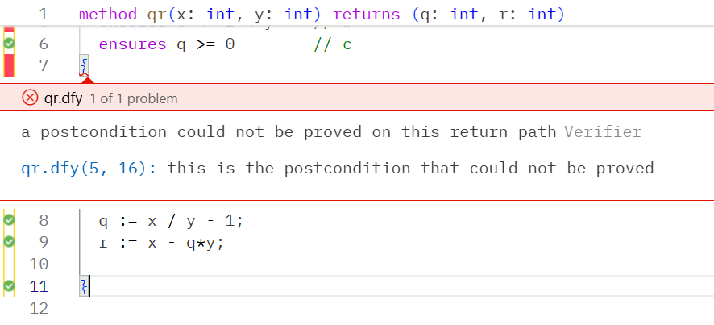

图 1 Dafny 显示某个后置条件无法证明（VSCode）Fig. 1 Dafny shows a postcondition cannot be proven (VSCode)

现在来看 `qr_loop`：Now let’s look at `qr_loop`:

```
method qr_loop(x: int, y: int) returns (q: int, r: int)
  requires x >= 0
  requires y > 0
  ensures q*y + r == x
  ensures 0 <= r < y
  ensures q >= 0
{
  q := 0;
  r := x;
  while r >= y
    invariant q*y + r == x
  {
    q := q + 1;
    r := r - y;
  }
}
```

```
while r >= y
  invariant q*y + r == x
+ invariant r >= 0
{
```

现在，代码成功编译。Now the code successfully compiles.

### 形式化验证的局限The Limits of Formal Verification

既然形式化验证能证明代码正确，为什么还要费心写测试？If formal verification can prove code correct, why bother writing tests?

因为形式化验证*很难*。非常难。它要求我们证明声明的每一个后置条件，往往还得让能力有限的工具认可。Dafny 第一个重要的成功案例是 [IronFleet 论文](https://www.andrew.cmu.edu/user/bparno/papers/ironfleet.pdf) [https://www.andrew.cmu.edu/user/bparno/papers/ironfleet.pdf]，研究人员用 Dafny 验证了两个分布式系统。他们在回顾中指出，开发并证明 5114 行代码花了 3.7 人年，大约每个工作日完成四行经过验证的代码。按照证明工作的标准，这已经算快了。Because formal verification is *hard*. Very hard. It demands we prove every single postcondition we declare, often to the satisfaction of limited tools. Dafny’s first major success story was the [IronFleet paper](https://www.andrew.cmu.edu/user/bparno/papers/ironfleet.pdf) [https://www.andrew.cmu.edu/user/bparno/papers/ironfleet.pdf], where researchers verified two distributed systems in Dafny. In their restropective, they noted that it took 3.7 person-years to develop and prove 5114 lines of code, a rate of about four lines of verified code per workday. This is considered fast by proof standards.

而且，代码被证明正确，并不意味着它*实际*正确！只有当所有假设成立，*并且*我们只依赖已经证明的性质时，它才是“正确”的。客户可能依赖 `qr` 具有合理的速度；将它换成 `qr_loop`，就会让客户大受影响。而 `max` 假设，在遍历 `l` 时，没有其他地方修改它。在多线程程序中，这个假设未必安全。And just because code is proven correct does not mean it is *actually* correct! It is only “correct” if all of our assumptions hold *and* we only depend on proven properties. A customer might depend on `qr` being reasonably fast; replacing it with `qr_loop` would ruin their day. And `max` assumes nothing else is modifying `l` as we iterate through it. In a multi-threaded program this may not be a safe assumption.

对于大多数用途，依赖非形式化证明、行内契约和性质测试更经济。只有对于高风险、后果严重的软件，例如密码学代码或底层系统代码，形式化验证才划算。即使在这类系统中，通常也只有一两个核心库需要形式化验证，其余部分并不需要这种程度的审查。因此，形式化验证语言往往支持编译到主流编程语言。Dafny 支持 Python、C#、Go 等语言。For most use cases, it is more economical to rely on informal proofs, inline contracts, and property testing. Formal verification only becomes economical for high-risk, high-severity software, like code involved in cryptography or low-level systems. And even in those systems, only one or two core libraries need formal verification, while the rest does not need that level of scrutiny. For this reason, FV languages often support compiling into mainstream programming languages. Dafny supports Python, C#, and Go, among others.

代码清单 4 编译成 Python 的 Dafny `qr`Listing 4 Dafny `qr` compiled into Python

```
class default__:
    def  __init__(self):
        pass

    @staticmethod
    def qr(x, y):
        q: int = int(0)
        r: int = int(0)
        q = _dafny.euclidian_division(x, y)
        r = (x) - ((q) * (y))
        return q, r
```

它永远不会像直接用目标语言编写的代码那样优雅、符合惯用风格，但始终可靠。It never be as elegant or as idiomatic as code written in the native language, but it will always be reliable.

即便如此，*非形式化证明*的技巧仍然广泛适用。推理函数的正确性，可以告诉我们需要测试什么、最该注意哪里，等等。而且，我们并不总需要对完整规约进行全面验证。许多语言可以通过类型系统证明某些性质，Rust 编译器还可以证明不存在内存错误。Even so, the techniques of *informal proof* are widely applicable. Reasoning through the correctness of a function shows us what we need to test, where to pay the most attention to, etc. And we don’t always need to do full verification of the total specification. Many languages can prove some properties through the type system, and Rust’s compiler can prove the absence of memory errors.

## 小结Summary

- 证明是论证某件事为真的、数学上严谨的推理。A proof is a mathematically rigorous argument that something is true.
- 如果将函数“正确”定义为前置条件能够保证后置条件，我们就可以用数学证明函数正确。If we can define function “correct” to mean preconditions guarantee postconditions, we can mathematically prove them correct.
- 编写证明时，我们可能犯错。使用形式化验证语言，编译器就能检查证明中的错误。有些形式化验证语言可以编译为其他语言。We can make mistakes in writing proofs. With formal verification languages, the compiler can check our proofs for errors. Some FV languages can be compiled into other languages.
- 形式化验证非常困难，通常只用于关键任务软件。非形式化证明仍然有助于一般性的代码推理。Formal verification is very difficult, and often only reserved for mission-critical software. Informal proof remains useful for reasoning about code in general.

形式化验证属于更广泛的*形式化方法*，我们会在后面一章回到这个主题。不过，到这里，我们已经花了很长篇幅讨论如何用逻辑改进编码，而编写代码只是职业工作的一部分。下一章将利用逻辑，帮助我们更好地理解项目需求。Formal verification is part of the broader topic of *formal methods*, which we will return to in a later chapter. For now, though, we have spent a long time on using logic to improve our coding, but writing code is only part of our professional work. In the next chapter, we will use logic to help us better understand our project requirements.

### 进一步学习Learn More

通过契约证明代码正确，始于 Tony Hoare 在 1969 年首次提出的[霍尔逻辑](https://en.wikipedia.org/wiki/Hoare_logic) [https://en.wikipedia.org/wiki/Hoare_logic]：Proving code correct via contracts starts with Tony Hoare’s [Hoare Logic](https://en.wikipedia.org/wiki/Hoare_logic) [https://en.wikipedia.org/wiki/Hoare_logic], first introduced in 1969:

```
{x in Int; x < 10}
x = x+1
{x <= 10}
```

Dafny 使用霍尔逻辑的一种扩展，叫作“分离逻辑”，它能更好地涵盖别名、内存操作和并发等语言特性。[Dafny 网站](https://dafny.org/) [https://dafny.org/]提供了更多关于高级特性的资料，以及一系列[教程和参考资料](https://dafny.org/latest/toc) [https://dafny.org/latest/toc]。Dafny uses an extension of Hoare Logic called “separation logic”, which better covers language features like aliasing, memory manipulation, and concurrency. The [Dafny website](https://dafny.org/) [https://dafny.org/] has more material on its advanced features and a collection of [tutorials and references](https://dafny.org/latest/toc) [https://dafny.org/latest/toc].

并非所有形式化验证语言都基于契约。Liquid Haskell 和 Idris 等语言的类型系统远比主流语言强大，强到足以编码函数的完整规约。过程式语言*往往*更偏爱契约，函数式语言则*往往*更偏爱类型。Not all formal verification languages are based on contracts. Languages like Liquid Haskell and Idris have type systems that are far more powerful than mainstream languages, powerful enough to encode the complete specifications of functions. Contracts *tend* to be more popular with procedural languages, and types *tend* to be more popular with functional languages.

形式化验证也经常借助*证明助手*来完成。这些工具原本用于证明数学定理，经调整后用于证明程序正确。Isabelle、Rocq 和 Agda 都已经存在很久。相对较新的 [lean](https://lean-lang.org/) [https://lean-lang.org/]，近年来人气迅速上升。你还可以通过[互动游戏](https://adam.math.hhu.de/#/) [https://adam.math.hhu.de/#/]学习 Lean，例如“自然数游戏”。Formal verification is also often done with *proof assistants*, tools meant for proving mathematical theorems, adapted to instead prove programs correct. Isabelle, Rocq, and Agda have been around for a long time. Recently, [lean](https://lean-lang.org/) [https://lean-lang.org/] is relatively new, but rapidly rising in popularity. You can also learn Lean through [interactive games](https://adam.math.hhu.de/#/) [https://adam.math.hhu.de/#/], like “The Natural Numbers Game”.

# 情形分析Case Analysis

我们用软件解决的问题中，有相当多都是根据输入组合来作出“决策”，数量之多令人惊讶：A surprising number of the problems we solve with software are about making “decisions” based on combinations of inputs:

- 应用可能根据启用的功能标志，以及用户所在的地区，决定向用户展示什么。An application might decide what to show a user based on what feature flags are set and what part of the world they are in.
- 负载均衡器可能根据服务器负载、最小／最大数量约束以及一天中的时段，决定启动还是关闭服务器。A load balancer might decide whether to spin up or wind down servers based on server load, minimum/maximum constraints, and time of day.
- 航空公司可能根据用户的机票类型、旅客等级和所用信用卡，决定是否提供某项优待。An airline might decide whether to offer a perk based on the user’s ticket type, traveller class, and credit card used.
- 某款流行文本编辑器会综合全局默认值、语言默认值、用户自定义全局设置、用户自定义语言设置、用户自定义项目设置、用户自定义项目语言设置，以及该选项接受数字还是对象，来决定每项设置的值。A popular text editor decides every setting’s value based on the global default, language default, the custom user global setting, custom user language setting, custom user project setting, custom user project language setting, and whether the option takes a number or an object.

当我们接到实现这类软件的任务时，拿到的需求不是所有可能组合的详尽清单，而是一组规则。这就会导致*需求本身*存在缺陷：规则的覆盖范围可能有遗漏……也可能存在矛盾。When we are asked to implement this kind of software, we don’t get the requirements as an exhaustive set of possible combinations, we are given a set of rules. And this leads to bugs in the *requirements themselves*, where the rules have a gap in their coverage… or a contradiction.

分析各种情形最简单的逻辑工具是*决策表*。几分钟就能学会这个概念，即使非技术团队成员也能使用，而且它广泛适用于发现代码和人类所提需求中的问题。它只适用于决策取决于有限种组合的情况，但这个范围已经足够广，值得掌握。The simplest logical tool for analyzing cases is the *decision table*. The concept can be learned in minutes, used even by nontechnical team members, and is broadly useful in finding problems in both code and human requirements. They only work if the decision depends on a finite set of combinations, but that is a large enough category to make them worth knowing.

## 决策表Decision Tables

制作决策表时，写出可能输入的每一种组合，写出每种输入对应的输出，再把它们放进一张排好序的表中。To make a decision table, write down every combination of possible inputs, write the output for each input, and then put them in a sorted table.

就这样，这就是决策表。That’s it, that’s decision tables.

事实上，我们在前面*已经用过*决策表。真值表只不过是输入和输出全为布尔值的决策表。In fact, we have *already used* decision tables earlier in the book. A truth table is just a decision table where all of the inputs and outputs are booleans.

来看一个例子。假设我们在管理一场活动的售票页面，需要提供以下折扣：Let’s see an example. Imagine we are managing an event’s ticket page, and are asked to provide these discounts:

- 前 100 名报名者享受 10% 的折扣First 100 registrations get a 10% discount
- 接下来的 100 名报名者享受 8% 的折扣Next 100 registrations get an 8% discount
- 老年人享受 5% 的折扣Seniors get a 5% discount
- 其他参加者支付全价。Otherwise, attendees pay full price.

这个表只有一个输出，即折扣；有两个输入，分别是报名序号和是否为老年人。虽然报名序号不是有限输入，但可以合并成三种情形：`0-100`、`101-200` 和 `201-`。是否为老年人则只是布尔值。因此，预计表中应有六行：第一个输入有三种取值，乘以第二个输入的两种取值。This table has one output, the discount. It has two inputs, registration number and senior status. While the registration number isn’t a finite input, we can collapse it into three cases: `0-100`, `101-200`, and `201-`. Senior status is just a boolean. We would expect our table to have six rows, three values for the first input times two for the second.

表 1 折扣（有歧义）Table 1 Discounts (Ambiguous)

[output not shown]

1. 只允许使用最高的一项折扣（此处为 10%）Only allow the one highest discount (here 10%)
2. 依次应用各项折扣（此处为 14.5%）Apply discounts in sequence (here 14.5%)
3. 将所有折扣相加，再一次性应用（此处为 15%）Add all discounts together and apply at once (here 15%)

假设在*这个*例子中，客户选择（1），只应用最大折扣。这样，如果参加者较早报名，那么是否为老年人就无关紧要。如果一个值对最终决策“无关紧要”，就可以把它所有可能的取值合并成一行，从而缩短表格。通常把这称为*任意值*，用短横线表示。Let us assume that in *this* example, the client’s choice is (1), only the maximum discount applies. In this case, if the attendee is an early registrant, it does not matter whether they are a senior or not. If a value “doesn’t matter” in the final decision, we can make the table shorter by collapsing all of the that value’s possibilities into one row. We conventionally call this an *any* value and mark it with a dash.

表 2 折扣（完整）Table 2 Discounts (complete)

| 报名序号reg# | 老年人？senior? | **折扣****discount** |
| --- | --- | --- |
| -100 | - | 10% |
| 101-200 | - | 8% |
| 201- | T | 5% |
| 201- | F | 0% |

这个表实际上只有四行，但每个任意值都涵盖 `senior?` 的两种可能取值，所以相当于两个有效行。因此，和预期一样，这个表有六个“有效”行。This table has only four real rows, but each of the any values covers two possible values for `senior?`, so counts as two effective rows. This means this table has six “effective” rows, as we expected.

这就足以定义决策表的“有效性”：有效的表既可靠又完备，无效的表则不可靠或不完备。因此，只要行数不是恰好正确，表就自动无效，从而暴露需求中的问题。This is enough to define “validity” for decision tables: a valid table is one that is both sound and complete, while an invalid table is unsound or incomplete. This means that a table without exactly the right number of rows is automatically invalid, revealing a problem with our requirements.

练习：行数恰好不等于有效Exercise: Exactness is not Validity

反过来却*不*成立：表的行数正确，也仍然可能无效。请举例说明。The converse is *not* true: a table can have the correct number of rows and still be invalid. Give an example of this.

提示：这个表会既不可靠*又*不完备。HINT: The table would be unsound *and* incomplete.

解答Solution

我特意使用*有效*，而不是*正确*。决策表可能有效却不正确，例如没有体现客户的要求。但如果无效，就*肯定*不正确。用逻辑表示，就是 `Correct => Valid`。有效性关乎结构，正确性关乎业务。I’m being careful to use *valid*, not *correct*. A decision table can be valid but incorrect— say, if it does not capture what the client asked of us. But if it is invalid then it is *definitely* incorrect. Logically, `Correct => Valid`. Validity is structural, correctness is businessal.

练习：Fizzbuzz 问题Exercise: Fizzbuzz

`fizzbuzz(x: Int)` 这个函数在 x 能被 3 整除时返回“fizz”，能被 5 整除时返回“buzz”，能*同时*被 3 和 5 整除时返回“fizzbuzz”，其他情况则原样返回该数。为 fizzbuzz 编写决策表。`fizzbuzz(x: Int)` is a function that returns “fizz” if x is divisible by 3, “buzz” if x is divisible by 5, “fizzbuzz” if divisible by *both* 3 and 5, and otherwise returns the number unchanged. Write the decision table for fizzbuzz.

解答Solution

## 另一个需求示例Another Requirements Example

说明Note

下一版本（v0.12）可能会删除这一节，除非有足够多的人表示反对This might be removed in the next version (v0.12), unless enough people complain about that

有一款带“共享屏幕”功能的视频通话软件。主持人可以设置两个选项：We have some videocall software with a “share screen” feature. The host can set two options:

1. 是否允许多人同时共享Whether more than one person can share at a time
2. 谁可以共享（主持人、参与者）Who can share (Host, Participants)

我们用决策表来建模我是否可以共享屏幕。根据这些选项，决策表有四个可能的输入：We’ll use a decision table to model whether I can share my screen or not. Based on these options, there are four possible inputs in our decision table:

1. 是否只有主持人可以共享？Can only the host share?
2. 我是否是主持人？Am I the host?
3. 是否有其他人正在共享？Is someone else sharing?
4. 是否启用了多人共享？Is multishare enabled?

这些全是布尔值。因此，表中共有 2^4 = 16 个虚拟行。开始吧：All of these are booleans. Our table then has 2^4 = 16 virtual rows total. Here we go:

|  | O | H | S | M | 输出out |
| --- | --- | --- | --- | --- | --- |
| 1 | T | T | T | - | 错误ERROR |
| 2 | T | T | F | - | T |
| 3 | T | F | - | - | F |
| 4 | F | - | T | T | T |
| 5 | F | - | T | F | F |
| 6 | F | - | F | - | T |

我把第（1）行标为“错误”，因为它应该是不可能出现的状态：“只有主持人可以共享”“我们是主持人”和“其他人正在共享”不可能同时为真。如果在生产环境中看到这种情形，就说明系统某处有缺陷。I marked row (1) as “error” because it should be an impossible state: “only the host can share”, “we are the host” and “someone else is sharing” cannot all be true at the same time. If we see this case in production, there’s a bug somewhere in our system.

将含一个任意值的行算作两个虚拟行，含两个任意值的行算作四个，就共有 16 个互不重复的行。这意味着既没有缺行所表示的需求遗漏，也没有重复行所表示的需求矛盾。Counting the rows with one any as two virtual rows, and the rows with two anys as four, we have a total of 16 unique rows. That means there’s no missing rows indicating a missing requirement, and no duplicate rows indicating a requirement contradiction.

不过，表完整并不意味着它*正确*。这个版本的表有个缺陷。你看出来了吗？But just because the table’s complete doesn’t mean it’s *correct*. This version of the table has a bug. Can you see it?

就是第（5）行。如果禁用了多人共享，而且有其他人正在共享，那么即使我是主持人，也无法共享。It’s row (5). If multishare is disabled and someone else is sharing, then I can’t share, even if I’m the host.

决策表的一个优点是，即使非技术人员也能理解，所以可以请他们参与检查需求。修正后的表如下：One nice thing about decision tables is that even nontechnical people can understand them, so you can get their involvement in checking requirements. Fixing the table:

|  | O | H | S | M | 输出out |
| --- | --- | --- | --- | --- | --- |
| 5a | F | T | T | F | T（停止其他人的共享）T (kicks other) |
| 5b | F | F | T | F | F |

练习Exercise

说到屏幕共享，我最近在一次视频通话中出了丑。我的麦克风有硬件静音开关，我已经打开了静音，于是以为无需再按软件的静音按钮。没想到摄像头*也*带麦克风，zoom 正在使用它，所以硬件静音开关根本没起作用。每个人都能清清楚楚地听见我说话。Speaking of screensharing, I recently embarrassed myself on a video call. My microphone has a hardware mute switch, which I had toggled on, and assumed I didn’t need to press the software mute button. What I didn’t realize was my webcam *also* had a microphone, zoom was using it, and my hardware mute switch was doing nothing. Everybody could hear me loud and clear.

用决策表建模“我是否已静音（m）”，列分别为“zoom 静音（z）”“硬件静音（h）”和“所用麦克风（w）”（桌面麦克风或摄像头麦克风）。Model “Am I (m)uted” as a decision table, with the columns “(z)oom mute”, “(h)ardware mute”, and “(w)hich mic” (desk or webcam).

加分题：怎样避免这种事再次发生？Bonus: how can I prevent this from happening again?

解答Solution

## 分析代码Analyzing Code

如果代码路径使用分支，但没有循环或递归，就可以用决策表表示它的高层行为。当代码的某些输入依赖外部来源时，这会很有用。[[虽然实现可能不得不将逻辑分散在整个函数中，但仍可以用决策表组织高层行为。]]If a code path uses branches and no loops or recursion, we can represent its high-level behavior as a decision table. This can be useful if the code depends on external sources for some of the inputs. [[While the implementation may have to spread its logic over the whole function, we can still use a decision table to organize the high-level behavior. ]]

例如，Python 的[文件打开函数](https://docs.python.org/3/library/functions.html#open) [https://docs.python.org/3/library/functions.html#open]会根据传入的模式字符串、字符串是否包含“+”，以及文件是否存在，表现出不同的行为。在[实现](https://github.com/python/cpython/blob/main/Modules/_io/fileio.c#L248) [https://github.com/python/cpython/blob/main/Modules/_io/fileio.c#L248]中，函数先解析模式字符串，隔了很远才检查文件是否存在。用决策表表示函数，能让高层行为更容易看清。For example, Python’s [file open function](https://docs.python.org/3/library/functions.html#open) [https://docs.python.org/3/library/functions.html#open] has different behavior depending on what mode string was passed in, whether the string includes a “+”, and whether the file exists. In the [implementation](https://github.com/python/cpython/blob/main/Modules/_io/fileio.c#L248) [https://github.com/python/cpython/blob/main/Modules/_io/fileio.c#L248], the function parses the mode string and then, much later, checks if the file exists. Representing the function as a decision table makes it easier to see the high-level behavior.

| 模式mode | 文件存在？file_exists? | **效果****effect** |
| --- | --- | --- |
| r | T | 打开文件open |
| r | F | **错误****error** |
| w | T | 截断文件truncates file |
| w | F | 创建文件creates file |
| a | T | 追加到文件appends to file |
| a | F | 创建文件creates file |
| x | T | **错误****error** |
| x | F | 创建文件creates file |
| `''` | - | 与 r 相同same as r |

## 技巧Techniques

### 分离彼此独立的输出Separate Independent Outputs

在 Python 的 `open` 函数的模式字符串中，可以用 `"r+"` 代替 `"r"`。把 `+?` 作为输入加入表中，会使有效行从十行增至二十行。但这不会带来任何好处，因为 `+` 不改变对文件的任何操作效果。In Python’s `open` function’s mode string, we can write `"r+"` instead of `"r"`. Adding `+?` as an input to the table would bring it from ten effective rows to twenty. It would also not benefit us in any way, because the `+` does not change any of the file effects.

用 `"r+"` 代替 `"r"`，改变的其实是文件句柄的读写权限。不过，文件是否已经存在不会改变这些权限，除非这会导致错误（例如对已存在的文件使用 `"x+"`）。Writing `"r+"` instead of `"r"` instead changes the file handle’s read/write permissions. But those permissions do not change if the file already exists or not, unless that would be the source of an error (like `"x+"` on an existing file).

如果面对一张二十行、六列的大表，这些独立性可能并不明显。我们可以改用两个更小的表，每个表只包含与该决策相关的输入。These independences may not be obvious to someone looking at a giant twenty-row, six-column table. We can instead present them with two smaller tables that only contain the inputs relevant to each decision.

| +? | 键key | **可读****can_read** | **可写****can_write** |
| --- | --- | --- | --- |
| T | r | T | T |
| T | w | T | T |
| T | a | T | T |
| T | x | T | T |
| T | `''` | **错误****error** | / |
| F | r | T | F |
| F | w | F | T |
| F | a | F | T |
| F | x | F | T |
| F | `''` | T | F |

这里需要在表格的简洁性与全面性之间作取舍。如果表格必须追踪所有错误情形，那么就需要全部三个输入。There are trade offs here in how concise vs comprehensive we want the tables to be. If it is important for the table to keep track of all error cases, then we need all three inputs.

### 表示状态修改Representing Mutations

决策表不太适合表示大量状态变化，或某个值被多次修改的情况，但有时展示单个值如何变化仍然很有用。Decision tables aren’t the best tool for representing a whole lot of state changes, or something getting changed multiple times, but sometimes it’s useful to show how a single value changes.

```
# example code
if x % 2 == 0
  x = x/2;
else
  x = 3*x+1;
```

前面一章用旧值 old(x)表示变化。这次，我们借用一种更紧凑的数学记号。在数学和科学的某些分支中，`x'` 表示 x 经过某种变化后的*新*值。这里可以得到下表In a previous chapter we represented changes with old(x). In this case, we are going to borrow a mathematical notation that is a little more compact. In some branches of math and science, they write `x'` to mean the *new* value of x after some change. Here, that would give us the table

| x % 2 | `x'` |
| --- | --- |
| 0 | x/2 |
| 1 | 3x+1 |

理想情况下，表应该建模*单个*步骤。这意味着可以在同一张表中更新多个值，例如交换函数：Ideally, the table should model a *single* step. This means that we can update multiple values in the same table, as in a swap function:

| `x'` | `y'` |
| --- | --- |
| y | x |

可以用 `x''` 表示再*下一步*的值，但如果需要这样做，决策表很可能就不是合适的工具。We could represent the values in the step *after* with `x''`, but if we are doing that then decision tables are probably the wrong tool for the job.

### 不可能出现的行Impossible Rows

如果想表示的不只是某个输出不可能出现，而是某种*输入*组合不可能出现，可以用 `/` 来表示“不可能”，而不只是“无关紧要”。If we want to demonstrate not just that an output is impossible, but that a particular combination of *inputs* is impossible, we can use a `/` to say not just “it doesn’t matter”, but “it’s not possible”.

| 密码正确？password-correct? | 2重认证已启用？2auth-enabled? | 2重认证正确？2auth-correct? | 登录Login |
| --- | --- | --- | --- |
| T | T | T | T |
| T | T | F | F |
| T | F | / | T |
| F | - | / | F |

逻辑上，这与短横线／任意值的写法相同，但它向读者表明的是不应发生，而不是无关紧要。Logically, this is the same as writing a dash/any, but it signals to the reader that it shouldn’t happen, not that it doesn’t matter.

### 有效性陷阱Validity Footguns

误用任意值，是最容易在无意中让表变得不可靠的方式。好在这也相对容易发现。The easiest way to accidentally make a table unsound is through misuse of anys. Fortunately, this is also relatively easy to detect.

表 4 不可靠的表Table 4 Unsound Table

| A | B | **o** |
| --- | --- | --- |
| T | - | T |
| - | T | F |

展开任意值后，会同时出现 `TT -> T` 和 `TT -> F`，因此不可靠。这里能发现问题，是因为表不完备：没有 FF 对应的行。如果把它作为特殊情况补上，有效行总数就会变成 5，这应该提醒我们表不可靠。If we expand the anys, we have both `TT -> T` and `TT -> F`, which is unsound. Here we can detect the issue because the table isn’t complete, as we don’t have a row for FF. If we add that as a special case, then we’ll have 5 effective rows total, which should alert us that the table is unsound.

避免这个问题的简单方法是，绝不把任意值放在固定值左边。这可能让表格有些膨胀，但总比表无效好！One easy way to avoid this is to never place an any to the left of a fixed value. This can lead to some table bloat but is better than having an invalid table!

另一个常见错误是，没有穷尽某一列的所有取值。Another common mistake is to not exhaustively enumerate all values in a column.

| 计数count | **o** |
| --- | --- |
| -10 | T |
| 11-20 | F |
| 21-30 | T |

如果确定 `count` 最大只能到 30，那么这个表就是完备的。如果还能更大，就没有覆盖所有可能情况，因此表不完备。If we know for sure `count` maxes out at 30 then this table is complete. If it can go higher, we have not covered all possibilities, so the table is incomplete.

## 什么时候不该选择表格？When is a Table the Wrong Choice?

考虑使用决策表时，我会问自己四个问题：Four questions I ask myself when considering a decision table:

1. 要建模的事物，其独立输入与输出之间是否有明确的映射？Am I modeling something with a clear map between independent inputs and outputs?
2. 能否用合理的方式，清晰简洁地列出所有输入？Can I cleanly and concisely enumerate the inputs in a sensible way?
3. 表格是否是呈现这些信息最有用的方式？Would a table be the most useful way of presenting this information?
4. 表格是否易读？Would the table be legible?

如果输入之间高度依赖、决策涉及大量副作用，或不能“瞬间”作出决策，那么问题（1）的答案就是“否”。如果决策需要循环或递归，表格很可能不够用。Question (1) is “no” if the inputs strongly depend on each other, if the decision involves lots of side effects, or if the decision cannot be made “instantly”. If the decision requires a loop or recursion, tables are likely insufficient.

如果某个输入有无限多种取值，却无法分组，或者某个输入是列表等复杂类型，那么问题（2）的答案就是“否”。Question (2) is a “no” if some input has an infinitely-many values and there is no way of grouping them, or if one of the inputs is a list or other complex type.

如果决策可以用更简单的等式表示，那么问题（3）的答案就是“否”。存在覆盖关系时就可能如此，例如根据代码默认值、用户选项和参数标志配置命令行工具。可以写一个每列有三种可能值的表，用全部 27 行展示最终配置。但直接说“标志始终覆盖用户选项，用户选项覆盖用户默认值”，可能更清楚。Question (3) is a “no” if the decision can be represented by a simpler equation. This can happen with overrides, like if a CLI is configured based on code defaults, user options, and parameter flags. We could write a table where each column has three possibilities, and show the final configuration setting for all 27 rows. But it could be clearer to instead say “flags always override user options override user defaults”.

如果表太大，问题（4）的答案就是“否”。多大才算“太大”，取决于许多因素，但一个很粗略的经验是：整张表应该能放进一张纸或一个显示器屏幕。如果某列有八种可能取值，或者决策取决于十六列输入，表就会难以阅读。Question (4) is a “no” if the table is too big. How big is “too big” depends on a lot of factors but a very rough rule of thumb is that the table should all fit on one sheet of paper or monitor screen. If one column has eight possible values, or if the decision depends on sixteen input columns, then the table will be illegible.

## 小结Summary

- 真值表列出逻辑表达式的每种可能输入和输出。Truth tables enumerate every possible input and output of a logical expression.
- 决策表通过允许多个输入和输出，将真值表扩展到系统。Decision tables extend truth tables to systems, by allowing multiple inputs and outputs.
- 没有遗漏输入的决策表是*完备的*；不会让同一组输入出现两次的决策表是*可靠的*。Decision tables are *complete* if they have no missing inputs, and *sound* if they don’t have the same set of inputs twice.

下一章将探讨如何运用逻辑，更好地理解数据库。In the next chapter, we will look at how logic can be used to better understand databases.

### 进一步学习Learn More

决策表是*形式化规约*的一个例子。前面几章已经写过许多“形式化规约”。这个术语的重要之处，只在于“能够检查有效性、并进行变换的规约”。后面的章节将更详细地介绍形式化规约。Decision tables are an example of a *formal specification*. We have already written plenty “formal specifications” in previous chapters. What makes the term matter is just “a specification we can check for validity and manipulate.” We will cover formal specification in more detail in later chapters.

[[与决策表属于同一宽泛类别的其他工具，包括流程图、故障树和状态机图。]][[Other tools in the same very general category of decision tables include flowcharts, fault trees, and state machine diagrams.]]

[[待办：补充一些关于组合数学和 Parnas 表的内容]][[TODO Something about combinatorics and Parnas tables]]

# 数据库Databases

到目前为止，我们只用逻辑来理解“运行中的软件”：算法及其执行方式。但逻辑也是理解数据库的极其强大的工具。为简单起见，我们只讨论由 SQL 驱动的关系数据库。不过，其中许多概念也可以用于 CSV、数据框、文档数据库等。So far, we have only applied logic to understand “software in motion”: algorithms and how they execute. But it is also an extraordinarily powerful tool for understanding databases, too. For simplicity we will restrict our attention to only SQL-driven relational databases. However, many of these concepts are adaptable with CSVs, dataframes, document databases, etc.

## 关系模型概述A Relational Model Overview

现代关系数据库以 Edgar F. Codd 的*关系模型*为基础。我们不会全面详述这个模型，而只概述所需的内容。若想深入了解，请参阅延伸阅读。Modern relational databases are based on Edgar F. Codd’s *relational model*. We will not go into comprehensive detail on the model but provide an overview we need. See the Further Reading for a deeper dive.

数据库是表的集合，而表是记录的集合。什么是记录？我们可以先说，记录是一个有序的值列表，也就是*元组*。例如，一个数据库可以是A database is a set of tables, and a table is a set of records. What is a record? We can start by saying that a record is an ordered list of values, or *tuples*. One example database could be

```
db = {users, groups, user_groups}

users = {
  (1, "h@hillelwayne.com"),
  (2, "kate@example.com"),
  (3, "asher@example.com"),
  # etc
}

# etc
```

对于给定的记录 `u`，我们可以用 `u[0]` 取得第一个元素，用 `u[1]` 取得第二个元素，依此类推。这充分满足了我们对不便和难以理解的双重需求。最好给这些元素加上名称和类型，这样就能写 `u.id`，而不是 `u[0]`。而且，既然我们随时都可以创造新记法，我就加上一种简单的记录语法：For a given record `u`, we can get the first element with `u[0]`, the second with `u[1]`, etc. This satisfies our needs for both inconvenience and incomprehensibility. It would be better to give the elements names and types, so we could write `u.id` instead of `u[0]`. And, as we can create new notation whenever we want, I will add a simple record syntax:

```
record users {
  id: Int
  email: String | {NULL}
}
```

回想一下，`|` 表示集合的并。我们规定，这表示集合 `users` 的每个元素都有两个字段：一个名为 `id`，必须是整数；另一个名为 `email`，可以是字符串或 null。你可能会注意到，这与我们在 SQL 中定义表的方式非常相似：Recall that `|` is set union. We will define this to mean that each element of the set `users` has two fields, one called `id` that must be an integer and one called `email` that may be a string or null. You may note this is very similar to how we would define a table in SQL:

```sql
CREATE TABLE users (
    id int NOT NULL,
    email varchar(9999)
  )
```

这是有意为之！我们可以选择与所构建的软件系统紧密对应的逻辑记法。同时，我选择显式标明可空字段，而 SQL 默认字段可空。我发现这样能减少错误。This is intentional! We can choose our logical notation to closely match the software systems we build. At the same time, I chose to make nullable fields explicit, where SQL makes them the default. I find that leads to fewer mistakes.

不过，我觉得写 `set | {NULL}` 有点笨重，所以会添加一点语法糖，规定 `set + x` 表示 `set | {x}`，这样就可以写成 `email: String + NULL`。That said, I find writing `set | {NULL}` a little unwieldy, so I will add a bit of syntactic sugar and define `set + x` to mean `set | {x}`, so that we can write `email: String + NULL`.

无论如何，因为表就是集合，我们可以像对其他集合一样对它们进行量化。而这正是逻辑模型大显身手的地方。我们的两个量词对应数据库的两个基本用途：查询数据和确保数据完整性。In any case, because tables are just sets, we can quantify over them like any other sets. And this is where the logical model really shines. Our two quantifiers represent the two essential purposes of a database: querying data and ensuring data integrity.

## 查询数据Querying Data

给定如下查询Given the query

```sql
SELECT u.email FROM users as u WHERE u.id = 5
```

这个查询的结果可以表示为集合筛选 `{(u.email) for u in users: u.id == 5}`。如果转而把查询当作 `some` 表达式来研究其性质，将有助于我们后面的讨论。因此，我们可以改问：“这个查询究竟有没有返回任何结果？”这个问题对应表达式 `some u in users: u.id == 5`。如果需要多个 `WHERE` 子句，只需给逻辑表达式添加更多子句：The results of this query can be represented as the set filter `{(u.email) for u in users: u.id == 5}`. It will help us down the road if we can instead explore the properties of queries as if they were `some` expressions. So we can instead ask “does the query return any results at all”? That question corresponds to the expression `some u in users: u.id == 5`. If we wanted multiple `WHERE` clauses, we could just add more clauses to the logical expression:

```sql
SELECT * FROM users as u WHERE
   u.id = 5 AND (u.email = "" OR u.email IS NULL)

-- some u in users:
--   1. u.id == 5
--   2. (u.email == "" or u.email == null)
```

嵌套子查询和公用表表达式不过是嵌套量词。如果我想查询编号为五的用户是否属于*任何*群组，就可以写Nested subqueries and common table expressions are just nested quantifiers. If I want to query if user five belongs to *any* groups, I could write

```sql
SELECT * FROM users AS u WHERE
  u.id in (SELECT ug.user_ids FROM user_groups AS ug)

-- some u in users:
--   some ug in user_groups:
--     u.id == g.user_id
```

用逻辑表示查询，究竟能带来什么？首先，这意味着我们可以用谓词来抽象复杂的 SQL 表达式。两个用户在什么情况下属于同一个群组？当每个用户都拥有同一群组的成员记录时。用谓词表达很容易：What does logical representation of queries actually get us? For one, it means we can abstract complicated SQL expressions with predicates. When do two users belong to the same group? When each user has a group membership for the same group. As a predicate, this is easy:

```
Member(user: users, group: groups) =
  some ug in user_groups:
    1. ug.user_id  == user.id
    2. ug.group_id == group.id

Connected(u1, u2: users) =
  some g in groups:
    1. Member(u1, g)
    2. Member(u2, g)
```

在此基础上，我们就能组合谓词，构造更复杂的查询。*但 SQL 数据库做不到这一点*。标准 SQL 不支持在查询中直接使用用户定义的谓词。作为退而求其次的办法，我们可以生成所有满足某个谓词的值所组成的集合，然后在其他查询中使用这个集合。数据库中称之为*视图*。And from there we can compose our predicates to make more complex queries. *But SQL databases cannot do this*. Standard SQL does not support directly using user-defined predicates in queries. As a consolation prize, we can instead generate the set of all values that pass a predicate and then use that set in other queries. The database term for this is a *view*.

```sql
CREATE VIEW memberships AS
  SELECT u.email, g.name FROM users AS u, groups AS g
  WHERE (
    SELECT COUNT(*) FROM user_groups AS ug
    WHERE ug.user_id = u.id AND ug.group_id = g.id
  );

-- memberships =
--   {(u.id, g.id) for u in user, g in groups: Member(u, g)}
```

当然，真正的 SQL 用户都不会这样编写 `memberships`。他们会使用联接！Of course that’s not how any actual SQL user would write `memberships`. They would use a join!

### SQL 联接SQL Joins

SQL 联接把两个表中的信息连接起来，例如：A SQL join connects the information in two tables, for example:

```sql
-- users without an email in groups

SELECT * FROM users as u
         INNER JOIN user_groups as gu
         ON gu.user_id = u.id
         WHERE u.email IS NULL
```

大多数 SQL 教程都用集合的并与交来“解释”联接，常常配上这样的图：Most SQL tutorials “explain” joins in terms of set unions and intersection, often with diagrams like this:

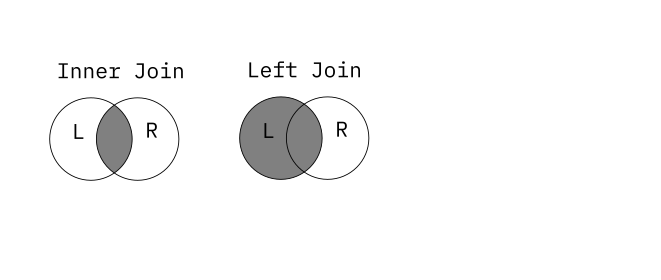

图 2 一种错误的联接解释Fig. 2 A BAD explanation of joins

但这根本说不通。`users` 和 `user_groups` 是不相交的集合，所以交集应该是空集！But this makes no sense. `users` and `user_groups` are disjoint sets, so the intersection should be empty!

要*正确*表示内联接，我们需要引入一个小小的新集合运算。两个集合 `S` 和 `T` 的*笛卡尔积*是所有满足以下条件的元组组成的集合：元组的第一个元素属于 `S`，第二个元素属于 `T`。我们可以通过集合映射形式化地定义它：To *properly* represent an inner join, we need to introduce one small new set operation. The *Cartesian product* of two sets `S` and `T` is the set of all tuples where the first element of the tuple is in `S` and the second element is in `T`. We can formally define this via the set map:

```
S x T = {(s, t) for S in S, t in T}
S x T x U = {(s, t, u) for S in S, t in T, u in U}
# etc
```

例如，`Nat x Alphabet` 的笛卡尔积是包含 `(0, a)`、`(0, b)`、`(1, a)` 等元素的集合。这个运算以率先使用它的 René Descartes 命名，而之所以称为“积”，是因为 `#(S x T) == #S * #T`（其中 `#S` 是 S 中的元素个数）。For example, the Cartesian product of `Nat x Alphabet` is the set containing `(0, a)`, `(0, b)`, `(1, a)`, etc. The operator is named after René Descartes, who pioneered its use, and is called a “product” because `#(S x T) == #S * #T` (where `#S` is the number of elements in S).

练习：笛卡尔积的基数Exercise: Cartesian Cardinalities

证明：如果 S 和 T 是有限集，那么 `#(S x T) == #S * #T`。Show that, if S and T are finite sets, then `#(S x T) == #S * #T`.

提示：从几何角度思考。HINT: Think geometrically.

解答Solution

借助笛卡尔积，我们可以这样表示内联接：With the Cartesian product, we can represent the inner join like this:

```
some (u, gu) in users x user_groups:
  1. u.id == gu.user_id
  2. u.email == NULL
```

在逻辑表示中，`WHERE` 和 `ON` 子句没有区别，就像在 SQL 中一样：多数方言都允许你把联接条件放在 `WHERE` 中，或把筛选条件放在 `ON` 中。如果想对三个表进行内联接，语法完全相同：There is no difference between the `WHERE` and `ON` clauses in the logical representation, just as there is no difference in SQL: most dialects will happily let you put a join condition in the `WHERE` or a filter in the `ON`. If we want to inner join across three tables, the syntax is exactly the same:

```
some (u, gu, g) in users x user_groups x groups:
  1. u.id == gu.user_id
  2. gu.group_id = gu.id
```

外联接对于初学者来说更难学，这可能与外联接在逻辑上也更难表示有关。对 S 和 T 进行左外联接，会返回内联接的全部行，还会返回 S 中无法与 T 中*任何*行联接的那些行。这等同于如下查询：Outer joins are more difficult for beginners to learn, which may be related to the fact that outer joins are also more complex to represent logically. A left outer join on S and T returns all the same rows as an inner join, but also the rows of S that don’t join with *any* rows on T. This is the same as this query:

```
|| some (u, gu) in users x user_groups:
    u.id == gu.user_id

|| some (u, null) in users x {NULL}:
    all gu in user_groups:
      u.id != gu.user_id
```

右外联接的定义与此类似。A right outer join is defined analogously.

注Note

那么，像 `GROUP BY` 这样的聚合函数呢？我们的逻辑到这里就有点力不从心了。聚合从来都不是关系模型的一部分，它更像是查询的“后处理”步骤。我还没有找到好的形式化模型，不过我个人把它们看作“划分函数”。What about aggregate functions, like `GROUP BY`? This is where our logic breaks down a little. Aggregates were never part of the relational model and act more like “postprocessing” steps on the query. I have not found any good formal models but personally think of them as “partition functions”.

```
# given
SELECT g, h, aggrfunc(t) FROM Table AS t WHERE P
GROUP BY t.g, t.h

# we could write
partition_set = {(t.g, t.h) for t in Table}
rows_for(g, h) =
  {t for t in Table: t.g == g && t.h == h && P(t)}
{(g, h, aggrfunc(rows_for(g, h))) for (g, h) in partition_set}
```

这有点混乱，但只要有耐心，还是可以处理的。请不要问我窗口函数的问题。It’s kind of a mess but it can be worked with given patience. Please do not ask me about window functions.

## 数据库约束Database Constraints

从数据库中取出数据只完成了挑战的一半。另一半是把数据*放进*数据库，更重要的是保持其正确性。我们不希望记录缺少值或外键，也不希望出现重复的 id，或不满足任何应用特定的要求，例如“用户余额必须大于零”或“同时处于 `active` 状态的记录不能超过十条”。Getting data out of a database is only half of the challenge. The other half is getting data *into* the database, and more importantly keeping it correct. We don’t want records to be missing values or foreign keys, or have duplicate ids, or miss any of the application specific requirements like “user balances must be above zero” or “no more than ten records can be `active` at once.”

我们可以先看看数据库表示约束的一些方式：We can start by looking at some ways databases represent constraints:

```sql
CREATE TABLE users (
  id INTEGER
  balance integer,
  email TEXT,
  -- ...
  CHECK (balance > 0),
  UNIQUE (email)
);

CREATE TABLE user_groups (
  user_id INTEGER,
  -- ...
  FOREIGN KEY(user_id) REFERENCES users(id)
);
```

这两个表定义了三个约束，每个都有自己专用的语法。一个约束作用于表中的每条记录，一个作用于表中的每*一对*记录，还有一个作用于表之间的记录。这三个约束都能直接表示为逻辑表达式。先看“用户余额必须大于零”：These two tables define three constraints, each with its own special syntax. One applies to each record in a table, one to every *pair* of records in the table, and one to records between tables. All three constraints can be directly represented with logical expressions. Starting with “user balances must be above zero”:

```
constraint UserPositiveBalances = all u in users:
  u.balance > 0
```

我在前面加上 `constraint`，因为这有助于区分表示实际系统约束的谓词和辅助谓词。所有形如 `all x in set: P(x)` 的逻辑约束，也就是针对单个表行的约束，都可以通过 `CHECK` 实现。`UNIQUE` 是一个标准的唯一性谓词（使用 disj）：I put `constraint` in front because it helps me distinguish predicates that represent actual system constraints from helper predicates. All logical constraints that of the form `all x in set: P(x)`— that is, constraints over a single table row— can be implemented via `CHECK`. `UNIQUE` is a standard uniqueness predicate (using disj):

```
constraint UserEmailUnique =
  all disj u1, u2 in Users:
    u1.email != u2.email
```

最后一个约束是外键约束，它表示每条 `user_group` 记录都有一条对应的 `user` 记录。换一种理解方式：如果 `user_group.user_id == 17`，就*必须存在*一个 id 为 17 的用户，也就是说，*查询* `some u in users: u.id == 17` 为真。换言之，外键对每条记录施加约束，以保证某个查询为真！因此，我们可以用嵌套量词来表示键约束，即在 `all` 内放入一个 `some`。The last constraint, a foreign key constraint, says that every `user_group` record has a corresponding `user` record. Another way of thinking about this that if `user_group.user_id == 17`, there *must exist* a user with id 17, which means the *query* `some u in users: u.id == 17` is true. In other words, foreign keys constrain each record to guarantee a query! For this reason we can represent key constraints with a nested quantifier, placing a `some` inside an `all`.

```
constraint UserGroupUserFK =
  all ug in user_groups:
    some u in users:
      ug.user_id = u.id

# Or, to make things simpler:

FK(from_tbl, to_tbl, col, to_col)
  all record in from_tbl:
    some ref in to_tbl:
      record.[col] = ref.[to_col]

constraint UserGroupUserFK =
  FK(user_groups, users, user_id, id)
```

注Note

这引出了一个问题：如果 `all-some` 这种嵌套量词在数据库中有深刻的含义，那么 `some-all` 是否也有什么含义？我不知道。欢迎读者提出建议。This raises a question: if `all-some` nested quantifiers have a deep meaning in databases, does `some-all` mean anything? I have no idea. I welcome suggestions from readers.

练习：复合键Exercise: Compound keys

SQL 的 UNIQUE 约束可以涉及多列。如果在 `user_groups` 上添加 `UNIQUE (user_id, group_id)`，就表示不同的 `user_group` 记录可以拥有相同的用户 id，或者相同的群组 id，但不能两者同时相同。请将其写成一个约束。SQL UNIQUE constraints can refer to multiple columns. If I add `UNIQUE (user_id, group_id)` to `user_groups`, this means that different `user_group` records can share the same user id or the same group id, but not both at the same time. Write this as a constraint.

解答Solution

练习Exercise

写出约束：“如果用户属于某个群组，那么该用户必须有一个非 null 的电子邮件地址。”Write the constraint “If a user belongs to a group, the user must have a non-null email”.

提示：使用 `=>`。HINT: use `=>`.

解答Solution

练习Exercise

令 `#S` 表示 `S` 中的元素个数。写出约束：“所有群组都至多只能有五个成员。”Let `#S` be the number of elements in `S`. Write the constraint “all groups can only have five members at most.”

提示：使用集合筛选。HINT: Use set filter.

解答Solution

## 约束就是查询Constraints Are Queries

谓词逻辑可以表达大量有意义的约束。前面介绍的每种机制都只能实现其中一个狭窄的子类：Predicate logic can express an enormous number of interesting constraints. Each of the mechanisms earlier can only implement a narrow subclass:

- `REFERENCES` 只能实现 `all s in S: (some t in T: s.col1 = t.col2)`。`REFERENCES` only implements `all s in S: (some t in T: s.col1 = t.col2)`.
- `UNIQUE` 只能实现 `all x, y in S: (x.col1 != y.col1) || (x.col2 != y.col2) ...``UNIQUE` only implements `all x, y in S: (x.col1 != y.col1) || (x.col2 != y.col2) ...`
- `CHECK` 只能实现 `all x in S: P(x)`，**其中 P 不使用任何量词**。换句话说，CHECK 无法根据其他行来约束某一行。`CHECK` only implements `all x in S: P(x)`, **where P does not use any quantifiers**. In other words, CHECK cannot constrain a row based on other rows.

那么，“所有书籍的作者都出生于出版日期之前”这样的要求，该如何实现呢？用逻辑很容易表达：How would we implement something like “all books have an author born before the publication date”? It is easy to express logically:

```
constraint NoTimeTravel =
  all b in books:
    some a in authors:
      1. b.author_id = a.id
      2. b.published_on > a.birthday
```

实现 `NoTimeTravel` 就是另一回事了。用 `REFERENCES` 不行（因为它有两个条件），用 `CHECK` 也不行（因为它使用了第二个量词），用 `UNIQUE` 更不行（原因很明显）。那么，数据库能强制实施这个约束吗？还是说我们只能在应用端进行验证？Implementing `NoTimeTravel` is another matter. It cannot be done with `REFERENCES` (as it has two conditions), nor with `CHECK` (as it uses a second quantifier), nor with `UNIQUE` (obvious). So can our databases enforce this, or are we limited to application-side validation?

事实证明，大多数 SQL 数据库确实能强制实施这个约束！我们只需花一点功夫，运用一些逻辑规则就能做到。首先，可以把 `NoTimeTravel` 拆分为一个“简单”约束和一个“困难”约束：It turns out most SQL databases, can, in fact, enforce this constraint! We just have to put in a little work and apply some logical rules to get there. First, we can split `NoTimeTravel` into an “easy” constraint and a “hard” constraint:

```
# Just a foreign key
constraint BooksAuthorsFK =
  all b in books:
    some a in authors:
      b.author_id = a.id

constraint NoTimeTravel =
  all b in books:
    all a in authors:
      b.author_id != a.id ||
        b.published_on > a.birthday
```

我们把 `NoTimeTravel` 中的 `some` 改成了 `all`，还把主体改成了“要么作者不同，要么书籍出版于作者出生之后”。虽然也可以使用 `=>`，但 SQL 没有蕴含运算符，所以写成 `!P || Q` 更贴近最终的实现。再结合 `BooksAuthorsFK` 强制每本书恰好有一位作者，这就与原来的约束等价。下一步并非严格必需，但能让最终结果更清楚：We turned the `some` in `NoTimeTravel` into an `all`. We also changed the body to be “either the author is different or the book was published after the author was born”. While we could have used a `=>` instead, SQL does not have an implication operator, so writing `!P || Q` keeps us closer to the eventual implementation. This, combined with `BooksAuthorsFK` forcing each book to have exactly one author, is equivalent to our original constraint. Our next step is not strictly necessary, but will clarify our final outcome:

```
constraint NoTimeTravel =
  all (b, a) in books x authors:
      b.author_id != a.id ||
        b.published_on > a.birthday
```

现在来看关键洞见。如果这个约束不成立，就必定存在某个违反它的具体反例 `(book, author)`。而我们可以编写一个查询来找出这个反例！如果查询没有结果，就知道不存在反例，也就意味着约束成立。这不过是逻辑对偶性的又一个例子！Now for the insight. If this constraint does not hold, there must be a specific `(book, author)` counterexample that violates it. And we can write a query to find the counterexample! If the query turns up nothing we know there are no counterexamples, meaning the constraint holds. This is just another example of logical duality!

```
constraint NoTimeTravel =
  !some (b, a) in books x authors:
      !(b.author_id != a.id ||
        b.published_on > a.birthday)

# Apply De Morgan's Law
constraint NoTimeTravel =
  !some (b, a) in books x authors:
      1. b.author_id = a.id
      2. b.published_on <= a.birthday
```

这可以直接对应到一个 SQL 查询：This directly maps to a SQL query:

```sql
-- NoTimeTravel holds if this finds 0 rows

SELECT COUNT(*) FROM books as b
   INNER JOIN authors as a
   ON b.author_id = a.id
   AND b.published_on <= a.birthday;
```

要真正强制实施这个约束，可以使用 SQL“触发器”，即设置为在行或表发生变更时运行的存储过程。我们只需声明一个触发器，执行这个查询，并在查询结果非空时抛出异常。为简洁起见，示例另附于[代码示例](https://github.com/logicforprogrammers/book-assets) [https://github.com/logicforprogrammers/book-assets]中。To actually enforce the constraint, we can use a SQL “trigger”, or a stored procedure set to run on row or table changes. All we need to do is declare a trigger trigger that makes this query and raises an exception if the query is nonempty. For brevity, an example is separately provided with the [code samples](https://github.com/logicforprogrammers/book-assets) [https://github.com/logicforprogrammers/book-assets].

### 状态变更约束State Change Constraints

SQL 触发器还有一个有用的特性：由记录更新触发时，它们可以检查有关记录如何变更的约束。例如，我们可以强制 `updated_at` 时间戳只能向未来推进，或者当一个可空字段具有非 NULL 值后，就不能再设回 NULL。SQL triggers have one other useful feature: when triggered by a record update, they can check constraints on how the record changed. We can for example enforce that an `updated_at` timestamp can only go forwards in time or that when a nullable field has a non-NULL value, it cannot be set back to NULL.

在前面的章节里，我们已经表示过变更：在变更断言中，我们使用了 `old(x)` 和 `x`；而在 决策表中，我们使用了 `x` 和 `x'`（读作“x 撇”）。SQL 语法使用 `NEW` 和 `OLD`，但为了让后面的一章更容易理解，我现在就使用带撇号的语法。We have already represented changes in previous chapters: in change assertions we used `old(x)` and `x`, while in decision tables we used `x` and `x'` (“x prime”). SQL syntax uses `NEW` and `OLD`, but to make a later chapter easier I will use the prime syntax right now.

```
constraint NoNullAfterAdmin =
  all g in Groups:
    g.admin_id != NULL => g.admin_id' != NULL
```

一旦 admin_id 不为 null，它的下一个值也不能是 null，这意味着它再也不能变回 null。Once the admin_id is not null, the next value cannot be null either, meaning that it can never go back to null.

这也适用于状态机列：一条记录可以经历 `WAITING -> READY` 或 `READY -> DONE`，但不能经历 `WAITING -> DONE`。这种情况下，通常应该“允许 x 变成它自身”：This is also useful for state machine columns: a record can go `WAITING -> READY` or `READY -> DONE`, but not `WAITING -> DONE`. In that case it’s considered good form to “allow x to change to itself”:

```
constraint StateMachineTransitions ==
  all t in tasks:
    1. t.status = "WAITING" => t.status' in {"WAITING", "READY"}
    2. t.status = "READY => t.status' in {"READY", "DONE"}
```

练习：转移辅助谓词Exercise: Transition Helper

编写一个辅助谓词 `ValidTransitions(task, from, to)`，使我们能够这样写出 `StateMachineTransitions` 的主体：Write a helper predicate `ValidTransitions(task, from, to)`, so that we can write the body of `StateMachineTransitions` this way:

```
all t in tasks:
  1. ValidTransitions(task, "WAITING", {"READY"})
  2. ValidTransitions(task, "READY", {"DONE"})
```

注意，`to` 将是一个转移的集合。Note that `to` is going to be a set of transitions.

解答Solution

## 小结Summary

1. 数据库是表的集合，而表是记录的集合。Databases are sets of tables, which are sets of records.
2. `some` 量词对应数据库查询。联接是对两个或更多表的*笛卡尔积*进行的查询。对于 SQL，大多数 `some` 表达式都能直接翻译为查询，不过可能需要把抽象谓词内联展开。The `some` quantifiers corresponds to database queries. Joins are queries over the *Cartesian product* of two or more tables. In the case of SQL, most `some` expressions are directly translatable to queries, though you may need to inline abstract predicates.
3. `all` 表达式对应数据库约束，`all-some` 嵌套表达式对应外键。数据库有不同的功能来强制实施约束。约束既可以针对数据，也可以针对数据的变更方式。`all` expressions correspond to database constraints, and `all-some` nested expressions correspond to foreign keys. Databases have different features for enforcing constraints. Constraints may be on data, or how data changes.
4. 利用对偶性，我们可以通过查询约束的否定来检查约束。SQL 数据库可以借此通过触发器强制实施复杂约束。By using duality, we can check a constraint by querying its negation. SQL databases can use this to enforce complex constraints, via triggers.

到目前为止，我们的逻辑始终紧贴数据库：我们讨论的是数据库表和记录的性质。[[但数据库只是数据模型的一种不完美实现，而数据模型是我们试图使之清晰可理解的那部分世界的概念化表示。]] 下一章，我们将上升一个抽象层次，用逻辑研究数据模型。So far we’ve been keeping the logic very close to the database: we’re talking about properties of database tables and records. [[But the database is just an imperfect implementation of the data model, the conceptual slice of the world we’re trying to make legible.]] Next chapter we will use logic to study our data model, one level of abstraction higher.

### 延伸阅读Further Reading

本章的数据库表示法来自 Edgar Codd 的*关系模型*。关系模型最早在[《大型共享数据库的数据关系模型》](https://dl.acm.org/doi/10.1145/362384.362685) [https://dl.acm.org/doi/10.1145/362384.362685]中提出，同文还提出了一组构成*关系代数*的运算符。[这里](https://cs186berkeley.net/notes/note6/) [https://cs186berkeley.net/notes/note6/]有一篇更平易近人的关系代数介绍。SQL 以关系代数为基础，但并未完全遵循它。The database representation in this chapter comes from Edgar Codd’s *Relational Model*. The relational model was first introduced in [A relational model of data for large shared data banks](https://dl.acm.org/doi/10.1145/362384.362685) [https://dl.acm.org/doi/10.1145/362384.362685], along with a set of operators that made the *Relational Algebra*. A gentler introduction to relational algebra can be found [here](https://cs186berkeley.net/notes/note6/) [https://cs186berkeley.net/notes/note6/]. SQL is based on relational algebra but does not follow it in its entirely.

了解数据库不变式所能实现的功能，最好的方式是阅读数据库的官方文档。虽然本章内容与 SQLite 兼容，但文档最完善的可以说是 Postgres：The best way to learn about the capabilities of database invariants is to read the official database documentation. While this chapter is compatible with SQLite, the best documented is arguably Postgres:

- [CHECK 约束](https://www.postgresql.org/docs/current/ddl-constraints.html) [https://www.postgresql.org/docs/current/ddl-constraints.html][CHECK constraints](https://www.postgresql.org/docs/current/ddl-constraints.html) [https://www.postgresql.org/docs/current/ddl-constraints.html]
- [触发器约束](https://www.postgresql.org/docs/current/sql-createtrigger.html) [https://www.postgresql.org/docs/current/sql-createtrigger.html][Trigger constraints](https://www.postgresql.org/docs/current/sql-createtrigger.html) [https://www.postgresql.org/docs/current/sql-createtrigger.html]

# 数据建模Data Modeling

注Note

本章计划重写；数据库一章已在 v0.11 中重写，因此本章也需要更新。This is scheduled for a rewrite and needs to be updated after the databases chapter was rewritten in v0.11

上一章，我们用逻辑分析了数据库约束。为此，我们始终紧贴数据库语义：外键是数值列，实体之间的关系通过多对多关联表来建立，等等。In the last chapter, we used logic to figure out database constraints. To do so, we stuck close to database semantics: foreign keys are number columns, relationships between entities go through a many-to-many table, etc.

任何数据库模式都只是抽象数据模型的一种可能表示。在本章中，我们将用逻辑直接分析模型。Any database schema is only one possible representation of the abstract data model. In this chapter, we will use logic to analyze the model directly.

## 从数据中抽象Abstracting from Data

让我们取出上一章的记录：Let’s pull our records from the last chapter:

```
record Users {
  id: Int
}

record Groups {
  id: Int
  admin_id: Int
}

record GroupMembership {
  id: int
  user_id: int
  group_id: int
}
```

我看到了三个与抽象模型无关的“实现细节”：I see three “implementation details” that don’t matter to the abstract model:

1. 我不在乎群组 id 是整数、UUID 还是别的什么，我*真正*关心的是各个群组彼此不同。I don’t care whether the group id is an integer or a UUID or something else, what I *really* care about is that the groups are distinct.
2. 为什么 `admin_id` 是整数？为什么不能直接说 `admin` 是一个用户？数据库需要一个整数列，但在我们的脑海中，群组有的是管理员，而不是整数。Why is `admin_id` an integer? Why can’t we just say the `admin` is a user? The database needs an integer column, but in our heads, groups have admins, not integers.
3. 说到这里，我们为什么*需要* GroupMembership 记录？我们实际*想表达*的是，群组的成员是用户。或者说，用户属于群组。多对多关联表同样只是为了适应数据库而采用的实现细节。For that matter, why do we *need* a GroupMembership record? What we actually *intend* is that groups have members that are users. Or maybe that users belong to groups. The many-to-many table is, once again, just an implementation detail to work within the database.

这些东西都妨碍我们思考真正的数据模型。把它们全都丢开，只关注用户、群组及其关系，会更容易。This all gets in the way of thinking about the actual data model. It’d be easier to throw these all away and just focus on the users, the groups, and their relationships.

大致像这样：Something like this:

```
sig User {}

sig Group {
  admin: User
  members: set User
}
```

我用“sig”表示*签名*（signature），因为这些*不是*记录。它们只是数据模型，其中群组具有管理员和用户集合。没有任何实现细节渗入我的模型！I’m using “sig” for *signature*, because these are *not* records. They’re just a data model, where groups have admins and sets of users. No implementation details have leaked into my model!

（不过，即使这样也有一点倾向性：如果我们反而想让 `member_of` 成为 User 而非群组的一个元素呢？）(Though even this is biasing things a little: what if we instead wanted to have `member_of` be an element of the User and not the group?)

上一章的一个约束——群组管理员必须也是群组成员——很容易这样表达：One of the constraints from last chapter, that a group’s admin must also be a group member, is easily expressed like this:

```
all g in Group:
  g.admin in g.members
```

## 实践：形式化规约In Practice: Formal Specification

我先问两个问题：Let me start by asking two questions:

1. 一个群组是否可能把系统中的每位管理员都包含为成员？Is it possible for one group to have every admin in the system as members?
2. 一个群组是否可能没有成员？Is it possible for one group to have no members?

这些问题不算太复杂，你大概花几分钟就能推理出答案。但随着数据模型变得复杂，约束越来越精细，要在脑海中解决这些问题就愈发困难。这时，我们就希望让计算机替我们检查模型。These aren’t too complicated, and you can probably reason through them in a couple of minutes. But as the complexity of a data model grows, and we add increasingly elaborate constraints, it becomes progressively more difficult to solve these in your head. This is a place where we want the computer to check our model for us.

这正是*形式化规约*的领域：建立数据（或系统）的模型，并用工具检查其正确性。它是我们在前面一章首次介绍的形式化方法的另一面，只不过检查的是设计，而不是代码。And this is the domain of *Formal Specification*: creating models of data (or systems) and using tools to check them for correctness. It’s the other side of the formal methods coin that we first introduces in an earlier chapter, just checking designs instead of code.

形式化规约语言有很多种，不过我现在想用的是 [Alloy](https://alloytools.org/) [https://alloytools.org/]。我不会过多介绍 Alloy 的具体细节，那超出了本书的范围。但我会展示它如何解决这些问题。There are many different formal specification languages, but the one I want to use now is called [Alloy](https://alloytools.org/) [https://alloytools.org/]. I’m not going to go into too many of the specifics of Alloy; that’s beyond the scope of this book. But I’ll show you how it solves these problems.

首先，我们定义数据模型的组成部分及约束：First, we define the components of our data model and our constraints:

```
sig User {}

sig Group {
  admin: User,
  members: set User
}

pred admins_members_of_groups {
  all g: Group |
    g.admin in g.members
}

pred is_admin[u: User] {
  some g: Group |
    g.admin = u
}
```

注意，Alloy 的量词语法不同：它用 `all g: Group | prop`，而不是 `all g in Group: prop`。Note that Alloy uses a different syntax for quantifiers: `all g: Group | prop` instead of `all g in Group: prop`.

有了这些基础，我们就可以编写一个“命令”，让 Alloy 寻找满足某些性质的系统实例。在这里，让它寻找包含所有管理员的群组实例：Once we have the basics, we can write a “command”, telling Alloy to find examples of systems where certain properties are true. In this case, ask it for examples of groups containing all admins:

```
run group_with_all_admins {
  admins_members_of_groups &&
  some g: Group |
    all u: User |
      is_admin[u] => u in g.members
}
```

运行 Alloy 内置的分析器（我使用 VSCode），就能得到实例的可视化图：Running Alloy’s built-in analyzer (I use VSCode) gives us a visualization of the example:

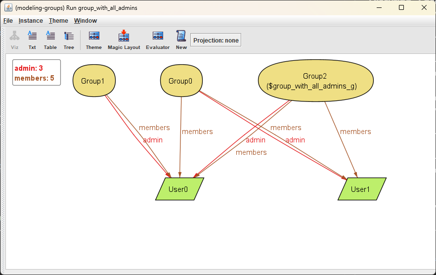

图 3 Alloy 可视化图。Fig. 3 An alloy visualization.

Alloy 还可以生成新的实例供可视化查看、更换主题，甚至针对特定实例运行 REPL。它是发现意外情况的绝佳工具！Alloy can also generate new examples to visualize, change the theme, and even run a REPL on specific examples. It’s a great tool for finding unexpected situations!

我们也可以让 Alloy 检查某个性质是否始终成立。这通常用来检查我们是否保证了某个数据不变式。例如，我们可能希望一个数据不变式是“群组永远非空”。We can also ask Alloy to check that a property always holds. This is usually used to check that we guarantee a data invariant. For example, we might want a data invariant to be “groups are never empty”.

```
check no_empty_groups {
  admins_members_of_groups =>
    all g: Group | some g.members
}
```

对此运行分析器，如果能找到反例，它就会给出反例的可视化图。不过在这里，它什么也没找到，因此我们可以更有信心地认为该性质成立。Running the analyzer on this would give us a visualization of a counterexample, if it can find one. In this case, though, it doesn’t find anything, so we can be more confident the property holds.

```
Executing "Check no_empty_groups"
No counterexample found. Assertion may be valid. 2ms.
```

### 抽象Abstractions

规约语言处于比编程语言更高的抽象层次，这意味着它们能够表达并检查某些性质，而把这些性质编成程序来处理，在计算上可能很难行得通。让我们在数据模型中加入一条：某些用户可以有另一位用户作为其推荐人。这很容易表示为数据库记录。Specification languages live at a higher level of abstraction that programming languages, meaning they can express and check properties that would be too computationally infeasible to program. Let’s add into our data model that some users can have another user who referred them. That’s easy to express as a database record.

```
record Users {
  id: Int
+ referrer: Int + NULL
}
```

这带来了一个新的数据不变式：用户不能是自己的推荐人。作为 SQL 约束，它大致会是 `u.referrer != u.id`。在 Alloy 中则是这样：This implies a new data invariant: users cannot be their own referrer. As a SQL constraint, it would look something like `u.referrer != u.id`. In Alloy, it would look like this:

```
sig User {
  referrer: lone User // 0 or 1
}

pred no_self_loops {
  all u: User |
    u != u.referrer
}
```

现在，再给这个约束加一点变化：任何用户都不能*通过传递关系*成为自己的推荐人。如果 Alice 推荐了 Bob，Bob 推荐了 Eve，那么 Eve 就不能曾经推荐过 Alice。Now, one more twist to the constraint: no user can *transitively* be their own referrer. If Alice refers Bob and Bob refers Eve, Eve cannot have referred Alice.

这在 SQL 中极其困难。至少需要使用递归公用表表达式，而得到的查询既复杂，计算开销也很大。This is extraordinary difficult in SQL. At the very least we’d need use recursive common table expressions, and the resulting query will be convoluted and computationally expensive.

另一方面，传递查询在 Alloy 中轻而易举。在 Alloy 中，`Alice.^referrer` 是推荐关系的“传递闭包”：一个包含 Alice 的推荐人、推荐人的推荐人、推荐人的推荐人的推荐人，等等的集合。On the other hand, transitive lookups are trivial in Alloy. In Alloy, `Alice.^referrer` is the “transitive closure” of referrals: the set containing Alice’s ref, the ref’s ref, the ref’s ref’s ref, etc.

同一个约束在 Alloy 中写作：The same constraint in Alloy:

```
pred no_cycles {
  all u: User |
    !(u in u.^referrer)
}
```

### 与实现and Implementations

能在 Alloy 中表达这个约束固然很好，但对实际的 SQL 数据库并没有帮助。SQL 仍然无法简洁地支持传递查询。It’s good that we can express the constraint in Alloy, but that doesn’t help us with our actual SQL database. SQL still doesn’t cleanly support transitive lookups.

不过，我们可以用 Alloy 找出一个能在 SQL 中实现、而且*同样*能保证 `no_cycles` 的约束。然后我们就测试But we can use Alloy to figure out an implementable SQL constraint that *also* guarantees `no_cycles`. Then we’d test

```
check { implementable_property => no_cycles }
```

这种情况下，我们会说 `implementable_property` 比 `no_cycles` *更强*。我的一个想法是给用户规定某种顺序，比如按 id 或注册日期排序。这样，我猜想，如果我们只能推荐注册日期更早的人，就不会出现环。这在 SQL 中比较容易检查。In this case we’d say that `implementable_property` is *stronger* than `no_cycles`. One idea I have would be to place some ordering on users, like id or signup date. Then I’d predict that if we could only refer someone with an earlier signup date, we wouldn’t have any cycles. This would be relatively easy to check in SQL.

练习Exercise

用我们的记法（而不是 Alloy 的记法）写出约束：“如果用户有推荐人，那么该用户的 `created_at` 晚于推荐人的 `created_at`。”Write the constraint (in our notation, not Alloy’s) “If a user has a referrer, the user’s `created_at` is later than the referrers `created_at`.

解答Solution

在 Alloy 中：In Alloy:

```
sig User {
  referrer: lone User,
  created_at: disj Int
}

pred referral_must_come_later {
  all u, ref: User |
    u.referrer = ref => gt[u.created_at, ref.created_at]
}
```

现在可以检查，这个可实现的约束是否保证了数据模型的性质：Now we can check that our implementable constraint guarantees our data model property:

```
check implementation_works {
  referral_must_come_later => no_cycles
}
```

Alloy 检查通过，没有找到反例，因此我们可以有信心地认为这个约束达到了预期效果。Alloy 帮助我们找到了以低廉代价强制实施高成本数据模型约束的方法。Alloy passes this with no counterexample, so we can be confident this constraint does what we want. Alloy helped us find a cheap way of enforcing an expensive data model constraint.

“表明一个实现符合更抽象的模型”的技术术语是*精化*。The technical term for “showing an implementation matches a more abstract model” is *refinement*.

## 用规约寻找缺陷Finding Bugs with Specifications

形式化规约的主要用途是发现设计错误。设计错误比代码错误代价更高，因此更需要尽早发现。[[由于形式化规约处于更高的抽象层次，它们能更容易地发现设计错误。]]The main use-case of formal specifications is to find errors in designs. Design errors are more expensive than code errors, and so are more important to detect early. [[Since formal specifications live at a higher level of abstraction, they can more easily find design errors.]]

我教授 Alloy 时，会用一个简化的访问权限模型演示这一点。我们有一组 User 和 Resource。Resource 只能由其 `readable_by` 集合中的 User 读取。When I teach Alloy, I demonstrate this with a simplified model of access permissions. We have a set of Users and Resources. Resources can only be read by Users in their `readable_by` set.

```
sig User {}

sig Resource {
  readable_by: set User
}

pred can_access[u: User, r: Resource] {
  u in r.readable_by
}

run {some u: User, r: Resource | can_access[u, r]}
```

在此基础上，我们再规定某些资源具有*父资源*。如果资源是文件，父资源可以是它所在的文件夹。与前面的推荐关系示例一样，任何资源都不能通过传递关系成为自己的父资源。On top of this, we add that some resources have *parents*. If our resources are files, the parent could be the containing folder. As with our prior example of referrals, no resource can transitively be its own parent.

```
sig Resource {
  readable_by: set User
+ ,parent: lone Resource
}
+ fact no_cycles {
+ no r: Resource |
+   r in r.^parent
+}
```

最后，我们修改访问规则，使用户只要有权读取某个资源的父资源，就能访问该资源。Finally, we amend the access rule, so that a user can access a resource if they have permission to read its parent.

```
pred can_access[u: User, r: Resource] {
  u in r.readable_by
+ || u in r.parent.readable_by
}
```

加上这一条后，我问学员：“如果我们能访问某个资源，是否就保证能访问它的所有子资源？”After adding this, I ask my class “if we can access a resource, are we guaranteed to access all of its children?”

```
assert parent_implies_child {
  all u: User, r: Resource |
    can_access[u, r] =>
      all child: r.~parent | //r.~parent is `children of r`
        can_access[u, child]
}

check parent_implies_child
```

多数人惊讶地发现，答案是*不*，这个性质*并不*成立！和之前一样，我们可以用图的可视化形式查看反例，也可以将其输出为 ASCII 表格：Most people are surprised to find out *no*, this property does *not* hold! As before, we can see the counterexample as a graph visualizatin, but we can also output it as an ASCII table:

```
┌─────────────┬───────────┬──────────┐
│this/Resource│readable_by│parent    │
├─────────────┼───────────┼──────────┤
│Resource$0   │User$0     │          │
├─────────────┼───────────┼──────────┤
│Resource$1   │           │Resource$0│
├─────────────┼───────────┼──────────┤
│Resource$2   │           │Resource$1│
└─────────────┴───────────┴──────────┘
```

为了解释这个出错的实例，问题如下：To explain the error instance, this is the problem:

> 1. 开始时有三个资源：Parent（`Resource$0`）、Child（`Resource$1`）和 Grandchild（`Resource$2`）。*只有* Parent 的 `readable_by` 中包含这个 User。We start with three resources: Parent (`Resource$0`), Child (`Resource$1`), and Grandchild (`Resource$2`). *Only* Parent has the User in `readable_by`.
> 2. 因为 User 可以访问 Parent，所以该性质断言它可以访问 Child。Because the User can access Parent, the property asserts they can access Child.
> 3. 检查 Child 时，我们发现 `User in Parent.readable_by`，所以可以访问它。In checking Child, we see that `User in Parent.readable_by`, so we can access it.
> 4. 因为我们可以访问 Child，所以该性质断言我们可以访问 Grandchild。Because we have access to Child, the property asserts we can access Grandchild.
> 5. 这个 User 既不在 Child 的 `readable_by` 中，也不在 Grandchild 的该集合中。因此，我们无法访问 Grandchild。The User is not in Child or Grandchild’s `readable_by`. So we cannot access Grandchild.
> 6. 我们可以访问 Child，却不能访问它的所有子资源，因此违反了该性质。We can access Child but not all of its children, leading to a property violation.

这才是形式化规约的真正威力：完整规约不到 30 行，却能发现许多经验丰富的开发者都会漏掉的细微错误。为修复它，我们可以修改 `readable_by`，通过传递关系检查一个资源的全部祖先。This is the real power of formal specification: the full spec is less than 30 lines and still finds a subtle error many experienced developers miss. To fix this, we can modify `readable_by` to transitively check a resource’s entire ancestry.

```
pred can_access[u: User, r: Resource] {
  u in r.readable_by
- || u in r.parent.readable_by
+ || u in r.^parent.readable_by
}
```

（和之前一样，我们仍然需要设法在数据库中实现传递约束。但着手实现一个正确的设计，总好过实现一个可能有问题的设计。）(As before, we would still need to find a way to implement a transitive constraint in our database. But it is always better to be working on implementing a correct design than to implement a possibly-broken one.)

## 小结Summary

1. 我们可以在比数据库实现更高的抽象层次上表示数据（或其他系统）。We can represent data (or other systems) at a higher level of abstraction than what the database implements.
2. 这样，我们就能用形式化规约语言直接测试这些抽象。By doing this, we can test the abstractions directly, in a formal specification language.
3. Alloy 就是一种这样的形式化规约语言，能够生成满足性质的实例的可视化图。它还可以测试性质是否成立。Alloy is one such formal specification language, and can produce visualizations of satisfying properties. It can also test that properties hold.
4. 因为处于更高的抽象层次，我们可以表达那些无法直接在数据库层面强制实施的不变式。Because we’re at a higher level of abstraction, we can express invariants that would be impossible to directly enforce at the database level.
5. Alloy 可以测试某个可实现的约束是否也保证了抽象不变式。Alloy can test if an implementable constraint also guarantees an abstract invariant.

虽然数据建模是形式化规约的一个良好用例，但它在并发系统建模中才真正大放异彩。下一章，我们将展示形式化规约如何发现软件设计中的竞态条件。While data modeling is a good use case for formal specification, it really shines for modeling concurrent systems. In the next chapter, we will show how a formal specification can find race conditions in a software design.

### 延伸阅读Further Reading

- [Alloy 文档](https://alloy.readthedocs.io/en/latest/) [https://alloy.readthedocs.io/en/latest/][Alloy Docs](https://alloy.readthedocs.io/en/latest/) [https://alloy.readthedocs.io/en/latest/]
- [《使用 Alloy 6 进行形式化软件设计》](https://haslab.github.io/formal-software-design/) [https://haslab.github.io/formal-software-design/][Formal Software Design with Alloy 6](https://haslab.github.io/formal-software-design/) [https://haslab.github.io/formal-software-design/]
- [《软件抽象》](https://mitpress.mit.edu/9780262528900/software-abstractions/) [https://mitpress.mit.edu/9780262528900/software-abstractions/]（书籍）[Software Abstractions](https://mitpress.mit.edu/9780262528900/software-abstractions/) [https://mitpress.mit.edu/9780262528900/software-abstractions/] (book)

Alloy 模型示例：Examples of Alloy models:

- [使用 Alloy 对数据库表建模](https://bytes.zone/posts/modeling-database-tables-in-alloy/) [https://bytes.zone/posts/modeling-database-tables-in-alloy/][Modeling Database tables in Alloy](https://bytes.zone/posts/modeling-database-tables-in-alloy/) [https://bytes.zone/posts/modeling-database-tables-in-alloy/]
- [使用 Alloy 对 Git 内部机制建模](https://bytes.zone/posts/modeling-git-internals-in-alloy-part-3-operations-on-blobs-and-trees/) [https://bytes.zone/posts/modeling-git-internals-in-alloy-part-3-operations-on-blobs-and-trees/]（共 3 篇）[Modeling Git Internals in Alloy](https://bytes.zone/posts/modeling-git-internals-in-alloy-part-3-operations-on-blobs-and-trees/) [https://bytes.zone/posts/modeling-git-internals-in-alloy-part-3-operations-on-blobs-and-trees/] (3-parter)
- [风暴潮](https://jwbaugh.github.io/papers/baugh-abz-2016.pdf) [https://jwbaugh.github.io/papers/baugh-abz-2016.pdf][Storm Surges](https://jwbaugh.github.io/papers/baugh-abz-2016.pdf) [https://jwbaugh.github.io/papers/baugh-abz-2016.pdf]

# 系统建模System Modeling

上一章，我们展示了如何用形式化规约分析数据模型并寻找问题。但这只是规约这座冰山的一角。我们还可以用它为*系统*建模。In the last chapter, we showed how formal specification can be used to analyze a data model and look for problems. But that’s only the tip of the specification iceberg. We can also use it to model *systems*.

## 场景Situation

我们有一些银行用户。银行用户可以相互汇款。系统有透支保护，因此汇款不能让账户余额降到零以下。这很容易保证，只要在每笔汇款中加上一个 *if* 检查就行了！We have some bank users. Bank users can wire money to each other. We have overdraft protection, so wires cannot reduce an account value below zero. That’s easy to guarantee, just throw an *if* check on each wire and you’re done!

……但如果用户可以同时发起多笔汇款呢？如果计算机在处理一笔汇款的中途崩溃呢？如果有人试图给*自己*汇款呢？如果有人同时分多笔给自己汇款，随后某台服务器又崩溃了呢？…But what if users can send multiple wires at the same time? What if a computer crashes in the middle of processing a wire? What if someone tries to send *themselves* money? What if someone tries to send themselves money in multiple wires at the same time, and then one of the servers crash?

这就是我们需要为系统建模的原因。我们想确认，性质在*每一种可能的*行为下都成立，而不仅仅是在理想流程中成立。This is why we need to model systems. We want to see that our properties hold under *every possible* behavior, not just on the happy path.

我们将用逻辑来建模。And we’ll use logic to model it.

## 所用逻辑The Logic

我们将分三个阶段处理这个系统。首先，看看普通的谓词逻辑如何就足以准确地为问题建模。然后，对逻辑做一个简单扩展，以更优雅地表达规约。最后，将其翻译为一种真正的工具能够使用的形式，让工具直接检查我们的逻辑是否有错。We’re going to handle this system in three stages. First, we’ll see how our regular predicate logic is enough to accurately model our problem. Then, we’ll make a simple extension to our logic to more elegantly express the spec. Finally, we’ll translate it to a real tool that can directly check our logic for errors.

暂时假设系统极其简单：有两个硬编码的变量 `alice` 和 `bob`，初始时各有 `10` 美元，而且只允许从 Alice 向 Bob 转账。此外，转账完全是原子的：检查余额是否充足、取款和存款都发生在同一个瞬间。最终建模的系统会更复杂，这里只是为了说明这些思想。For now we’ll assume an extremely simple system: two hardcoded variables `alice` and `bob`, both start with `10` dollars, and transfers are only from Alice to Bob. Also, the transfer is totally atomic: we check for adequate funds, withdraw, and deposit all in a single moment of time. Our modeled system will be more complex; this is just to relate the ideas.

首先，来看系统的一个有效*行为*，也就是系统可能的一种演变方式。First, let’s look at a valid *behavior* of the system, or possible way it can evolve.

```
alice:  10 -> 5  -> 3  -> 3  -> ...
bob:    10 -> 15 -> 17 -> 17 -> ...
```

在编程中，我们会把 `alice` 和 `bob` 看作不断变化的变量。怎样才能*纯粹*用谓词逻辑表达这些变量？一种方式是用值的*数组*来替换它们。`alice[0]` 是 `alice` 的初始状态，`alice[1]` 是第一个时间步之后的状态，依此类推。于是，时间“不过”就是自然数集合。In programming, we’d think of `alice` and `bob` as variables that change. How can we express those variables *purely* in terms of predicate logic? One way would be to replace them with *arrays* of values. `alice[0]` is the initial state of `alice`, `alice[1]` is after the first time step, etc. Time, then, is “just” the set of natural numbers.

```
Time  = {0,  1,  2,  3, ...}
alice = [10, 5,  3,  3, ...]
bob   = [10, 15, 17, 17, ...]
```

那是一个有效行为。下面是一些*无效*行为：That is a valid behavior. Here are some *invalid* behaviors:

```
alice = [10, 3,  ...]
bob   = [10  15, ...]

alice = [10, -1,  ...]
bob   = [10  21,  ...]
```

第一个行为无效，是因为 Bob 收到的钱比 Alice 减少的钱多。第二个无效，是因为它违反了我们提出的不变式：账户余额不能为负。我们能否写出一个谓词，使其对有效转移为*真*，而对这两个无效行为中的某个转移为*假*？The first is invalid because Bob received more money than Alice lost. The second is invalid because it violates our proposed invariant, that accounts cannot go negative. Can we write a predicate that is *true* for valid transitions and *false* for some transition in our two invalid behaviors?

这是一种写法：Here’s one way:

```
Time = Nat

Transfer(t: Time) =
  some value in 0..=alice[t]:
    1. alice[t+1] == alice[t] - value
    2. bob[t+1] == bob[t] + value
```

逐一检查：对于有效行为中的每个 `t`，它都为真；对于无效行为中的至少一个 `t`，它为假。注意，Alice *没有*发起转账的那些步骤也满足 `Transfer`，我们只需选择 `value = 0`。Go through and check that this is true for every `t` in the valid behavior and false for at least one `t` in the invalid behavior. Note that the steps where Alice *doesn’t* send a transfer also pass `Transfer`; we just pick `value = 0`.

现在，我可以写出一个谓词，完整描述什么是“有效行为”：I can now write a predicate that perfectly describes what a “valid behavior” is:

```
Spec =
  1. alice[0] == 10
  2. bob[0]   == 10
  3. all t in Time:
    Transfer(t)
```

不过，把“什么都没发生”当作“Alice 发起了一笔空转账”有点奇怪。在真实系统中，我们大概不希望人们不停地互相转账零美元：Now allowing “nothing happens” as “Alice sends an empty transfer” is a little bit weird. In the real system, we probably don’t want people to constantly be sending each other zero dollars:

```
Transfer(t: Time) =
- some value in 0..=alice[t]:
+ some value in 1..=alice[t]:
    1. alice[t+1] == alice[t] - value
    2. bob[t+1] == bob[t] + value
```

但这样一来，就不能有任何什么都没发生的时间步了。这意味着*没有*任何行为是有效的！But now there can’t be a timestep where nothing happens. And that means *no* behavior is valid!

练习：没有有效行为Exercise: No valid behaviors

解释为什么当前版本的规约不可能有*任何*有效行为，也就是说，至少对某些 `t`，`Transfer(t)` 为假。Explain why the current version of the spec cannot have *any* valid behaviors, ie for at least some `t`, `Transfer(t)` is false.

提示：记住，`Time` 是自然数的别名，这意味着每个行为都有*无限*多个步骤。Hint: Remember, `Time` is an alias for the natural numbers, meaning every behavior has an *infinite* number of steps.

解答Solution

因此，建模时通常会加入一个*停顿步*，如下所示：So typically when modeling we add a *stutter step*, like this:

```
Spec =
  1. alice[0] == 10
  2. bob[0]   == 10
  3. all t in Time:
    || Transfer(t)
    || 1. alice[t+1] == alice[t]
       2. bob[t+1] == bob[t]
```

（这也是我们能用无限行为对有限算法建模的原因。如果算法在 `t=21` 时完成，那么 `t=22,23,24...` 就全都是停顿步。）(This is also why we can use infinite behaviors to model a finite algorithm. If the algorithm completes at `t=21`, `t=22,23,24...` are all stutter steps.)

这里牵涉的部分已经够多了，我想把它拆成几个子谓词。There’s enough moving parts here that I’d want to break it into subpredicates.

```
Init =
  1. alice[0] == 10
  2. bob[0]   == 10

Stutter(t) =
  1. alice[t+1] == alice[t]
  2. bob[t+1] == bob[t]

Next(t) = Transfer(t) // forshadowing

Spec =
  1. Init
  2. all t in Time:
    Next(t) || Stutter(t)
```

最后，我们如何表示性质 `NoOverdrafts`？它是一个必须在所有时刻都为真的*不变式*。因此，我们采用与 `Spec` 中相同的做法，写出一个针对所有时刻的谓词。Now finally, how do we represent the property `NoOverdrafts`? It’s an *invariant* that has to be true at all times. So we do the same thing we did in `Spec`, write a predicate over all times.

```
property NoOverdrafts =
  all t in Time:
    alice[t] >= 0
```

我们甚至可以说 `Spec => NoOverdrafts`，也就是，如果一个行为在 `Spec` 下有效，那么它就满足 `NoOverdrafts`。We can even say that `Spec => NoOverdrafts`, ie if a behavior is valid under `Spec`, it satisfies `NoOverdrafts`.

练习：扩展到 BobExercise: Extending to Bob

修改 `Next`，让 Bob 也可以向 Alice 转账。不要想得太巧妙，用尽可能直接的方式即可。Modify the `Next` so that Bob can send Alice transfers, too. Don’t try to be too clever, just do this in the most direct way possible.

附加题：Alice 和 Bob 能在同一个步骤中相互转账吗？Bonus: can Alice and Bob transfer to each other in the same step?

解答Solution

### 时序逻辑Temporal Logic

这样固然不错，但在实践中，把时间当作一个可以对其量化的集合有两个缺点：This is good and all, but in practice, there’s two downsides to treating time as a set we can quantify over:

1. 它很繁琐。我们到处都要写 `var[t]` 和 `var[t+1]`。It’s cumbersome. We have to write `var[t]` and `var[t+1]` all over the place.
2. 它过于强大。我们可以写出 `alice[t^2-5] == alice[t] + t` 这样的表达式。It’s too powerful. We can write expressions like `alice[t^2-5] == alice[t] + t`.

问题 (2) 似乎是件好事；逻辑的整个*目的*不就是拥有丰富的表达能力吗？但我们心中有一个长远目标：让计算机检查我们的形式化规约。我们需要限制模型的表达能力，使工具能够切实处理它。Problem (2) might seem like a good thing; isn’t the whole *point* of logic to be expressive? But we have a long-term goal in mind: getting a computer to check our formal specification. We need to limit the expressivity of our model to make it tractable to our tooling.

在实践中，这意味着让时间隐含在模型中，而不是显式地对时间进行量化。In practice, this will mean making time implicit to our model, instead of explicitly quantifying over it.

[[首先，我们需要限制时间的使用方式。]] 在某个给定时刻，我们只能查看变量的*当前*值（`var[t]`）和*下一个*值（`var[t+1]`）。不能有 `var[t+16]`、`var[t-1]`，或其他任何复杂的东西。[[The first thing we need to do is limit how we can use time.]] At a given point in time, all we can look at is the *current* value of a variable (`var[t]`) and the *next* value (`var[t+1]`). No `var[t+16]` or `var[t-1]` or anything else complicated.

而且，我们已经见过表达这种关系的数学惯例：加撇号！对于给定时刻 `t`，可以规定 `var` 表示 `var[t]`，`var'` 表示 `var[t+1]`。于是 `Transfer(t)` 就变成And it turns out we’ve already seen a mathematical convention for expressing this: priming! For a given time `t`, we can define `var` to mean `var[t]` and `var'` to mean `var[t+1]`. Then `Transfer(t)` becomes

```
Transfer =
  some value in 1..=alice:
    1. alice' == alice - value
    2. bob' == bob + value
```

我们甚至不再需要把时间作为 `Transfer` 的参数！主体中带有撇号的谓词有时称为*动作*。We don’t even need to parameterize `Transfer` by time anymore! A predicate with primes in the body is sometimes called an *action*.

练习：用撇号表示停顿Exercise: Stuttering with Primes

重写 `Stutter(t)`，用撇号代替 `t`。Rewrite `Stutter(t)` to use primes instead of `t`.

解答Solution

接下来，`Spec` 和 `NoOverdrafts` 中都有 `all t in Time: P(t)` 这个结构。换言之，就是“P 始终为真”。因此，我们可以加入一个新术语 `always`。逻辑学家通常用 □ 或 `[]` 表示相同的意思。Next we have the construct `all t in Time: P(t)` in both `Spec` and `NoOverdrafts`. In other words, “P is always true”. So we can add `always` as a new term. Logicians conventionally use □ or `[]` to mean the same thing.

```
property NoOverdrafts =
  always (alice >= 0 && bob >= 0)
  // or [](alice >= 0 && bob >= 0)

Spec =
  Init && always (Next || Stutter)
```

练习：始终算子的规则Exercise: Always rules

这里，我们用 `[]P` 表示 `always P`。Here we will use `[]P` to mean `always P`.

1. 证明 `[](all x: P(x))` 与 `all x: []P(x)` 等价，其中 `P` 是某种时序谓词（它隐式地接受一个时间参数）。Show that that `[](all x: P(x))` is equivalent to `all x: []P(x)`, where `P` is some sort of temporal predicate (which implicitly takes a time).
2. 证明 `[](P && Q)` 与 `[]P && []Q` 相同Show that `[](P && Q)` is the same as `[]P && []Q`

解答Solution

现在，时间在规约中*几乎*已经完全隐含起来，只剩一个例外：`Init` 中有 `alice[0]` 和 `bob[0]`。我们只需再加一条约定：如果变量的引用位于时序算子的作用域*之外*，它就表示 `var[0]`。由于 `Init` 位于 `[]` 之外，它就变成Now time is *almost* completely implicit in our spec, with just one exception: `Init` has `alice[0]` and `bob[0]`. We just need one more convention: if a variable is referenced *outside* of the scope of a temporal operator, it means `var[0]`. Since `Init` is outside of the `[]`, it becomes

```
Init =
  1. alice == 10
  2. bob == 10
```

至此，我们从模型中移除了作为显式值的 `Time`。And with that, we’ve removed `Time` as an explicit value in our model.

加入撇号和 `always` 后，这就成为一种*时序逻辑*：一种能够对事物随时间变化的方式进行建模的逻辑。因此，它非常适合为软件系统建模。The addition of primes and `always` makes this a *temporal logic*: one that can model how things change over time. And that makes it ideal for modeling software systems.

注Note

分析系统并不*一定*要建立时序逻辑。在 2022 年以前，Alloy 用户通过显式建立 `Time` 签名来为系统建模。但事实证明，这很繁琐，因此 Alloy 在 2022 年纳入了时序逻辑模型。You don’t *have* to make a temporal logic to analyze systems. Before 2022, Alloy users modeled systems by making an explicit `Time` signature. But this proved to be cumbersome, so in 2022 Alloy incorporated a temporal logic model.

无论如何，我们将使用一种从一开始就以时序逻辑为基础设计的规约语言。Regardless, we’ll be using a specification language was that designed with temporal logic from the ground up.

## 实践：TLA+In Practice: TLA+

为这类并发系统建模时，最流行的规约语言之一是 *TLA+*。TLA+ 由图灵奖得主 Leslie Lamport 发明，他还发明了各种各样的并发算法和 LaTeX。下面是当前规约的 TLA+ 版本：One of the most popular specification languages for modeling these kinds of concurrent systems is *TLA+*. TLA+ was invented by the Turing award-winner Leslie Lamport, who also invented a wide variety of concurrency algorithms and LaTeX. Here’s our current spec in TLA+:

代码清单 5 （TLA+）Listing 5 (TLA+)

```
---- MODULE transfers ----
EXTENDS TLC, Integers

VARIABLES alice, bob
vars == <<alice, bob>>

Init ==
  alice = 10
  /\ bob = 10

AliceToBob ==
  \E amnt \in 1..alice:
    alice' = alice - amnt
    /\ bob' = bob + amnt

BobToAlice ==
  \E amnt \in 1..bob:
    alice' = alice + amnt
    /\ bob' = bob - amnt

Next ==
  AliceToBob
  \/ BobToAlice

Spec == Init /\ [][Next]_vars \* [](Next \/ Stutter)

NoOverdrafts ==
  [](alice >= 0 /\ bob >= 0)

====
```

TLA+ 使用数学记法的 ASCII 版本：用 `/\` 和 `\/` 表示 `&&/||`，用 `\A` 和 `\E` 表示 `all/some`，等等。`==` 用于定义，`[][Next]_vars` 则是 `[](Next || Stutter)` 的 TLA+ 记法。TLA+ uses ASCII versions of mathematicians notation: `/\` and `\/` for `&&/||`, `\A` and `\E` for `all/some`, etc. `==` is used for definition, and `[][Next]_vars` is TLA+ notation for `[](Next || Stutter)`.

现在有了规约和性质，我们就可以使用*模型检查器*生成这个系统所有可能的状态，看看是否有任何状态破坏不变式。与 Alloy 一样，TLA+ 最常见的检查方式是在 VSCode 中使用[扩展](https://github.com/tlaplus/vscode-tlaplus/) [https://github.com/tlaplus/vscode-tlaplus/]。但配置模型运行需要做一些设置，因此我编写了一个名为 tlacli [https://github.com/hwayne/tlacli] 的工具，以便通过命令行完成更多操作。它不支持 TLA+ 的全部功能，但适用于这样的快速演示。Now that we have a specification and a property, we can use a *model checker* to generate all possible states of this system and see if any of them break our invariant. Like Alloy, TLA+ is most often checked from VSCode via [an extension](https://github.com/tlaplus/vscode-tlaplus/) [https://github.com/tlaplus/vscode-tlaplus/]. But setting up a model run takes a bit of configuration, so I created a tool called tlacli [https://github.com/hwayne/tlacli] to do more from the command line. It doesn’t support all of TLA+’s features but is suitable for quick demos like this.

```bash
tlacli check transfers.tla --prop NoOverdrafts
```

结果没有发现错误：And it gets no errors found:

```
Model checking completed. No error has been found.
421 states generated, 21 distinct states found.
```

对于这个简单模型，一切都很好，但如果同时有多笔交易正在处理呢？面对并发、非原子的交易，我们的不变式仍然成立吗？So this is all well and good for our simple model, but what if more than one transaction could be in flight at the same time? Does our invariant still work if with concurrent, nonatomic transactions?

### 加入并发Adding Concurrency

我们可以在“纯”TLA+ 中加入并发，[[但那需要用到一些我现在不想解释的“TLA+ 特有写法”。]] 因此，我们改用 *PlusCal*，一种可以编译为 TLA+ 的语言。它内置于 TLA+ 工具中，看起来更像编程语言，而不是数学公式，所以很受初学者欢迎。We could add concurrency to our “pure” TLA+, [[but that requires a few “TLA+-isms” I don’t feel like explaining right now.]] So instead we’re going to use *PlusCal*, a language that compiles to TLA+. It’s built-in with the TLA+ tooling and looks more like programming language than a math formula, so it’s very popular with beginners.

代码清单 6 （TLA+/PlusCal）Listing 6 (TLA+/PlusCal)

```
---- MODULE transfers2 ----
EXTENDS TLC, Integers

People == {"alice", "bob"}
Money == 1..10
NumTransfers == 2

(* --algorithm wire
variables
  acct \in [People -> Money];

define
  NoOverdrafts ==
    [](\A p \in People:
      acct[p] >= 0)
end define;

process wire \in 1..NumTransfers
variable
  amnt \in 1..5;
  from \in People;
  to \in People
begin
  Check:
    if acct[from] >= amnt then
      Withdraw:
        acct[from] := acct[from] - amnt;
      Deposit:
        acct[to] := acct[to] + amnt;
    end if;
end process;
end algorithm; *)

====
```

其中大部分*看起来*像是语法选择有些不同寻常的编程语言，但有些地方需要注意。`acct` 被设为 `[People -> Money]` 的*任意一个值*；这个集合大致包含将 Alice 和 Bob 映射到 1 至 10 之间数值的所有映射。因此，`acct` 的初值可以是 `{alice: 1, bob: 10}`、`{alice: 3, bob: 6}`，或其余 98 种可能组合中的任意一种。Most of this *looks* like a programming language with some unusual syntactic choices, but there’s some things to pay attention to. `acct` is set to *any value of* `[People -> Money]`, roughly the set of all mappings of Alice and Bob to numbers between 1 and 10. So `acct` can start as `{alice: 1, bob: 10}`, `{alice: 3, bob: 6}`, or any of the other 98 possible combinations.

我们的模型在开始时还有两笔不同的汇款同时存在（`process wire \in 1..NumTransfers`，其中 `NumTransfer == 2`）。每笔汇款都有*各自的* `amnt`、`from` 和 `to`，它们*也*分别是集合中的元素。不同汇款可以为这些局部值作出不同选择。再结合 `amnt`，总共有 40,000 种可能的初始状态。Our model also starts with two distinct wires simultaneously (`process wire \in 1..NumTransfers` where `NumTransfer == 2`). Each wire has *its own* `amnt`, `from`, and `to`, which are *also* individually elements of sets. Different wires can pick different local values for this. Between this and the `amnt`, there are 40,000 possible initial states.

在 `wire` 内部，有 `Check:`、`Withdraw:` 和 `Deposit:`。它们是**标签**，也就是由原子动作组成的组。每笔汇款需要三个步骤才能处理完成：检查余额一步，取款一步，存款一步。粗略估算，两笔 `wires` 有二十种可能的交错执行方式。更精确地说，要稍少一些，因为有些汇款会在 `Check` 处提前结束。Inside `wire` we have `Check:`, `Withdraw:`, and `Deposit:`. These are **labels**, or groups of atomic actions. Each wire takes three steps to fully process: checking the balance is one step, withdrawing is one step, and depositing is one step. To a first order approximation, there are twenty possible ways the two `wires` can interleave. More precisely, slightly fewer, because some wires will end early at the `Check`.

最后，`NoOverdrafts` 是旧版本的直接翻译，只是推广到了任意数量的用户。Finally, `NoOverdrafts` is a straight translation of our old version, just generalized to any number of people.

为了把 PlusCal 编译成 TLA+，我运行了 `tlacli translate transfers2.tla`。翻译在同一文件内完成，结果出现在代码下方。现在进行模型检查，看看 `NoOverdrafts` 是否仍然成立：To compile the PlusCal to TLA+, I ran `tlacli translate transfers2.tla`. The translation is done in-file and appears below the code. Now let’s model check it and see if `NoOverdrafts` still holds:

```bash
tlacli check transfers2.tla --prop NoOverdrafts
```

这样做之后，突然出现了一个错误：If we do this, we suddenly get an error:

```
Error: Invariant NoOverdrafts is violated.
Error: The behavior up to this point is:
State 1: <Initial predicate>
/\ acct = [alice |-> 1, bob |-> 1]
/\ amnt = <<1, 1>>
/\ to = <<"bob", "alice">>
/\ from = <<"alice", "alice">>
/\ pc = <<"Check", "Check">>

\* four more states after this
```

这个缺陷之所以出现，是因为检查和取款不是原子的：它们发生在不同的时间步。如果让它们在同一个时间步发生，错误应该就会消失：This bug happens because checking and withdrawing are nonatomic: they happen in different time steps. If we make them happen in the same time step, the error should go away:

```
begin
- Check:
+ CheckAndWithdraw:
    if acct[from] >= amnt then
-     Withdraw:
        acct[from] := acct[from] - amnt;
+ \* remember to retranslate the file!
```

重新运行模型检查器，可以看到这个错误不再出现。如果愿意，我们可以把 `NumTransfers` 设为 6，或再增加三个用户，TLA+ 都能顺畅地检查这个更大的问题。这正是形式化规约对复杂系统如此有用的原因！We can rerun the model checker and see that the error no longer occurs. If we want, we can set `NumTransfers` to 6 or add another three people, and TLA+ will seamlessly check our larger problem. This is what makes formal specification so useful for complex systems!

### 活性Liveness

查看翻译结果，你会看到 PlusCal 额外生成了这个性质：If you look at the translation, you’d see this extra property PlusCal generated:

```
Termination == <>(\A self \in ProcSet: pc[self] = "Done")
```

`ProcSet` 是所有汇款的集合（也就是 `1..2`）。`pc` 追踪每个进程当前所处的步骤：`pc[1] = "Deposit"` 表示进程 1 已准备好存款。因此，整个量化表达式就是“每个进程都处于‘Done’步骤”。`ProcSet` is the set of all wires (so `1..2`). `pc` tracks the current step of each process: `pc[1] = "Deposit"` means which process 1 is ready to deposit. The whole quantifier is then “every process is at the ‘Done’ step.”

那么 `<>` 呢？What about the `<>`?

还记得 `[]` 是*始终*，表示 `all t in Time` 吗？而 `<>`，即*最终*，表示的是 `some t in Time`。Remember how `[]` was *always*, and meant `all t in Time`? `<>`, or *eventually*, instead means `some t in Time`.

```
Termination =
  some t in Time:
    all self \in ProcSet:
      pc[self][t] = "Done"
```

`<>P` 表示 P 不必在开始时就为真，但在所有可能的时间线中，它都必须最终*变成*真。这就引出了 TLA+ 最强大的功能之一。我们的不变式是一种*安全性性质*：承诺某种“坏事”不会发生。与之相对的是*活性性质*：保证某种“好事”会发生。比如，进程最终会完成处理。`<>P` means that P doesn’t need to be true at the start, but it needs to eventually *become* true in all possible timelines. This gets to one of the most powerful features of TLA+. Our invariant was a kind of *safety property*: a promise that something “bad” doesn’t happen. The other half of the coin is the *liveness property*: something “good” is guaranteed to happen. Like, for example, our processes eventually finish processing.

我们可以用 `tlacli check wire.tla --prop Termination` 检查 `Termination`。令人意外的是，它*失败*了：We can check `Termination` with `tlacli check wire.tla --prop Termination`. Surprisingly, it *fails*:

```
State 4:
/\ acct = [alice |-> 0, bob |-> 1]
/\ amnt = <<1, 1>>
/\ to = <<"alice", "alice">>
/\ from = <<"alice", "alice">>
/\ pc = <<"Deposit", "Done">>

State 5: Stuttering
```

默认情况下，TLA+ 假设任何进程都可以在任何步骤崩溃。[[最好先假设情况会尽可能恶劣，再要求用户明确写出自己的假设。]] 如果要声明进程不会崩溃，就必须使其具有“公平性”：By default, TLA+ assumes any process can crash at any step. [[It’s better to assume maximum perversity and force users to make their assumptions explicit.]] If we want to say the process doesn’t crash, we have to make it “fair”:

```
+ fair process wire \in 1..NumTransfers
- process wire \in 1..NumTransfers
```

并非所有活性缺陷都能如此轻易地解决。修复活性缺陷往往需要重新思考根本设计。最好在仍处于设计阶段时重新思考，而不是等到产品发布之后。Not all liveness bugs are solved so easily. Often, fixing a liveness bug requires rethinking the fundamental design. Better to do that rethinking while we’re still in the design phase, as opposed to after we released the product.

练习：最终算子的规则Exercise: Eventually rules

1. 证明 `<>some x: P(x)` 与 `some x: <>P(x)` 等价，其中 `P` 是某种时序谓词（它隐式地接受一个时间参数）。Show that that `<>some x: P(x)` is equivalent to `some x: <>P(x)`, where `P` is some sort of temporal predicate (which implicitly takes a time).
2. 证明 `<>(P || Q)` 与 `<>P || <>Q` 相同。Show that `<>(P || Q)` is the same as `<>P || <>Q`.
3. 证明 `<>P = ![]!P`。Show that `<>P = ![]!P`.

解答Solution

## 实际应用中的规约Specification in the wild

过去两章介绍了两种不同的形式化规约语言：TLA+ 和 Alloy。人们了解到这类工具时，通常有两个问题：The past two chapters covered two different formal specification languages: TLA+ and Alloy. When people learn about these kinds of tools, they generally have two questions:

1. 现实中真的有人用它吗？Is this actually used in the real world?
2. 我如何确保代码符合规约？How do I make sure my code matches the specification?

第一个问题很容易回答：有很多广受关注的案例研究表明，形式化规约为普通公司节省了大量时间和金钱。我在“延伸阅读”中列出了一些例子。Question one is easy to answer: there are a lot of high-profile case studies of formal specification saving everyday companies a lot of time and money. I’ve put some examples in the “Further Reading” section.

第二个问题更难。正如在功能正确性一章中所见，代码的形式化验证*很难*。代码需要考虑的事情远比规约多。我们的转账模型抽象掉了从使用的具体软件包到向用户显示的“余额不足”对话框等一切内容。恰恰是这种抽象层次让规约如此强大；验证代码时，这种优势就失去了。Question two is harder. As we’ve seen in the functional correctness chapter, formal verification of code is *hard*. Code needs to worry about a lot more things than specifications do. Our transfer model abstracted away everything from the specific packages we use to the “insufficient funds” dialog we show to users. That level of abstraction is what makes specification so powerful in the first place; verifying code loses that power.

（*确实*有一些规约语言能把规约“精化”为代码，例如 [Event-B](https://www.event-b.org/) [https://www.event-b.org/]。不过，它们往往难用得多，成本也高得多。）(There *are* some specification languages that can “refine” spec into code, such as [Event-B](https://www.event-b.org/) [https://www.event-b.org/]. These tend to be significantly more difficult and expensive to use, though.)

但形式化规约领域还很年轻，我们已经开始看到一些有趣的发展。在我看来，最令人兴奋的创新是利用形式化规约生成*测试*。论文[《极限建模实践》](https://arxiv.org/abs/2006.00915) [https://arxiv.org/abs/2006.00915]展示了这一点：研究者用 TLA+ 规约为一个 C++ 库生成测试套件。But the field of formal specification is young and we’re starting to see some interesting developments. The most exciting innovation, in my opinion, is using a formal spec to generate *tests*. You can see ths in the paper [eXtreme Modeling in Practice](https://arxiv.org/abs/2006.00915) [https://arxiv.org/abs/2006.00915], where they used a TLA+ specification to generate a test suite for a C++ library.

## 小结Summary

1. TLA+ 是一种用于为软件系统建模并表达其性质的逻辑。TLA+ is a form of logic used to model software systems and express their properties.
2. 你可以对 TLA+ 规约进行*模型检查*，找出违反性质的时间线。You can *model check* a TLA+ specificaton to find timelines which break properties.
3. 我们可以检查某个性质是否在所有时间线的所有状态中都为真，或者是否在每条时间线的至少一个状态中为真。We can check that a property is true for all states in all timelines, or at least one state in each timeline.

前两章介绍了形式化规约的两种用途和两种工具。但这只是冰山一角：规约是一个丰富的领域，有各种有趣的语言和应用。我曾用规约语言为概率、机器人、系统动力学模型，乃至公司官僚体系建模！The last two chapters covered two uses of and two tools for formal specification. But this is just the tip of the iceberg: specification is a rich field with all sorts of interesting languages and applications. I’ve worked with specification languages for modeling probability, robotics, system dynamics models, and even corporate bureaucracies!

形式化规约和形式化验证共同构成*形式化方法*，即直接运用数学来编写代码的学科。我发现，（针对抽象模型的）形式化规约语言比（针对实际代码的）形式化验证语言对业界更有用，主要因为前者更容易学习，融入常规开发流程的成本也低得多。Formal specification and formal verification together for *formal methods*, the discipline of directly applying math to write code. I’ve found formal specification languages (on abstract models) more useful to industry than formal verification languages (on actual code), mostly because it’s easier to learn and a lot cheaper to incorporate into a regular development workflow.

下一章，我们将暂别形式化方法，转而关注另一类可以用逻辑优雅解决的实际问题。In the next chapter, we will leave formal methods behind and focus on a different class of practical problems elegantly solvable with logic.

### 延伸阅读Further Reading

TLA+ 资料：TLA+:

- [学习 TLA+](https://www.learntla.com) [https://www.learntla.com][Learn TLA+](https://www.learntla.com) [https://www.learntla.com]
- [《系统规约》](https://lamport.azurewebsites.net/tla/book.html) [https://lamport.azurewebsites.net/tla/book.html]是权威教科书。[Specifying Systems](https://lamport.azurewebsites.net/tla/book.html) [https://lamport.azurewebsites.net/tla/book.html] is the canonical textbook.

案例研究：Case Studies:

- [不运行代码，甚至不看代码，也能发现缺陷](https://www.youtube.com/watch?v=FvNRlE4E9QQ) [https://www.youtube.com/watch?v=FvNRlE4E9QQ] [视频][Finding bugs without running or even looking at code](https://www.youtube.com/watch?v=FvNRlE4E9QQ) [https://www.youtube.com/watch?v=FvNRlE4E9QQ] [video]
- [Amazon Web Services 中形式化方法的应用](https://lamport.azurewebsites.net/tla/formal-methods-amazon.pdf) [https://lamport.azurewebsites.net/tla/formal-methods-amazon.pdf][Use of Formal Methods at Amazon Web Services](https://lamport.azurewebsites.net/tla/formal-methods-amazon.pdf) [https://lamport.azurewebsites.net/tla/formal-methods-amazon.pdf]

# 求解器Solvers

假设我们有一组 T 个测试，每个测试的运行时间不同。T1 可能需要 1 秒，T2 需要 7 秒，等等。我们可以把测试分配给 N 台相同的服务器。希望通过分配来尽量缩短*整体*测试时间。如果两台服务器各花 1 秒运行完各自的全部测试，而第三台花了 27 秒，那么整体测试时间就是 27。Let’s say we have a set of T tests, and each takes a different amount of time to run. T1 might take 1 second, T2 7 seconds, etc. We can divide the tests among N identical servers. We want to distribute them to minimize the *overall* testing time. If two servers take 1 second to run all of its tests and a third takes 27 seconds, the overall testing time is 27.

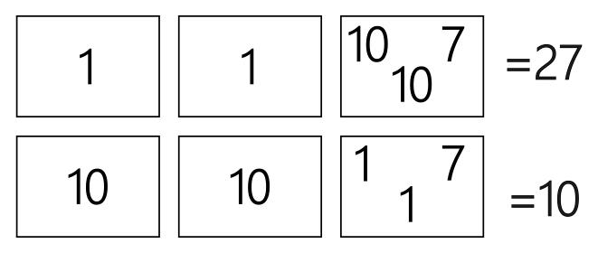

图 4 两种不同的分配方式，整体测试时间也不同。Fig. 4 Two different assignments with different overall test times.

为了让问题更有意思，某些测试可能属于一个*组*，而我们希望同组的所有测试都在同一台服务器上运行。To make the problem more interesting, some tests may belong to a *group*, and we want all tests in the same group to run on the same server.

这类问题很难用普通编程语言求解，却很容易用逻辑表达，并让我们能够用一类新的工具来求解。This kind of problem is difficult to solve in a normal programming language, but it’s very easy to express logically, and lets us use a new class of tools to solve them.

## 逻辑Logic

通常，我们使用逻辑，是因为它比一般编程语言的表达能力更强。但这次，我们会稍有不同，用一种表达能力*更弱*的方式写出问题。相信我，这样做是有原因的。Normally, we use logic because it is more expressive than the average programming language. But this time we’ll do things a little differently and write our problem in a *less* expressive way. Trust me, I have a reason for doing things this way.

首先，如何表示测试时间？用一个 `test_times` 数组：`test_times[2]` 是*第二个*测试所需的时间。*与本书其他地方都不同*，这里的索引从 1 开始。First, how can we represent the test times? With a `test_times` array: `test_times[2]` is the time the *second* test takes. *Unlike everything else in this book*, this is 1-indexed.

接下来，如何表示服务器分配？如果规定用整数表示服务器（就像测试一样），那么*也*可以用数组表示服务器。`assignment[5] == 2` 表示测试 T5 被分配给服务器 2。Next, how can we represent the server assignments? If we say our servers are represented by integers (just like our tests) we can *also* represent the server with an array. `assignment[5] == 2` means that test T5 is assigned to server 2.

最后，可以用——你猜对了——数组来表示组。`group[1] == 2` 表示测试 T1 属于组 2。我们还规定不存在“组 0”；`group[2] == 0` 则表示 T2 不属于任何组。Finally, we can represent the groups as- you guessed it- an array. `group[1] == 2` means that test T1 is in group 2. We’ll also say there’s no “group 0”; `group[2] == 0` instead means that T2 doesn’t belong to any group.

注意，其中两个数组是“常量”：`test_times` 和 `groups` 由外部因素决定。只有 `assignment` 是“变量”：我们要寻找它满足约束的取值。Notice that two of those arrays are “constants”: the `test_times` and the `groups` are fixed by outside forces. Only `assignment` is a “variable”: we are looking to find its value that satisfies our constraints.

注Note

这里“约束”的含义与数据库一章中的“约束”不同。学科不同，词源也不同。如果我*同时*用逻辑分析数据库和这类问题，大概会把数据库约束叫作“规则”之类的名称。This is a different meaning of “constraint” than the “constraints” in the database chapter. Different disciplines, different etymologies. If I was logically analyzing *both* databases and this class of problems at the same time, I’d probably call the database constraints “rules” or something.

分组约束很简单：The group constraint is simple:

```
constraint GroupsHaveSameAssignment =
  all t1, t2: 1..=T:
    (group[t1] == group[t2] &&
     group[t1] != 0)
    => assignment[t1] == assignment[t2]
```

（留给读者的练习：为什么不需要检查 `group[t2] != 0`？）(Exercise for the student: why don’t we need to check `group[t2] != 0`?)

一台服务器所需的总时间，是分配给它的所有测试耗时的总和。The total time a server takes is the sum of all tests assigned to it.

```
total_time(s: 1..=S) =
  sum({
    test_times[t]
    for t in 1..T:
      assigment[t] == s
    })
```

因此，我们的目标是最小化最大的 `total_time`。Our goal, then, is to minimize the maximum `total_time`.

```
minimize max({total_time(s) for s in 1..=S})
```

## 实践：求解器In Practice: Solvers

既然已经用逻辑表示了问题，该如何求解呢？Now that we have the problem logically represented, how do we solve it?

当然是使用求解器！By using a solver, of course!

*求解器*是一种专门寻找这类问题答案的工具。求解器种类繁多，有的针对特定问题，有的用途更广。A *solver* is a special tool that finds answers to problems like ours. There are all sorts of solvers, some for special problems, some more general purpose.

我们将使用 [Minizinc](https://www.minizinc.org/) [https://www.minizinc.org/]，纯粹是因为[可以免费在线试用](https://play.minizinc.dev) [https://play.minizinc.dev]。你也可以下载到本地运行，这在多数机器上会更快。下面是 MiniZinc 中的解法：We will use [Minizinc](https://www.minizinc.org/) [https://www.minizinc.org/], purely because [you can try it free online](https://play.minizinc.dev) [https://play.minizinc.dev]. You can also download it and run it locally, which will be faster on most machines. Here is the solution in MiniZinc:

代码清单 7 （Minizinc）Listing 7 (Minizinc)

```
int: T = 10; % number tests
int: S = 2; % number servers
set of int: Servers = 1..S;
set of int: Tests = 1..T;

array[Tests] of int: test_times = [5, 6, 3, 7, 4, 3, 4, 4, 6, 9];
array[Tests] of int: group = [0, 0, 1, 1, 2, 0, 1, 0, 0, 2];
array[Tests] of var Servers: assignment;

function var int: total_time(var int: s) =
  sum([test_times[t] | t in Tests where assignment[t] = s]);

constraint forall (t1, t2 in Tests)
  (group[t1] = group[t2] /\ group[t1] != 0
    -> assignment[t1] = assignment[t2]);

function var int: num_assigned(var int: s) =
  count(assignment, s);

constraint forall (s1, s2 in 1..S)
  (abs(count(assignment, s1) - count(assignment, s2)) <= 1);

solve minimize max([total_time(s) | s in 1..S]);

output [
    "Server \(s): \([t | t in Tests where assignment[t] = s])"
       ++ " (\(sum([test_times[t] | t in Tests
                  where assignment[t] = s])))\n"
    | s in 1..S
];
```

与我们见过的其他工具一样，MiniZinc 有自己的逻辑表达式语法，与我们的记法不同。我随意选取了 `test_times` 和 `group` 的值；MiniZinc 也可以从数据文件中读取参数。我们必须把 `assignment` 标为 `var`，这样 MiniZinc 才知道它可以控制这个值。As with the other tools we have seen, MiniZinc uses its own syntax for logical expressions that is different from ours. I picked arbitrary values for `test_times` and `group`; MiniZinc can also read parameters in from a data file. We have to mark `assignment` as a `var` so MiniZinc knows it can control that.

运行后，会输出越来越好的结果，直到找到最短时间 26。如果 MiniZinc 找不到任何有效解，就会输出 `UNSATISFIABLE`。Running this will output progressively better results, until it finds a minimum time of 26. If MiniZinc can’t find any valid solution it will output `UNSATISFIABLE`.

求解器让我们很容易加入更有趣的约束。例如，可以加一条约束，要求每台服务器上的测试数量大致相同：Solvers make it easy to add more interesting constraints. For example, we can add a constraint that each server must have about the same number of tests:

```
constraint forall (s1, s2 in 1..S)
  (abs(count(assignment, s1) - count(assignment, s2)) <= 1);
```

上述问题称为“装箱问题”，是这类求解器最常见的用例之一。只有十个测试时，找到最优解并不太重要，但更真实的工作负载可能有 10,000 个测试！这时求解器就真能替企业省钱了。The above is known as a “bin-packing problem”, which is one of the most popular use-cases for these solvers. Finding the optimium solution doesn’t matter too much with ten tests, but a more realistic workload might be 10,000 tests! That’s when a solver can really save a business money.

### 速度与表达能力Speed vs Expressiveness

使用 MiniZinc，也解释了为什么我们必须以表达能力如此有限的格式保存参数。MiniZinc 不支持字符串、结构体、数组的数组，也不支持我们在编程语言中习以为常的那些便利功能。即使有这些限制，MiniZinc 的表达能力仍然比许多其他求解器更强。这是因为求解器必须*快*。对问题中的变量和约束施加的限制越多，求解器就越能专门化，从而越快地求解能够表达的问题。Our use of MiniZinc explains why we had to store our parameters in such an inexpressive format. MiniZinc does not support strings, structures, arrays of arrays, or any of the affordances we’re used to in programming languages. Even with its restrictions, MiniZinc is still more expressive than many other solvers. This because solvers need to be *fast*. The more restrictions we place on the variables and constraints in our problems, the more specialized our solver can be, and in turn the faster we can solve expressible problems.

例如，*线性规划求解器*的值只能是数值，而且只能计算形如 `a*x1 + b*x2 + ...` 的表达式。但专用线性求解器的运行速度可能远高于求解一般的 MiniZinc 问题。For example, a *linear programming solver* has only numbers for values, and can only compute expressions of the form `a*x1 + b*x2 + ...`. But dedicated linear solvers can run much faster than a general MiniZinc problem.

[[既然如此，如果可行，为什么不把 MiniZinc 问题转换成线性规划问题呢？事实上，它做的正是这件事。MiniZinc 是一种用于表达约束问题的高层、工具无关的语言，它会尝试把问题“编译”为更简单的形式。]][[So why not convert a MiniZinc problem into a linear programming one, if possible? In fact, that’s exactly what it does. MiniZinc is a high-level, tool-agnostic language for expressing constraint problems, which it tries to “compile” into simpler forms.]]

问题和求解器的子类多得令人眼花缭乱，但其中两类尤其值得关注，它们展示了速度与表达能力这条光谱两端可能存在的事物。There’s a dizzying array of subclasses of problems and solvers, but two are of particular interest, showing what can exist on the very ends of the speed/expressiveness spectrum.

注Note

有些类别的问题足够有价值，值得开发专用工具。[Google OR-tools](https://developers.google.com/optimization) [https://developers.google.com/optimization] 是最流行的求解器之一，内含针对调度、车辆路径规划、装箱等问题的专用求解器。Some classes of problems are valuable enough for specialist tools. [Google OR-tools](https://developers.google.com/optimization) [https://developers.google.com/optimization] is one of the most popular solvers available, and has specialized solvers for problems like scheduling, vehicle routing, and bin packing.

### SAT 求解器SAT Solvers

如果我们*只*关心速度，那么能构造出的最精简、最基本的约束语言是什么样的？If *all* we cared about was speed, what is the most stripped down, barebones constraint language we can make?

把*一切*都移除，就能得到它。没有字符串、数组、函数，也没有数值。每个变量不是“真”就是“假”。如果要知道测试 7 是否分配给服务器 3，就创建一个布尔变量来追踪这件事。当测试 7 分配给服务器 3 时，`a73` 为真；未分配给它时，`!a73` 为真。但这样一来，我们还需要 `a72`、`a71`、`a63`……We get it by removing *everything*. No strings, arrays, no functions, no numbers. Every variable is “true” or “false”. If we want to see whether test 7 is to server 3, we make a boolean variable tracking that. `a73` is true when test 7 is assigned to server 3, `!a73` when it isn’t. But then we’ll also need `a72`, `a71`, `a63`…

接着，需要一个约束来表示“每个测试至少分配给一台服务器”。写出这个约束的*最简单*方式是什么？大概像这样：Then we’ll need a constraint saying “each test is assigned to at least one server.” What’s the *simplest possible* way to write that constraint? Probably something like this:

```
(a11 || a12 || a13 ...) &&
(a21 || a22 || a23 ...) &&
(a31 || a32 || a33 ...) &&
```

（这种“多个或式的与”通常称为*合取范式*，简称 CNF。）(This “AND of ORs” is conventionally called *Conjunctive Normal Form* (CNF).)

看起来不错。但没有任何东西阻止 `a11` 和 `a12` 同时为真：测试 1 被分配给了两台不同的服务器！因此，我们还需要声明：“如果测试 1 分配给了 1，就不能同时分配给 2 或 3”：Looks good. But there’s nothing stopping `a11` and `a12` from both being true at the same time: test 1 is assigned to two different servers! So we also need to say “if test 1 is assigned to 1, it cannot also be assigned to 2 or 3”:

```
(a11 && !a12 && !a13 ...) ||
(!a11 && a12 && !a13 ...) ||
```

但这样一来，求解器必须*既*理解“多个或式的与”，*又*理解“多个与式的或”。表达能力太强了！最好设法将其改写成 CNF：But now our solver has to understand *both* “AND of ORs” *and* “OR of ANDs”. That’s too much expressivity! Better find a way to rewrite that in CNF:

```
(!a11 || !a12) &&
(!a11 || !a13) &&
(!a12 || !a13) &&
...
```

练习Exercise

解释为什么这意味着测试 1 不能分配给两台不同的服务器。Explain why this means test 1 can’t be assigned to two different servers.

解答Solution

求解这种形式的问题的工具称为 *SAT 求解器*，名称来自“布尔可满足性”（Boolean SATisfiability）。语法或许显得受限，但能转换成 SAT 问题的问题数量多得惊人。作为回报，SAT 求解器是世界上最快的一类求解器，处理数 GB 大小的问题是家常便饭。Solvers for problems of this form are called *SAT solvers*, after “Boolean SATisfiability”. The syntax may seem constrained, but a surprisingly large number of problems can be transformed into SAT problems. And in return, SAT solvers are some of the fastest solvers in the world, routinely handling problems gigabytes in size.

注Note

也许可以加一道把标签规则转换为 SAT 的练习。无需真的把标签做成参数，只需用子句替代即可。Maybe an exercise on converting the tag rule to SAT. We don’t need to actually make the tags parameters, just replace them with clauses.

注Note

所有能由 SAT 求解器求解的问题组成的集合，就是因 `P vs NP` 而闻名的“NP 复杂度类”。NP 被认为是“难处理的”，意思是我们没有高效算法来求解这一类中的所有问题。实际遇到的*大多数* SAT 问题都“表现良好”，能很快求解。但也有很小的 SAT 问题，穷尽人的一生也求不出来。The set of all problems solvable by a SAT solver is the “NP complexity class”, of `P vs NP` fame. NP is considered “intractable”, meaning we do not have efficient algorithms to solve all of the problems in the class. *Most* SAT problems seen in the wild are “well-behaved” and can be solved quickly. But you can also find small SAT problems that can’t be solved in a human lifetime.

因此，许多人使用能接受表达能力丰富的形式并将其转换为 SAT 的工具。你可以把 SAT 想象成一种低层“汇编”语言，其他工具把问题“编译”成它。Alloy 内部就使用 SAT 求解器。For this reason, many people use tools that take expressive forms and convert them into SAT. You can think of SAT as a low level “assembly” language that other tools “compile” to. Alloy uses a SAT solver internally.

### SMT 求解SMT

在表达能力的另一端，是 SMT，即*可满足性模理论*（Satisfiability Modulo Theories）求解器。其他求解器针对受限类别的数学问题，而 SMT 求解器很灵活，能处理多种不同问题。举一个例子，我们可以用它逆向分析随机数生成器（RNG）。On the other end of expressivity, we have SMT, or *Satisfiability Modulo Theories* solver. While other solvers target a restricted category of math problem, SMT solvers are flexible and handle a wide range of different problems. As just one example, we can use it to reverse engineer a random number generator (RNG).

一种较早的随机数生成器是*线性同余生成器*，简称 LCG。从种子值 `x_0` 开始，每个后续值由 `x_n+1 = (a*x_n + c) % m` 确定，其中 `(a, c, m)` 都是固定值。给定一个序列和 `m`，能否恢复出 `(a, c)`？目前最流行的 SMT 工具是 [Z3](https://microsoft.github.io/z3guide/) [https://microsoft.github.io/z3guide/]。One old type of random number generator is the *Linear Congruential Generator*, or LCG. Starting with a seed value `x_0`, each next value is determined by `x_n+1 = (a*x_n + c) % m`, where `(a, c, m)` are all fixed values. Given a sequence and `m`, can we recover `(a, c)`? The most popular SMT in use is [Z3](https://microsoft.github.io/z3guide/) [https://microsoft.github.io/z3guide/].

代码清单 8 （Python）Listing 8 (Python)

```python
# requires `pip install z3-solver`
from z3 import *
solver = Solver()

modulus = eval(input("Enter modulus: "))
sequence = eval(input("Enter sequence: ")) # Separate with commas

a = Int('a')
c = Int('c')

solver.add(a >= 0, a < modulus)
solver.add(c >= 0, c < modulus)

for i in range(len(sequence) - 1):
    solver.add(sequence[i+1] == c + (a * sequence[i]) % modulus)

if solver.check() == sat:
    model = solver.model()
    print(f"a = {model[a].as_long()}")
    print(f"c = {model[c].as_long()}")
else:
    print("Could not find parameters")
```

运行代码时的情况如下：Here is what it looks like to run the code:

```
Enter modulus: 2**31
Enter sequence: 4096, 618876929, 113892918, 1048278319
a = 22695477
c = 1
```

SMT 的表达能力甚至超过“通用”约束求解器，但代价是*完备性*。前面看到的所有约束问题都是*可判定的*，也就是说，求解器要么一定返回一个值，要么一定告诉我们无解。SMT 求解器还可能返回“UNKNOWN”，表示它连问题到底有没有解都无法确定。随着时间推移，SMT 求解器越来越擅长寻找解，但它们永远不可能解决所有问题。这就是表达能力的代价。SMT are more expressive than even “generic” constraint solvers, but that expressiveness comes at a price of *completeness*. All of the prior constraint problems we looked at were *decidable*, meaning the solver will either definitely return a value or definitely tell us there is no solution. SMT solvers can also return “UNKNOWN”, meaning the solver couldn’t figure if the problem is even solvable or not. Over time, SMT solvers are getting better and better at finding solutions, but they will never be able to solve all problems. Such is the price of expressiveness.

尽管如此，SMT 求解器凭借灵活性极受欢迎，用途多种多样。它们可以[破解密码学原语](https://github.com/kste/cryptosmt) [https://github.com/kste/cryptosmt]、[逆向分析已编译的二进制文件](https://docs.angr.io/en/latest/core-concepts/solver.html) [https://docs.angr.io/en/latest/core-concepts/solver.html]、[找出防火墙规则集之间的差异](https://github.com/Z3Prover/FirewallChecker) [https://github.com/Z3Prover/FirewallChecker]，以及[从规约合成代码](https://cseweb.ucsd.edu/~npolikarpova/publications/popl20.pdf) [https://cseweb.ucsd.edu/~npolikarpova/publications/popl20.pdf]。它们还是多数定理证明和形式化验证工作的驱动引擎。Dafny 用 SMT 求解器验证代码，一款研究性质的 TLA+ 模型检查器也是如此。Nonetheless, SMT solvers are incredibly popular for their flexibility and see all sorts of different use cases. They can [crack cryptographic primitives](https://github.com/kste/cryptosmt) [https://github.com/kste/cryptosmt], [reverse engineer compiled binaries](https://docs.angr.io/en/latest/core-concepts/solver.html) [https://docs.angr.io/en/latest/core-concepts/solver.html], [find differences in firewall rulesets](https://github.com/Z3Prover/FirewallChecker) [https://github.com/Z3Prover/FirewallChecker], and [synthesize code from specifications](https://cseweb.ucsd.edu/~npolikarpova/publications/popl20.pdf) [https://cseweb.ucsd.edu/~npolikarpova/publications/popl20.pdf]. They are also the engine that powers most work in theorem proving and formal verification. Dafny uses an SMT solver to verify code, and one research model checker for TLA+ does too.

注Note

求解器（判断是否存在解）怎么能驱动验证器（检查某个性质是否始终成立）呢？很简单，利用量词对偶性即可。如果性质是 `all x: P(x)`，就让求解器满足 `!P(x)`。如果求解器找不到任何解，那么 `!(some x: !P(x))` 就成立，而它与原性质等价。How can a solver (which finds if solutions exist) power a verifier (which checks that a property always holds)? Easy, just exploit quantifier duality. If the property is `all x: P(x)`, then ask the solver to satisfy `!P(x)`. If the solver can’t find any solutions, then `!(some x: !P(x))` holds, which is equivalent to our property.

## 该用哪一种？Which to use?

面对所有这些选项，该选择哪种求解器？这取决于很多因素，但我可以给出一些非常概括的经验法则。So given all of the options, which solver is the right one to pick? This depends on a lot of factors, but I can provide some very general heuristics.

首先，多数程序员不太可能直接使用 SAT。SAT 又快又强大，但要以最优方式表示问题，并把 SAT 的解解释成原问题的解，都需要很高的技巧。因此，SAT 求解器的主要用户是这样的人：1) 绝对需要把问题的性能推到极致，或者 2) 正在构建更高层的工具。我们更可能使用某种内部以 SAT 求解器作为实现一部分的工具。First of all, most programmers are unlikely to directly use SAT. SAT is fast and powerful but it takes a lot of skill to represent problems in an optimal way, and to interpret a SAT solution to a problem. For these reasons, the main users of SAT solvers are people who 1) absolutely need the maximum possible performance on their problem, or 2) are building higher-level tools. We are more likely to use a tool that uses a SAT solver as part of its implementation.

其次，合适的求解器取决于目标的性质：是*满足约束*，还是*优化*？问题的解很少，而且找到任意一个都可以时，SMT 求解器就是合适的工具。问题有许多有效解，但某些解比其他解更优时，其他求解器才是合适的工具。粗略来说，大多数“满足约束”问题偏向技术或“软件工程”，而大多数优化问题偏向业务或“运筹学”：排班、车辆路径规划、制造优化、资源分配等。After that, the right solver depends on the nature of our goal: is it *satisfaction* or *optimization*? SMT solvers are the right tool when the problem has very few solutions and any one will do. Other solvers are the right tool when the problem has many valid solutions, but some are more optimal than others. As a rough rule, most “satisfaction” problems are technical/”software engineering”-oriented, while most optimization problems are business/”operations research”-oriented: shift scheduling, vehicle routing, manufacturing optimization, resource allocation, etc.

如果 SMT 是合适的选择，就默认使用 Z3。在所有 SMT 求解器中，它得到的支持最广，与最多的语言集成，文档也最详尽。If SMT is the right choice, then we default to Z3. It is most widely supported, has integrations with the most languages, and has the most thorough documentation of any SMT solver.

如果应该选用优化求解器，一般做法是找到能够完整表达问题、但*表达能力最弱*的那类工具，因为它会最快。[[ILP、LP、Simplex、MIP 等。]] 工具和类别多得令人眼花缭乱。MiniZinc 和 Google 的 [OR-Tools](https://developers.google.com/optimization) [https://developers.google.com/optimization] 是还不错的起点。If an optimization solver is the right choice, the general approach is to find the *least expressive* class of tools that totally expresses the problem, as that will be the fastest. [[ILP, LP, Simplex, MIP, etc]]. There’s a dizzying plethora of different tools and classes. A decent enough starting point is MiniZinc and Google’s [OR-Tools](https://developers.google.com/optimization) [https://developers.google.com/optimization].

## 小结Summary

- 有些类别的问题很难以程序方式表达，却能用求解器高效求解。There are classes of problems that are difficult to express programmatically, but are solved efficiently with solvers.
- 求解器表达约束问题的便利程度与求解速度之间存在取舍。There is a tradeoff between how easily a solver can express constraint problems and how quickly it can solve them.
- SAT 求解器速度快，但表达能力很弱。它们是许多高层软件中的核心低层组件。SAT solvers are fast but very inexpressive. They are a core low-level component in a lot of higher-level software.
- SMT 求解器表达能力强，但不完备。它们也被广泛使用，既可直接使用，也可作为低层组件。SMT solvers are expressive but incomplete. They are also widely used, both directly and as low-level components.
- SAT 和 SMT 求解器主要用于“满足约束”问题，其他求解器则主要用于“优化”问题。SAT and SMT solvers are primarily used for “satisfaction” problems, while other solvers are primarily used for “optimization” problems.

下一章将介绍最名副其实的“逻辑编程”。The next chapter is about the most literal kind of “logic programming”.

### 延伸阅读Further Reading

- Hakank 的[常见约束编程问题](http://www.hakank.org/common_cp_models/) [http://www.hakank.org/common_cp_models/]和 [MiniZinc 页面](http://www.hakank.org/minizinc/) [http://www.hakank.org/minizinc/]Hakank’s [common constraint programming problems](http://www.hakank.org/common_cp_models/) [http://www.hakank.org/common_cp_models/] and [MiniZinc page](http://www.hakank.org/minizinc/) [http://www.hakank.org/minizinc/]
- SAT/SMT 实例教程：https://smt.st/main.htmlSAT/SMT by Example: https://smt.st/main.html
- Z3 编程：https://theory.stanford.edu/~nikolaj/programmingz3.htmlProgramming Z3: https://theory.stanford.edu/~nikolaj/programmingz3.html

# 逻辑编程Logic Programming

在一本叫《程序员的逻辑学》的书里，我竟然成功地写了九十页都没有提起“逻辑编程”。我觉得自己值得一枚奖章。In a book called “Logic for Programmers” I’ve somehow managed to not bring up “logic programming” for ninety pages. I feel like I deserve a medal.

*逻辑编程*（LP）是一种独立的编程范式，就像命令式和函数式编程一样。最著名的逻辑编程语言叫作“Prolog”。Prolog 最初诞生于 1970 年代，此后衍生出许多不同变体。我们将使用“SWI-Prolog”变体，你可以在 https://swish.swi-prolog.org/ 在线试用。受篇幅所限，本章只能比其他章节更侧重于概览。*Logic programming* (LP) is a distinct paradigm of programming, like imperative and functional are. The most famous logic programming language is called “Prolog”. Prolog was first created in 1970s and since then has split off into many different variants. We will use the “SWI-Prolog” variant, which you can try online at https://swish.swi-prolog.org/. By necessity, this chapter will be even more of a broad overview than the other chapters.

## Prolog 语言Prolog

Prolog 程序有三种基本构件：There are three basic building blocks of a Prolog program:

1. *原子*是以小写字母开头的值标识符（`bread`、`flour`）。它们是不含变量的符号：`bread` 只等于 `bread`，不等于其他任何东西。*Atoms* are value identifiers that start with a lower-case letter (`bread`, `flour`). These are ground symbols: `bread` is equal to `bread` and nothing else.
2. *变量*是以大写字母开头的标识符（`X`、`Abc`）。Prolog 程序的最终目标是把变量“合一”到能使谓词为真的值。*Variables* are identifiers that start with a capital (`X`, `Abc`). The ultimate goal of a Prolog program is to “unify” variables to values that would make predicates true.
3. 谓词，可以对特定的原子为真，也可以对满足某个条件的原子为真。这两种谓词分别称为*事实*和*规则*。Predicates, which can be true for specific atoms, or for atoms that pass a condition. These predicates are called *facts* and *rules*, respectively.

```
% comments start with %
ingredient(bread, flour). % don't forget the period!
ingredient(bread, water).
```

这定义了事实 `ingredient()`，并规定当第一个参数为 `bread`，第二个参数为 `flour` 或 `water` 时，它为真。现在，如果我用变量调用 `ingredient`，就是在*请求* Prolog 引擎找出一个能使表达式为真的值。This defines the fact `ingredient()` and determines it’s true if the first parameter is `bread` and the second is `flour` or `water`. Now if I call `ingredient` with a variable, I am *asking* the Prolog engine to find a value that makes my expression true.

```
ingredient(X, flour).
X = bread % result

ingredient(X, potatoes).
false % no possible X
```

这直接对应 `some` 量词：若 `some x: ingredient(x, flour)`，则 `ingredient(X, flour)` 为真。如果有多个值满足表达式，Prolog 会逐个返回可能的值。This maps directly to the `some` quantifier: `ingredient(X, flour)` is true if `some x: ingredient(x, flour)`. If multiple values satisfy the expression, then Prolog will return possible values one at a time.

表示食谱并不是常见的编程任务，所以我们继续看一个更实际的例子。很少有人在工作中处理食谱，但几乎人人都使用版本控制，而提交之间的关系可以直接用事实表达：Representing recipes are not a common programming task, so let us continue with a more practical example. Few people work with recipes in their job, but almost everyone uses version control, and the relationships between commits is directly expressible in facts:

```
parent(a0, a1).
parent(a1, a2).
parent(a2, a3).
parent(a3, a4).
parent(a4, a5).
parent(a1, b1).
parent(b1, b2).
parent(b2, a4).
parent(b2, b3).
```

这表示图 5中的提交图。This represents the commit graph in Fig. 5.

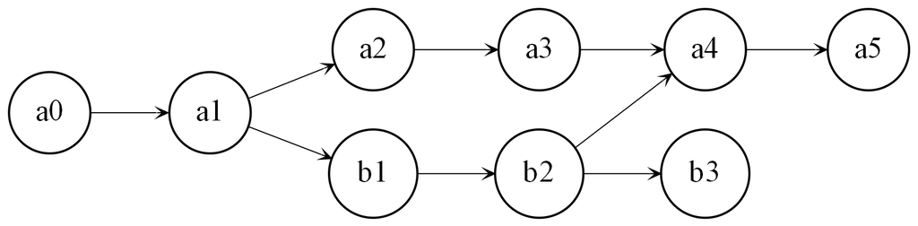

图 5 提交关系图。Fig. 5 A graph of commits.

有了一组事实，就可以加入“规则”，也就是主体较复杂的谓词。例如，“合并提交”是有两个不同父提交的提交。Once we have a collection of facts, we can then add “rules”, or predicates with complex bodies. For example, a “merge commit” is one that has two different parents.

```
mergecommit(C) :-
    parent(P1, C),
    parent(P2, C),
    \+ (P1 = P2). % \+ is 'not'
```

```
?- mergecommit(C).
C = a4.
```

规则可以有多个定义，此时只要*任意一条*规则为真，谓词就为真。这使递归陈述很容易表达，例如：“如果 A 是 C 的父提交，或者是 C 的某个祖先提交的父提交，那么 A 就是 C 的祖先提交。”Rules can have multiple definitions, in which case the predicate is true if *any* rule is true. This makes it easy to express recursive statements, like “A is the ancestor of C if it is a parent of C or the parent of an ancestor of C.”

```
ancestor(A, Commit) :- parent(A, Commit).
ancestor(A, Commit) :-
    parent(A, Y),
    ancestor(Y, Commit).
```

有了这些，我们就能表达复杂查询，例如“提交 A 的祖先中，不是提交 B 的祖先的那些提交”：With this, we can express complex queries, like “ancestors of commit A that are not ancestors of commit B”:

[output not shown]

注Note

Prolog 使用“回溯”算法寻找解。因此，它不保证返回的所有解都互不重复。Prolog uses a “backtracking” algorithm to find solutions. As such, it does not guarantee that all solutions are unique.

LP 语言是通用语言，能做命令式或函数式语言能做的一切。问题在于，这种范式在哪些方面比其他编程范式做得*更好*？曾经，答案是“人工智能”，逻辑编程在很大程度上被视为专家系统和自然语言处理的最佳工具。如今，这一地位已大多被机器学习和大语言模型等统计方法取代。LP languages are general-purpose languages and can do everything that can be done in an imperative or functional language. The question is what can this paradigm do *better* than other programming paradigms? At one time, the answer was “artificial intelligence”, and logic programming was largely seen as the best tool for expert systems and natural language processing. This niche has been largely superceded by statistical methods like machine learning and large language models.

但它仍有用武之地。本章末尾的“延伸阅读”列出了一些实际应用案例。而且在某些细分领域，逻辑编程仍普遍是首选方法。But there are still places where it sees use. Some specific use cases in the wild are listed in the “Further Reading” at the end of this chapter. And there are still some niches where logic programming is broadly the preferred approach.

## 演绎数据库Deductive Databases

*演绎数据库*是另一种形式的数据库。它不把数据存储在表中，而是存储为事实和规则。此时，逻辑编程纯粹成了查询工具，而非通用编程手段。前面的提交模型可以说就是一个演绎数据库。要给提交加入新信息，只需增加新事实：A *deductive database* is an alternate form of database. Instead of storing data in tables, deductive databases store data as facts and rules. Logic programming then becomes purely a tool for querying, as opposed to general programming. Our previous commit model is arguably a deductive database. Adding new information to the commits is as easy as adding new facts:

```
% commit(id, author, [files_changed])
% written this way to be more compact
commit(a0, alice, [file(f1), file(f2), testfile(f2)]).
commit(a1, bob, [file(f1), file(f3), testfile(f1)]).
commit(a2, eve, [file(f1), file(f2), testfile(f1), testfile(f2)]).

% commit_author_file
caf(C, A, F) :-
    commit(C, A, Files),
    member(F, Files).
```

`file(f1)` 是 Prolog 的*复合项*，相当于其他语言中的结构体或积类型。它可以用于[[模式匹配]]：`caf(_, alice, testfile(X))` 会检索 Alice 修改过的所有测试文件（但不包括普通文件）。`file(f1)` is a prolog *compound term*, equivalent to a struct or product type in other languages. It can be used in [[pattern matching]]: `caf(_, alice, testfile(X))` will retrieve any testing file (but not regular file) that Alice modified.

[[在论文*《基于证据的故障预测》*中，*Nagappan 等人*认为，文件变更的模式可以预测这些文件出现缺陷的可能性。提交次数更多、即“变更频繁”的文件，更可能存在潜在缺陷。让我们实现两条规则，用来提示某个文件更可能存在缺陷：]][[In their paper *Evidence Based Failure Prediction*, *Nagappan et al* argue that patterns in how we change files can predict the likelihood of bugs in those files. Files with more commits, “churn”, are more likely to have latent bugs. Let’s implement two rules that suggest a file is more likely to have bugs:]]

1. 当一个文件至少被三次不同提交修改，且这些提交来自不同作者时，`high_churn` 为真。在我们的模型中，只有 `file(f1)` 符合。`high_churn` is true if a file was changed by at least three different commits with different authors. In our model, this applies to just `file(f1)`.
2. 当一个文件在某次提交中被修改，而对应的测试**没有**被修改时，`untested_commit` 为真。这项检查*不应*适用于测试文件。在我们的模型中，`file(f1)` 和 `file(f3)` 符合。`untested_commit` is true if a file was changed in a commit, and its corresponding test was **not** changed. This check should *not* apply to test files. In our model, this applies to `file(f1)` and `file(f3)`.

```
high_churn(File) :-
    caf(_, A1, File), caf(_, A2, File), caf(_, A3, File),
    A1 @< A2, A2 @< A3. % @< = ordering on atoms

untested_commit(file(File)) :-
    commit(_, _, Files),
    member(file(File), Files),
    \+ member(testfile(File), Files).
```

我们可以更优雅地编写 `high_churn`（也不必硬编码作者数量），但那需要更高级的 Prolog 技巧。在此基础上，可以将每个文件映射到它未通过的检查数量。We can write `high_churn` more elegantly (and not hardcode in the number of authors), but that requires more sophisticated Prolog technique. From here, we can map each file to the number of checks it fails.

```
% fails_check just calls the check on the file
% Added for descriptivity
fails_check(File, Check) :- call(Check, File).

checks_failed(_, [], []).
checks_failed(File, [Check|Checks], Failed) :-
  checks_failed(File, Checks, Failed),
  \+ fails_check(File, Check).

checks_failed(File, [Check|Checks], [Check|Failed]) :-
  checks_failed(File, Checks, Failed),
  fails_check(File, Check).

checks_failed(File, Failed) :-
  checks_failed(File, [high_churn, untested_commit], Failed).
```

如果只想得到每个文件未通过的检查数，可以再写一个辅助运算符。If we just want the count of the checks each file failed, we can write another helper operator.

```
file_suspicion(File, Suspicion) :-
    checks_failed(File, Failed),
    length(Failed, Suspicion).
```

实践中，Prolog 很少用作演绎数据库的查询语言，原因有二：Prolog 无法嵌入其他语言，而且 Prolog 查询不保证终止。主要使用的语言是 *Datalog*，这是 Prolog 中“表现良好”、没有这些问题的一个子集。例如，[Datomic](https://www.datomic.com/) [https://www.datomic.com/] 使用 Datalog 查询，但将其作为 DSL 嵌入 Clojure。In practice, Prolog is rarely used as the query language for deductive databases for two reasons: Prolog cannot be embedded in other languages, and Prolog queries are not guaranteed to terminate. The main language is instead *Datalog*, a “well-behaved” subset of Prolog without these issues. [Datomic](https://www.datomic.com/) [https://www.datomic.com/], for example, uses datalog for queries, but embeds it as a DSL in Clojure.

## 规划Planning

有一类 AI 问题（截至 2025 年）无法用统计方法处理：*规划*。给定起始状态、一组有效动作和目标状态，什么样的动作序列能让我们到达目标状态？There is one class of AI problems that (as of 2025) cannot be handled with statistical approaches: *planning*. Given a starting state, a set of valid actions, and a goal state, what sequence of actions should get us to the goal state?

考虑如下情形：有一组在线服务器，需要进行两次操作系统更新。我们只能升级离线服务器，而且必须确保始终至少有一台服务器在线。可以进一步抽象服务器，让它只包含一个名称、一个表示开关状态的布尔值，以及一个数值版本号。Consider the following situation: we have a set of online servers that need two OS updates. We can only upgrade a server that is offline, and we need to make sure that we always have at least one server online. We can further abstract the servers so that they consist only of a name, a boolean on/off state, and a numerical version.

这种情况下，两台服务器的起始状态是集合 `{(s1, on, 1), (s2, on, 1)`，目标状态是 `{(s1, on, 3), (s2, on, 3)`，有两种可能的动作：In this case, the starting state for two servers would be the set `{(s1, on, 1), (s2, on, 1)`, the goal state would be `{(s1, on, 3), (s2, on, 3)`, and there would be two possible actions:

- 切换一台服务器的状态，除非这样会导致所有服务器都关闭Toggle the state of a server, unless doing so would leave all servers off
- 将一台关闭的服务器的版本号递增。Increment the version of an off server.

Prolog 本身不支持规划，但我个人最喜欢的逻辑语言 [Picat](http://picat-lang.org/) [http://picat-lang.org/] 支持。下面是 Picat 中的规划问题：Prolog does not natively support planning, but my personal favorite logic language, [Picat](http://picat-lang.org/) [http://picat-lang.org/], does. Here is the planning problem in Picat:

代码清单 9 （Picat）Listing 9 (Picat)

```
import planner, math, util.

final(N) =>
  foreach($server(_, State, Version) in N)
    State = on, Version = 3
  end.

cost(State) = 1.

% At least one server online
valid(State) => member($server(_, on, _), State).

action(From, To, Action, Cost) ?=> % toggle state
  member(X, From),
  (
   Action = $off(X[1]), To = replace(From, X, X.replace(on, off));
   Action = $on(X[1]), To = replace(From, X, X.replace(off, on))
  ),
  valid(To),
  Cost = cost(From).

action(From, To, Action, Cost) => % increment version
  member(X, From),
  X = $server(Name, off, Version),
  To = replace(From, X, X.replace_at(3, Version+1)),
  Action = $upgrade(Name),
  Cost = cost(From).

main =>
  Start = [$server(s1, on, 1), $server(s2, on, 1)],
  best_plan(Start, Plan, Cost),
  writeln(Plan), writeln(Cost).
```

运行后得到：Running this gives me:

```
[off(s1), upgrade(s1), upgrade(s1), on(s1),
 off(s2), upgrade(s2), upgrade(s2), on(s2)]
 8
```

我在代码中让第一项输出表示解决问题的步骤列表。第二项输出是计划的“成本”，Picat 会自动将其最小化。在这里，每个动作的成本为 1，意味着总成本就是计划中的步骤数。I coded the first output to be the list of steps that solves our problems. The second output is the “cost” of the plan, which Picat will automatically minimize. In this case, each action has cost 1, meaning to total cost is just the number of steps in our plan.

规划器能自动找到解决问题的步骤序列，还能最小化成本。在这个例子中，“成本”只是步骤数，因此得到一个八步解。为了展示其能力，我们可以在多台在线服务器版本不同时加入额外惩罚，数值等于 `(MaxVersion - MinVersion)` 的立方。The planner is automatically able to find a sequence of steps that solves our problem. It can also minimize cost. In this case, the “cost” is just the number of steps, leading to an eight-step solution. To showcase we can add an additional penalty for having several online servers with different versions, equal to `(MaxVersion - MinVersion)` cubed.

程序看起来非常相似：Our program looks very similar:

```
- cost(State) = 1.
+ cost(State) = Out =>
+   member($server(_, on, Vmin), State).minof(Vmin),
+   member($server(_, on, Vmax), State).maxof(Vmax),
+   Out = 1 + max(0, Vmax - Vmin)**3.
```

做出这些修改后，八步解的总成本将是 16。Picat 则会找到步骤更多、但成本更低的解：With these changes, the eight-step solution would have a total cost of 16. Picat, instead, finds a longer solution with a smaller cost:

```
[off(s1), upgrade(s1), on(s1),
 off(s2), upgrade(s2), upgrade(s2), on(s2),
 off(s1), upgrade(s1), on(s1)]
 12
```

规划主要用于 AI 研究，*尤其*是电子游戏 AI，在那里它被称为*目标导向动作规划*。Planning is mostly used in AI research and *especially* in video game AIs, where it is called *Goal-Oriented Action Planning*.

## 小结Summary

- 逻辑编程把程序表达为谓词，让用户寻找满足这些谓词的值。最著名的 LP 语言是 *Prolog*。Logic programming express programs as predicates and allow users to find values that match those predicates. The most famous LP language is *Prolog*.
- LP 也可以用于查询所谓“演绎数据库”中的数据。最著名的 LP 查询语言是 *Datalog*。LP can also be used for querying data in so-called “deductive databases”. The most famous LP query language is *Datalog*.
- 规划器编程寻找能将起始状态变为目标状态的动作序列。*Picat* 就是一种这样的规划语言。Planner programming find sequences of actions that change a starting state into a goal state. One such planning language is *Picat*.

### 延伸阅读Further Reading

一般主题：General Topics:

- 逻辑编程协会：https://logicprogramming.org/Association for Logic Programming: https://logicprogramming.org/
- Prolog 的力量：https://www.metalevel.at/prologThe Power of Prolog: https://www.metalevel.at/prolog
- 逻辑编程课件：https://athena.ecs.csus.edu/~mei/logicpLogic Programming Courseware: https://athena.ecs.csus.edu/~mei/logicp

其他逻辑编程语言：Other Logic Programming Languages:

- miniKanren 语言：https://minikanren.orgminiKanren: https://minikanren.org
- Datalog 语言：https://www.learndatalogtoday.org/Datalog: https://www.learndatalogtoday.org/
- Picat 资料：http://picat-lang.org/ 和 http://picat-lang.org/picatbook2015.htmlPicat: http://picat-lang.org/ and http://picat-lang.org/picatbook2015.html
- 答案集编程：https://potassco.org/Answer set programming: https://potassco.org/

LP 案例研究：LP Case Studies:

- IBM Watson 曾用 Prolog 进行自然语言处理：https://www.cs.miami.edu/home/odelia/teaching/csc419_spring19/syllabus/IBM_Watson_Prolog.pdfIBM Watson used Prolog for natural language processing: https://www.cs.miami.edu/home/odelia/teaching/csc419_spring19/syllabus/IBM_Watson_Prolog.pdf
- JVM 在类型检查器中使用 Prolog：https://docs.oracle.com/javase/specs/jvms/se10/jvms10.pdfThe JVM uses Prolog in the typechecker: https://docs.oracle.com/javase/specs/jvms/se10/jvms10.pdf
- Pubgrub 软件包依赖解析算法使用答案集编程：https://github.com/pubgrub-rs/pubgrubThe Pubgrub package resolution algorithm uses Answer set programming: https://github.com/pubgrub-rs/pubgrub

# 数学记法Math Notation

本书自始至终使用程序员熟悉的符号和我自己的语法；数学家使用的符号则不同。我这样做，是希望一切都能方便地用 grep 搜索，并能从上下文推断含义。如果你第一次见到 ∪，要查出它的意思可真不容易！I used programmer symbols and my own syntax through this book; mathematicians use different symbols. I did this because I wanted everything to be easily greppable and inferable from context. If you’re seeing ∪ for the first time, it’s really hard to look up what it means!

## 基本逻辑符号Basic Logic Symbols

表 5 符号Table 5 Symbols

| 含义English | 本书记法Book | 数学记法Math |
| --- | --- | --- |
| 与And | `&&` | ∧ |
| 或Or | `\|\|` | ∨ |
| 非Not | `!` | ¬ |
| 蕴含Implies | `=>` | ⇒（或 →）⇒ (or →) |
| 当且仅当If-and-only-if | `<=>` | ⇔ |
| 对所有Forall | `all x` | ∀x |
| 存在Exists | `some x` | ∃x |
| 属于in | `in` | ∈ |
| 并集Union | `\|` | ∪ |
| 交集Intersection | `&` | ∩ |
| 子集Subset | `subset` | ⊂ |
| 基数Cardinality | `#S` | `\|S\|` |

表 6 集合Table 6 Sets

| 含义English | 本书记法Book | 数学记法Math |
| --- | --- | --- |
| 整数Integers | `Int` | ℤ |
| 自然数Naturals | `Nat` | ℕ |
| S 的幂集Power set of S | `power_set(S)` | 2^S |

表 7 时序逻辑Table 7 Temporal Logic

| 含义English | 本书记法Book | 数学记法Math |
| --- | --- | --- |
| x 的下一个值Next value of x | `x'` | `x'` |
| 始终Always | `[]` | □ |
| 最终Eventually | `<>` | ◇ |

## 量化表达式Quantified Expressions

以表达式 `all x in set: P(x)` 为例。数学家有三种不同的写法：Take the expression `all x in set: P(x)`. Here are three different ways mathematicians write it:

公式：∀x ∈ set: P(x) EQN: ∀x ∈ set: P(x)

公式：∀x. set(x) → P(x) EQN: ∀x. set(x) → P(x)

公式：∀x: set | P(x) EQN: ∀x: set | P(x)

有些数学家用 ∃!x 表示“恰好存在一个 x”，但这绝不是通用的约定。Some mathematicians write ∃!x to mean “there exists exactly one x”, but it’s not by any means a universal convention.

## 重言式Tautologies

我把双重否定重写规则写成 `!!P = P`。更精确地用数学语言说，给定 `!!P`，就能证明 `P`。你可以用三种方式写出它：I wrote the double negative rewrite rule as `!!P = P`. To be more mathematically precise, given `!!P`, we can prove `P`. Three ways you could write this:

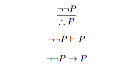

数学家采用哪一种，可能取决于其论文发表所属的具体领域。在最后一种情况下，他们会保留 → 来表示“我们可以证明”，并且只用 ⇒ 表示“蕴含”。Which one a mathematician uses can depend on the particular field they publish in. In the last case, they will reserve → to mean “we can prove” and exclusively use ⇒ to mean “implies”.

# 实用重写规则Useful Rewrite Rules

## 重言式表Table of Tautologies

其中一些使用 `=`，表示两个公式等同，可以相互替换。另一些使用 `=>`，表示**只能沿一个方向推导**。Some of these are `=`, to mean the two formulas are identical- you can substitute one for the other. Some are `=>`, meaning **they only go one way**.

命题逻辑：Propositional Logic:

```
P = !!P

P && !P = False
P || !P = True
```

德摩根律：De Morgan’s law:

```
!P && !Q = !(P || Q)
!P || !Q = !(P && Q)

!P && Q = !(P || !Q)
```

### 蕴含Implication

定义：Definition:

```
P => Q = !P || Q
!(P => Q) = P && !Q
```

逆否命题：Contrapositive:

```
P => Q = !Q => !P

(P => Q) && (Q => P) = (P = Q)
```

传递性：`(P => Q && Q => R) => (P => R)` 注意，这里*不是* `=`！它不能双向推导！Transitivity: `(P => Q && Q => R) => (P => R)` Note it’s *not* an `=`! It doesn’t go both ways!

### 量词Quantifiers

提取：Extraction:

```
all x: P &&/|| Q(x) = P &&/|| all x: Q(x)
```

对偶：Duals:

```
all x: P(x) = !(some x: !P(x))
some x: P(x) = !(all x: !P(x))

all x: !P(x) = !(some x: P(x))
some x: !P(x) = !(all x: P(x))
```

交换性：Commutativity:

```
all x in S: (all y in T: ...) =
all y in T: (all x in S: ...) =
all x in S, y in T: ...

all x in S, y in S: ... =
all x, y in S: ...

some x in S: (some y in T: ...) =
some y in T: (some x in S: ...) =
some x in S, y in T: ...

some x in S, y in S: ... =
some x, y in S: ...
```

#### 与其他结构结合With other stuff

分配性：Distributivity:

```
some x: P(x) || Q(x)
  some x: P(x) || some x: Q(x)

all x: P(x) && Q(x)
  all x: P(x) && all x: Q(x)
```

# 逻辑之外Beyond Logic

注Note

本节的所有内容都需要请数学家彻底核查。此外，如果篇幅太长又没有帮助，也可能整节删掉。EVERYTHING in the section needs to be thoroughly checked against a mathematician. Also it might be thrown out entirely if it’s too long and not helpful.

整本书讨论的都是经典一阶逻辑。这是多数数学家用来做数学的逻辑。但*数学是灵活的*，而且数学家不喜欢把一个体系视为理所当然。因此，许多数学家都问过：“如果我们改变逻辑，会发生什么？”This entire book is about classical first order logic. That’s the logic that most mathematicians use to do math. But *mathematics is flexible* and mathematicians hate taking a system for granted. So many mathematicians have asked “what happens if we make logic different?”

这里介绍其中一些改变逻辑的方式。This is some of about those ways of making logic different.

## 边界：罗素悖论The Limit: Russell’s Paradox

对于每个集合 `s`，我们都可以创建一个谓词 `S(x) = x in s`。这意味着每个集合都定义了一个谓词。反过来也成立吗：对于每个谓词，能否找到由所有满足该谓词的事物组成的集合？For every set `s`, we can create a predicate `S(x) = x in s`. This means every set defines a predicate. Is the opposite true: for every predicate, can we find a set of all things that pass that predicate?

```
CanRunProgram(c) = RAM(c) && (CPU(c) || GPU(c))

->

CanRunProgram = RAM & (CPU | GPU)
```

在*朴素集合论*中，这对所有集合都成立。但朴素集合论存在一个问题，导致数学家在一个多世纪前放弃了它。考虑谓词 `Evil(x) = x not in x`，也就是 x 不是包含自身的集合。大多数集合都满足这个谓词：`{}`、`{1}`、`{[1, 3], abc}`，等等。有些集合不满足它，比如“所有非空集合组成的集合”。如果所有谓词都能形成集合，反之亦然，那么我们就会有一个集合 `evil`，即由所有不包含自身的集合组成的集合。In *naive set theory*, this is true for all sets. Naive set theory has a problem, though, that lead to mathematicians abandoning it over a century ago. Consider the predicate `Evil(x) = x not in x`, aka x is not a set that contains itself. Most sets would pass this predicate: `{}`, `{1}`, `{[1, 3], abc}`, etc. Some sets would fail this predicate, like “the set of all non-empty sets”. If all predicates formed sets and vice versa, we’d have a set `evil`, the set of all sets that don’t contain themselves.

那么 `Evil(evil)` 为真吗？如果为真，`evil` 就不包含自身，这意味着它不属于 `evil`，所以根据定义，`Evil(evil)` 为假；但这样它又不属于 `evil`，意味着它不包含自身，也就意味着 `Evil(evil)` 为真……Now is `Evil(evil)` true? If so, `evil` doesn’t contain itself, meaning it’s not in `evil`, so `Evil(evil)` is false by definition, but then it’s not in `evil`, meaning it doesn’t contain itself, meaning `Evil(evil)` is true…

## 高阶逻辑Higher Order Logic

在本书前面，我写过Early in the book I wrote

> 为了避免诡异的数学恐怖，谓词*不能*属于论域：不存在以其他谓词为参数的谓词。So as to prevent eldritch math horrors, predicates *cannot* be in the domain of discourse: there are no predicates that take other predicates.

这使我们的逻辑成为*一阶逻辑*。在*高阶逻辑*中，谓词既可以作为值传递，也可以用于量词：This makes our logic a *first-order logic*. In a *higher-order logic*, predicates can be both passed as values and used as quantifiers:

```
Symmetric(P) = all x, y: P(x, y) == P(y, x)
```

多数数学家宁愿坚持使用一阶逻辑，因为高阶逻辑太“强大”了。正如我采访过的一位逻辑学家所说：“你可不想让你的逻辑突然造出一艘火箭。”这可以粗略类比计算机科学中的图灵完备性。分析图灵完备语言比分析限制更多的语言更困难。Most mathematicians prefer to stick with first-order logic because higher order logic is too “powerful”. As one logician I interviewed put it, “you don’t want your logic suddenly building a rocket ship.” A rough analogy would be to Turing completeness in computer science. It’s harder to analyze a Turing complete language than a more limited one.

## 构造性逻辑Constructive Logic

在本书最最开头，我说过“所有谓词都返回真或假”。这就是*排中律*：任何陈述不是真就是假。陈述不可能处于某种“第三种状态”。At the very very beginning of the book, I said “all predicates return true or false”. This is the *Law of Excluded Middle*: any statement is true or false. There is no “third thing” a statement can be.

这带来了一件不同寻常的事：如果要证明某件事为真，可以选择证明它“并非为假”。如果要证明一个集合非空，也可以改为证明这个集合不可能为空。这称为“非构造性证明”，因为你并没有真正构造出该集合中的一个值。This leads to something unusual: if you want to prove something true, you have the option of proving it “non-false”. And if you want to prove a set is nonempty, you can instead prove that it’s impossible for the set to be empty. This is called a “non-constructive proof”, since you aren’t actually constructing a value inside that set.

我最喜欢的例子是国际象棋。想象我们玩一个略有变化的版本：不是白方总是先走，而是可以选择先走还是后走。有了这条额外规则，就可以轻易证明，白方拥有一个万无一失、能*始终*获胜或和棋的策略：My favorite example of this is Chess. Imagine we are playing a slight variation where, instead of White always moving first, they can choose whether to move first or second. With this extra rule, we can trivially prove that White has a foolproof strategy to *always* win or tie:

假设白方没有万无一失的策略。那么，只要双方都完美行棋，黑方就总能获胜。但这时白方可以放弃第一回合，实际上成为后手，再遵循黑方的必胜策略。这意味着黑方没有必胜策略，也就意味着白方必定有一个万无一失的策略。Assume White doesn’t have a foolproof strategy. Then, assuming perfect play, Black always wins. But then White can pass on their first turn, making them effectively the second player, and then follow the winning strategy for Black. This means that Black doesn’t have a winning strategy, which means White must have a foolproof one.

这个证明优雅而严密。但对于*那个万无一失的策略到底是什么*，它没有提供任何信息，所以国际象棋仍然顽固地难以求解。It’s an elegant and watertight proof. It also gives us zero information on *what the foolproof strategy actually is*, and so chess remains stubbornly intractable.

非构造性证明让一些数学家感到不满，于是他们提出了另一种逻辑，称为*构造性逻辑*。构造性逻辑没有排中律，也没有双重否定规则：不能把 `!!P` 替换为 `P`。去掉这两条规则，使得编写证明和变换陈述更加困难。但作为回报，它保证要证明某个事物存在，唯一方式就是真正找出一个实例。Non-constructive proofs bother some mathematicians, who proposed an alternate form of logic called *Constructive Logic*. Constructive logic doesn’t have the law of excluded middle, nor does it have double-negation: you can’t replace `!!P` with `P`. These two removals mean that writing proofs and manipulating statements is harder. But in return, it guarantees the only way to prove the existence of something is to actually find an example.

构造性逻辑的另一个结果是，没有排中律，蕴含的行为就能更接近日常语言。“如果我叫 Greg，那么我就是英格兰国王”这个陈述在经典逻辑中在数学上为真（我不叫 Greg），但在日常生活中并不是一个真陈述。在构造性逻辑中，它也不一定为真。Another consequence of constructive logic is that without excluded middle, implication can work a little more like it does in normal language. The statement “if I was named Greg, then I’d be king of England” is mathematical true in classical logic (I’m not named Greg), but it’s not a true statement in day to day life. And it doesn’t have to be in constructive logic, either.

函数式编程风格的类型系统在本质上是构造性的。类型为 `Int -> Bool` 的函数是一个“证明”：如果整数存在，布尔值也存在，因为有一种方法能把一个整数实例转换成一个布尔值实例。Functional programming-style type systems are constructive by nature. A function of type `Int -> Bool` is a “proof” that if integers exist, booleans do too, because there’s a way to turn an example of an integer into an example of a boolean.

## 模态逻辑Modal Logic

谓词逻辑用关于*数量*的陈述扩展布尔值：陈述 P 是对集合中的所有元素为真，还是对至少一个元素为真？*模态逻辑*则用关于*性质*的陈述扩展布尔值：陈述 P 是“必然”为真，还是“可能”为真？Predicate logic augments booleans with statements over *quantity*: is statement P true for all elements of a set, or true for at least one? *Modal logic* instead augments booleans with statements of *quality*: is statement P true “necessarily”, or “possibly”?

例如，假设称量某个物体得到 100 克，但秤有 0.5 克的不确定误差。那么真实重量必然小于 101 克，并且可能小于 99.9 克。“必然”和“可能”互为对偶，因此“可能 P”等同于“并非必然非 P”。For example, say we weigh something and find it is 100 grams, but our scale has an uncertainty error of 0.5 grams. The true weight is necessarily less than 101 grams, and possibly less than 99.9 grams. Necessarily and possibly are duals, so “possibly P” is the same as “not necessarily not P”.

除此之外，“必然”和“可能”的含义并不明确，因此也就存在许多不同的模态逻辑。哲学家用模态逻辑探索知识、道德、不确定性以及其他许多事物的本质。Beyond that, what “necessarily” and “possibly” mean are vague, which in turn means that there’s many different modal logics. Philosophers use modal logic to explore the nature of knowledge, morality, uncertainty, and many other things.

但最重要的模态逻辑，你已经见过了：*时间*模态。TLA+ 的*始终*和*最终*，其实就是“必然”和“可能”！But the most important modal logic is one you’ve already seen: the mode of *time*. TLA+’s’s *always* and *eventually* is just “necessarily” and “possibly”!

模态与量词（`all` 和 `some`）相互独立：你可以只有模态、只有量词，也可以两者都有。Modes are independent of quantifiers (`all` and `some`): you can have modes, quantifiers, or both.

# 练习答案Answers to Exercises

1. `!(Native(p) && (Q(p) || R(p))) || ((RAM(c) && CPU(c)) || GPU(c))`
2. `Native(p) && (Q(p) || R(p)) => (RAM(c) && CPU(c)) || GPU(c)`

我个人觉得 (2) 更容易读，因为嵌套表达式没那么多。I personally find (2) much easier to read, since we don’t have as many nested expressions.

（返回） (back)

```
CanRunProgram(c, p) =
  Native(p) => (RAM(c, p) && CPU(c, p)) || GPU(c, p) (back)
```

1. `(Native(p) => !Web(p)) && (Web(p) => !Native(p))`
2. `!(Web(p) && Native(p))`
3. `!Native(p) || !Web(p)`

（返回） (back)

1. `(c => x) && (!c => y)` 与 `(!c || x) && (c || y)` 等价。如果逐一分析各个情形，你应该会发现，当 `c` 和 `x` 都为真，或者 `c` 为假而 `y` 为真时，`IfThenElse` 为真。`(c => x) && (!c => y)` is equivalent to `(!c || x) && (c || y)`. If you work through the cases, you should find that `IfThenElse` is true when `c` is true and `x` is true, or when `c` is false and `y` is true.
2. 顾名思义，`IfThenElse` 模拟的是条件判断。我们也可以这样写：As hinted by the name `IfThenElse` is simulating a conditional. We can also write it like this:

> ```
> IfElse(c: Bool, x: Bool, y: Bool) =
>   if c then x else y
> ```

> （返回） (back)

`CanRunProgram = (RAM & CPU) | GPU`

（返回） (back)

`Child & Adult == {}`。另一种写法是 `Child - Adult == Child && Adult - Child == Adult`。`Child & Adult == {}`. Another way would be `Child - Adult == Child && Adult - Child == Adult`.

（返回） (back)

一种写法是 `(S - T) | (T - S)`；另一种是 `(S | T) - (S & T)`。One way is `(S - T) | (T - S)`; another is `(S | T) - (S & T)`.

（返回） (back)

如果没有任何开发者评审过这个 PR，那么 `EveryoneApproved` 为真（总共零位评审者全都批准了！），而 `SomeoneReviewed` 为假（没有人评审过）。If not a single developer has reviewed the pr, then `EveryoneApproved` is true (all zero reviewers approved!) while `SomeoneReviewed` is false (nobody reviewed it).

一般来说，`all x in {}: P(x)` 始终为真（无论 `P` 是什么），而 `some x in {}: P(x)` 始终为假。In general, `all x in {}: P(x)` is always true (regardless of what `P` is) and `some x in {}: P(x)` is always false.

（返回） (back)

1. `all x in Nat: x < x + 1`
2. `all x in Nat: 0 <= x`

（返回） (back)

1. `all pr in PR: some d in Developer: ApprovedBy(pr, d)`
2. `some d in Developer: all pr in PR: ReviewedBy(pr, d)`

（返回） (back)

`all a, b in Int: a > b => a..<b = a..=b = {}`.

（返回） (back)

```
{x in Int: 1 <= x && x <= 100} (back)
```

```
IsDivisibleBy(num, divisor) =
  some x in 1..=num:
    x*divisor = num (back)
```

```
some x, y: x != y && P (back)
```

```
all x, y, z:
  (1. x != y
   2. y != z
   3. z != x
  ) => P(x, y, z)
```

这足以说明加入 `disj` 很有道理！A pretty good argument for adding `disj`!

（返回） (back)

`all x: P(x)`

（返回） (back)

这是我想到的两个例子：Here are two I came up with:

1. “本周每一天都温暖而晴朗”等同于“[本周]每一天都温暖，而且每一天都晴朗”。“All days this week is warm and sunny” is the same as “all days [this week] are warm and all days are sunny”.
2. “有人的眼睛是蓝色或绿色”等同于“有人的眼睛是蓝色，或者有人的眼睛是绿色”。“Someone has blue eyes or green eyes” is the same as “someone has blue eyes or someone has green eyes.”

（返回） (back)

答案有很多，这里只给两个：There are many answers, here are just two:

1. “所有人都（活着或死了）”为真，“（所有人都活着）或（所有人都死了）”为假。“All people are (alive or dead)” is true, “(all people are alive) or (all people are dead)” is false.
2. “有人活着，而且有人死了”为真，“有人既活着又死了”为假。“Someone is alive and someone is dead” is true, “Someone is alive and dead” is false.

注意，每一组都*可以*沿一个方向改写。你*可以*把“所有石头都是蓝色，或者所有石头都是棕色”改写成“所有石头都是蓝色或棕色”，但*反过来不行*。Notice that each of them *can* go one way. You *can* rewrite “all rocks are blue or all rocks are brown” into “all rocks are blue or brown”, but *not the other way around*.

（返回） (back)

先把它改写为 `!P || Q`。然后把 `Q` 替换为 `!(!Q)`，得到 `!(!Q) || !P`。再将其改写为 `!Q => !P`。First rewrite it was `!P || Q`. Then replace `Q` with `!(!Q)` to get `!(!Q) || !P`. Then rewrite that as `!Q => !P`.

（返回） (back)

（返回） (back)

Python 和 Haskell 使用 `all()` 和 `any()`。Javascript 使用 `Array.every()` 和 `Array.some()`。C++ 有 `std::all_of()` 和 `std::any_of`，还有 `std::none_of`。Python and Haskell use `all()` and `any()`. Javascript uses `Array.every()` and `Array.some()`. C++ has `std::all_of()` and `std::any_of`, and also has `std::none_of`.

（返回） (back)

在 `all x in set: P(x) && some x in set: P(x)` 中，`some` 唯一的作用就是检查集合非空，因为只有集合为空时，`all x` 才可能为真而 `some x` 为假。因此，可以重写代码，去掉这一部分：In `all x in set: P(x) && some x in set: P(x)`, the only thing that the `some` is doing is checking that the set is nonempty, as that’s the only case where `all x` can be true and `some x` can be false. So we can rewrite the code to not have that:

```
return l != [] and all(P(x) for x in l) (back)
```

`x <= 1 || x > 10`

（返回） (back)

在 `all x in set: P(x) => Q(x)` 中，我们只对同时满足 `P(x)` 的元素检查 `Q(x)`。在 `all x in {x \in set: P(x)}: Q(x)` 中，我们筛掉所有不满足 `P(x)` 的元素，然后对剩余元素检查 `Q(x)`。等价性由此得出。In `all x in set: P(x) => Q(x)` we only check `Q(x)` on the elements that also satisfy `P(x)`. In `all x in {x \in set: P(x)}: Q(x)` we filter out all of the elements that don’t satisfy `P(x)` and then check `Q(x)` on the rest. Equivalence follows.

（返回） (back)

新版 `max_avail_price` 不再要求“至少存在一个可用商品”。如果没有可用商品，我们根本不会调用 `max`，因此不会违反它的要求。In the new version of `max_avail_price` it no longer requires “there is at least one available item”. If there are no available items, we never call `max` anyway, so don’t violate its requirements.

另一方面，`max_avail_price` 的*后置条件*变得更复杂了。*如果*返回值是数值，它仍然是可用商品的最高价格。如果返回值是 `None`，则表示没有可用商品。因此，新契约如下：On the other hand, `max_avail_price`’s *postconditions* get more complicated. *If* the return value is a number, it still is the highest price of an available item. If the return value is `None`, then there were no available items. So the new contract is this:

```
max_avail_price(items) returns o
helpers:
  available = `list of available items in items`
requires:
  NOTHING AT ALL
ensures:
  o == None => all i in Item: !i.available
  o != None =>
    `output is priciest available item`:
      some i in available:
        1. i.price = out
        2. all i2 in available: i2.price <= i.price (back)
```

1. ```
   function: sqrt(x) -> o
   requires: x >= 0
   ensures: o*o = x
   ```

2. 我会用类似 Python 的写法来做。I’ll do this in something like Python.

> ```python
> # requires: a != 0
> # requires: b^2 >= 4ac
> def quadratic(a, b, c):
>   lhs = -b / (2*a)
>
>   # requires: b^2 >= 4ac
>   # requires: a != 0
>   rhs = sqrt(b**2 - 4*a*c) / (2*a)
>
>   return (lhs + rhs, lhs - rhs)
> ```

3. 第 (1) 部分的功能规约漏了一点：`sqrt` 还*保证*输出非负。There’s one thing I left out of the functional specification in part (1): `sqrt` *guarantees* the output is nonnegative, too.

> ```
> function: sqrt(x) -> o
> requires: x >= 0
> ensures: o >= 0
> ensures: o*o = x
> ```

> 于是代码变成Then the code becomes

> ```
> x = 5
> # requires (a): x >= 0
> y = sqrt(x)
> # ensures (b): y >= 0
> # requires (b): y >= 0
> z = sqrt(y)
> ```

> 因此，要求得到了满足。So the requirement is satisfied.

> （返回） (back)

问题在于，我们漏掉了 `Rectangle.setWidth` 的保证：The issue is that we left out the ensurances of `Rectangle.setWidth`:

```
# ensures: width == x
# ensures: length == old(length)
Rectangle.setWidth(x)
```

换言之，`setWidth` 保证它*只*改变宽度，不改变长度。`Square.setWidth` 的后置条件并不更强，它们不蕴含 `Rectangle.setWidthPost`。如果让这些类不可变，这个问题就消失了。一般而言，实现可变抽象比实现可变抽象更难。In other words, `setWidth` ensures it *only* changes the width; it does not change the length. `Square.setWidth` doesn’t have stronger postconditions, they do not imply `Rectangle.setWidthPost`. This problem goes away if we make the classes immutable. In general, implementing a mutable abstraction is harder than implementing a mutable one.

（返回） (back)

```
constraint all u, ref in Users:
  u.referrer = ref => u.created_at > ref.created_at (back)
```

首先，如果 `S` 有 `s` 个元素，`T` 有 `t` 个元素，那么 `#S * #T == s*t`。由于集合的基数不取决于它有哪些*具体*元素，只取决于元素数量，因此可以放心地假设 `S = 1..=s` 且 `T = 1..=t`。现在，只需证明 `(1..=s) x (1..=t)` 有 `s*t` 个元素。为此，我把所有元素排成一个网格：First of all, if `S` has `s` elements and `T` has `t` elements, `#S * #T == s*t`. Since the cardinality of the set does not depend on *what* elements it has, only the number of elements, I can safely assume that `S = 1..=s` and `T = 1..=t`. Now, I just need to show that `(1..=s) x (1..=t)` has `s*t` elements. To do this, I will put all of the elements in a grid:

```
(1, 1) (1, 2)  ... (1, t)
(2, 1) (2, 2)  ... (2, t)
   .      .     .    .
(s, 1) (s, 2)  ... (s, t)
```

这个网格有 `s` 行、`t` 列，因此有 `s*t` 个元素。This grid has `s` rows and `t` columns, so it has `s*t` elements.

（返回） (back)

有两种做法。第一种是把所有内容写成一个谓词：There’s two ways we can do this. The first is to write it all as one predicate:

```
constraint
  all disj ug1, ug2 in user_groups:
    ug1.user_id != ug2.user_id ||
    ug1.group_id != ug2.group_id
```

不过，我更倾向于先写一个辅助运算符，再在实际约束中使用它。But the way I’d prefer to do it instead would be to first write a helper operator, and then use that in the actual constraint.

```
SameUserAndGroup(ug1, ug2: user_groups) =
  1. ug1.title = ug2.title
  2. ug1.author = ug2.author

constraint
  all disj ug1, ug2 in user_groups:
    !SameUserAndGroup(ug1, ug2) (back)
```

```
constraint UsersInGroupsHaveEmail =
  all ug in user_groups, u in users:
    ug.user_id = u.id => u.email != NULL (back)
```

```
MemberOf(u, g) =
  some ug in user_groups:
    1. ug.user_id = u.id
    2. ug.group_id = g.id

constraint MaxFiveMembers =
  all g in groups:
    #{u in User: MemberOf(u, g)} <= 5 (back)
```

```
ValidTransitions(task, from, to) =
  t.status = from => t.status' in (to | {from})
```

（必须用花括号把 `from` 括起来，因为不能对集合与字符串取并集，只能对集合与另一个集合取并集。）(We have to wrap `from` in braces because you can’t union a set and a string, only a set and another set.)

（返回） (back)

一个简单的例子：One simple example:

无效Invalid

| P? | **输出****out** |
| --- | --- |
| T | T |
| T | F |

这个表有两行，但既不可靠（两个相互矛盾的输入），也不完备（缺少一个输入）。这意味着它是无效的。The table has two rows, but is unsound (two contradictory inputs) and incomplete (missing an input). This means it is invalid.

（返回） (back)

（返回） (back)

| x % 3 == 0? | x % 5 == 0? | 输出out |
| --- | --- | --- |
| T | T | 输出“fizzbuzz”“fizzbuzz” |
| T | F | 输出“fizz”“fizz” |
| F | T | 输出“buzz”“buzz” |
| F | F | x |

| Z | W | H | M |
| --- | --- | --- | --- |
| T | - | - | T |
| F | 摄像头webcam | - | F |
| F | 桌面麦克风desk | T | T |
| F | 桌面麦克风desk | F | F |

（我在操作系统设置中禁用了摄像头麦克风，解决了这个问题）(I fixed it by disabling the webcam mic in the OS settings)

（返回） (back)

这由前置条件推出：`x >= 0` 和 `y > 0` 意味着 `x / y > 0`，而 `floor` 不能把正数变成负数。由于 `q == floor(x / y)`，所以 `q >= 0`。It follows from the preconditions: `x >= 0` and `y > 0` means that `x / y > 0`, and `floor` can’t make a positive number into a negative one. Since `q == floor(x / y)`, `q >= 0`.

（返回） (back)

有几种方式可以说明这一点。第一种是，如果测试 1 被分配给服务器 N，那么对其他任意服务器 M，都有子句 `(!a1N || !a1M)`。由于已经有 `a1N`，要让该子句为真，就只能是 `!a1M`，也就是测试 1 没有分配给 `M`。There’s a couple of ways to show this. The first is to say that if test 1 is assigned to server N, for any other server M we have the clause `(!a1N || !a1M)`. Since we already have `a1N`, the only way for the clause to be true is if `!a1M`, ie test 1 isn’t assigned to `M`.

另一种理解方式是把 `(!a11 || !a12) && (!a11 || !a13)` 改写为 `a11 => !a12 && a11 => !a13 ...`，它又等价于 `a11 => !a12 && !a13 && ...`。Another way to see this is to rewrite `(!a11 || !a12) && (!a11 || !a13)` as `a11 => !a12 && a11 => !a13 ...`, which is equivalent to `a11 => !a12 && !a13 && ...`.

（返回） (back)

每一步，Alice 都*必须*向 Bob 至少转账一美元。最终会存在某个 `t`，使得 `alice[t] == 0 && bob[t] == 20`。这时 Alice 无法转账，`Transfer(t)` 为假，因此 `Spec` 为假。At every step, Alice *must* transfer at least one dollar to Bob. Eventually there is some `t` where `alice[t] == 0 && bob[t] == 20`. Then Alice can’t make a transfer, `Transfer(t)` is false, and so `Spec` is false.

（返回） (back)

可以把 `Transfer(t)` 重命名为 `TransferAliceToBob(t)`，将反方向的转账写成一个新谓词，再把它加入 `next`。We can rename `Transfer(t)` to `TransferAliceToBob(t)`, write the converse as a new predicate, and then add it to `next`.

```
TransferBobToAlice(t: Time) =
  some value in 1..=bob[t]:
    1. alice[t+1] == alice[t] - value
    2. bob[t+1] == bob[t] + value

Next(t) =
  || TransferAliceToBob(t)
  || TransferBobToAlice(t)
```

那么，Alice 和 Bob 能在同一个步骤中相互转账吗？不能。假设双方开始时各有 10 美元，都试图向对方转账五美元。由 `TransferAliceToBob` 可得：Now, can Alice and Bob transfer to each other in the same step? No. Let’s say they both start with 10 dollars and each try to transfer five dollars to each other. By `TransferAliceToBob` we have:

```
1. alice[1] == alice[0] - 5 == 5
2. bob[1] == bob[0] + 5 == 15
```

而由 `TransferBobToAlice` 可得：And by `TransferBobToAlice`, we have:

```
1. bob[1] == bob[0] - 5 == 5
2. alice[1] == alice[0] + 5 == 15
```

这样就得到了 `alice[1] == 5 && alice[1] == 15`，它始终为假。So now we have `alice[1] == 5 && alice[1] == 15`, which is always false.

（返回） (back)

```
Stutter =
  1. alice' == alice
  2. bob' == bob (back)
```

对于 (1)，有：For (1), we have:

```
1. ``[](all x: P(x))``
2. ``all t in Time: all x: P(t, x)`` (definition of ``always``)
3. ``all x: all t in Time: P(t, x)`` (commutivity of ``all``)
4. ``all x: []P(x)`` (definition of ``always``)
```

2. 解法类似，只是改用分配性而非交换性。is solved similarly, except instead using distributivity instead of commutivity.

（返回） (back)

对于 (1)，有For (1), we have

1. `<>some x: P(x)`
2. `some t in Time: some x: P(t, x)`（`<>` 的定义）`some t in Time: some x: P(t, x)` (definition of `<>`)
3. `some x: some t in Time: P(t, x)`（`some` 的交换性）`some x: some t in Time: P(t, x)` (commutivity of `some`)
4. `some x: <>P(x)`（`<>` 的定义）`some x: <>P(x)` (definition of `<>`)
2. 解法类似，只是改用分配性而非交换性。(3) 用对偶性来解：is solved similarly, except instead using distributivity instead of commutivity. (3) is solved with duality:
1. `<>P`
2. `some t in Time: P(t)`
3. `!(all t in Time: !P(t))`（对偶）`!(all t in Time: !P(t))` (duals)
4. `![]!P`

（返回） (back)

回想一下，P 测试 `[1,2,3]` 的最大值为 3，而 R 测试 `[1, 2, 3]` 和 `[0, 1, -1]` 的最大值都 `>= 0`。Recall that P tests that the max of `[1,2,3]` is 3, while R tests that max values of `[1, 2, 3]` and `[0, 1, -1]` are `>= 0`.

1. 要通过 R 但不通过 P，写一个 `max(l) = 1`。要通过 P 但不通过 R，写一个只返回输入最后一个值的 `max`。 2.1. To pass R and not P, write a `max(l) = 1` . To pass P and not R, write a `max` that just returns the last value of the input. 2.

> ```
> T =
>   1. max([1, 2, 3]) == 3
>   2. max([0, 1, -1]) == 1
> ```

> 这会使上面给出的两种有缺陷的 `max` 实现都无法通过。This fails both buggy `max` implementations given above.
3. “T 与 P 和 R 一样强”就是 `T => P && R`。由于 `P => Q`，因此也有 `T => Q`，意味着 T 与 Q 一样强。“T is as strong as P and R” is `T => P && R`. Since `P => Q`, `T => Q` too, meaning T is as strong as Q.

（返回） (back)

`test false` 会拒绝 `max` 的任何有缺陷的实现……但它也会拒绝正确实现！一个测试之所以是“`max` 的测试”，就在于正确实现能够通过它。这意味着 `false` 根本不是 `max` 的测试（也不可能比它们更强）。`test false` will reject any buggy implementation of `max`… but it will also reject a correct implementation! What makes a given test “a test of `max`” is that it will pass for a correct implementation, meaning `false` isn’t a test of `max` at all (and cannot be stronger than them).

相比之下，`test true` *确实是* `max` 的有效测试，而且实际上是最弱的测试。By contrast, `test true` *is* a valid test of `max`, and in fact the weakest possible test.

（返回） (back)

```
IsUnique(l):
  all x, y in 0..<len(l):
    x != y => l[x] != l[y]
```

或者，使用 disj，可以改写成 `all disj x, y`，从而省去那个条件。Or, using disj, we could write `all disj x, y` instead and skip the condition.

（返回） (back)

用 Python 编写：In python:

```python
@given(s.lists(s.integers()), s.integers())
def test_myfind(l, x):
    out = myfind(l, x)
    if out == -1:
        assert x not in l
    else:
        assert l[out] == x
        assert x not in l[0:out]
```

注意，从统计上看，这会对 `x` 不在 `l` 中的情形测试过多。学会熟练使用基于性质的测试（PBT），其中一部分就是培养如何最好地生成输入的直觉。这方面的技巧超出了本书的范围。Note that this will statistically overtest the case where `x` is not in `l`. Part of learning to use PBT well is getting a sense of how to best generate inputs. The techniques here are beyond the scope of this book.

（返回） (back)

# 索引Index

**符号** | **A** | **B** | **C** | **D** | **E** | **F** | **I** | **L** | **M** | **P** | **Q** | **R** | **S** | **T** | **U** | **X** **Symbols** | **A** | **B** | **C** | **D** | **E** | **F** | **I** | **L** | **M** | **P** | **Q** | **R** | **S** | **T** | **U** | **X**

## 符号Symbols

- &（集合） & (set)
- &&（与） && (and)
- '（撇号） ' (prime)
- -（集合） - (set)
- -（表） - (table)
  - 参见“任意” see any
- =>（蕴含） => (implies)
- `反引号`（谓词中） `backticks` (in predicates)
- |（集合） | (set)
- ||（或） || (or)

## A

- 动作 action
- all（所有） all
- Alloy 语言 Alloy
- 任意（表） any (table)
- assert（断言） assert
- 断言 assertion

## B

- 行为 behavior

## C

- 笛卡尔积 cartesian product
- 完备 complete
- 合取范式 Conjunctive Normal Form
- 契约 contract

## D

- Dafny 语言 Dafny
- Datalog 语言 datalog
- 决策表 Decision Table
- 演绎数据库 deductive database
- disj（互异） disj
- 论域 Domain of Discourse

## E

- ensures（保证） ensures

## F

- 形式化规约 Formal Specification
- 形式化验证 Formal verification
- 模糊测试 fuzzing

## I

- in（集合中的属于关系） in (set)
- 不完备 incomplete
  - 参见“完备” see complete

## L

- 活性 liveness
- 逻辑编程 Logic programming
- 循环不变式 loop invariant

## M

- 蜕变性质 Metamorphic properties
- Minizinc 语言 Minizinc
- MISU（使非法状态无法表示） MISU

## P

- 规划 planning
- PlusCal 语言 PlusCal
- 后置条件 postcondition
- 幂集 power set
- 前置条件 precondition
- 谓词，[1] predicate, [1]
- 证明 proof
- 基于性质的测试 Property-Based Testing

## Q

- 量词，[1] quantifier, [1]
  - 限定范围的量词 scoped quantifier

## R

- 精化 refinement
- 关系模型 Relational Model
- requires（要求） requires
- 重写规则 rewrite rules

## S

- 安全性 safety
- 集合 set
- 集合筛选 set filter
- 集合映射 set map
- SMT（可满足性模理论） SMT
- some（存在） some
- 可靠 sound
- 规约 specification
  - 全定义 total
- 子集 subset

## T

- 时序逻辑 Temporal Logic
- 定理 Theorem
- TLA+ 语言 TLA+
- 真值表 truth table

## U

- 不可靠 unsound
  - 参见“可靠” see sound

## X

- x（集合） x (sets)
  - 参见“笛卡尔积” see cartesian product

# 数据库约束Database Constraints

数据库原生就能表示一些约束，例如 NOT NULL、UNIQUE 和外键约束。但有些更强大的约束，数据库可能无法表示。即便如此，能够表达这些约束，也能让我们更容易找到其他强制实施它们的方法，因此这些复杂约束十分有用。不过，首先需要把它们表示出来，而这就需要逻辑。Databases can natively represent some constraints, like NOT NULL, UNIQUE, and foreign key constraints. But there are more powerful constraints databases may not be able to represent. Even so, being able to express them makes it easier for us to find other ways of enforcing them, making these complex constraints quite useful. First, though, we need to represent them, and that requires logic.

## 逻辑Logic

### 一种记录语法A Record Syntax

首先，假设所有数据库表都表示*集合*。如果有一个名为 `Users` 的表，那么表中的每条记录就表示集合 Users 中的一个元素。每个用户都有一个唯一的整数“id”。能否纯粹用谓词做到这一点？Let’s start by assuming that all database tables represent *sets*. If we have a table called `Users` then each record in that table represents an element from the set Users. Each user has a unique integer “id”. Can we do that purely with predicates?

```
UserId(u: User, id: Int) = `user u has id `id``

EwEwEw =
  all u in Users:
    some id in Int:
      1. UserId(u, id)
      2. all notid in Int - {id}:
         !UserId(u, notid)
```

好吧，这太糟糕了。显然，我们需要一种表示记录的方式，不必为“用户有 id”写上六行。如前所述，如果某件事谈起来很笨拙，就创造新的记法来讨论它。因此，让我们引入一种记录语法：Okay that sucks, clearly we’re going to want a way to represent records without having to write six lines for “users have ids.” As mentioned before, if something is clunky to talk about, we come up with new notation to discuss it. So let’s introduce a record syntax:

```
record Users {
  id: Int
}
```

把它理解为“每个用户恰好有一个 id，该 id 属于整数集合”。如果想表示可空列，可以用集合的并来实现。为方便起见，规定 `set + x` 与 `set | {x}` 是同一种写法。Take this to mean “every user has exactly one id, which is in the set of Integers.” If we wanted to represent a nullable column, we could do that with a set union. We’ll say that `set + x` is the same as writing `set | {x}` for convenience.

```
record Users {
  id: Int
  email: String + NULL
}
```

### 简单约束Simple Constraints

我们的记录记法可以表示 SQL 约束 `NOT NULL`，但还不能表示约束 `UNIQUE`。虽然可以扩展语法来涵盖它，但这是一本关于*逻辑*的书，所以我们来寻找逻辑上的解决方案。Our record notation can represent the SQL constraint `NOT NULL`, but it can’t yet represent the constraint `UNIQUE`. While we could extend our syntax to cover this, this is a book about *logic*, so let’s look for a logical solution.

```
constraint UserIdUnique = `no two users have the same id`
```

我在前面加上“constraint”，因为我个人喜欢使用大量辅助谓词，希望显式标出哪些才是真正的系统约束。无论如何，这是一个标准的唯一性谓词（使用 disj）：I put “constraint” in front because I personally like using a lot of helper predicates, and I want to explicitly label the ones that are actual system constraints. Anyway, this is a standard uniqueness predicate (using disj):

```
constraint UserIdUnique =
  all disj u1, u2 in Users:
    u1.id != u2.id
```

这个约束有趣的地方在于，它约束的不是单个用户，而是用户*对*。每个用户单独看都是有效记录，但两者放在一起就违反了约束。Something interesting about this constraint is that it’s not a constraint on individual users, it’s a constraint on *pairs* of users. Each user is a valid record on its own, but both of them together violates our constraint.

练习：复合键Exercise: Compound keys

给定Given

```
record Books {
  title: str,
  author: str
}

constraint UniqueCompound =
  `title + author is a compound unique key`
```

两本书可以同名，也可以有同一位作者，但不能同时拥有相同的书名和作者组合。请写出谓词 `UniqueCompound`。Two books can have the same title and two books can have the same author, but two books cannot have the same title/author combo. Write the predicate `UniqueCompound`.

解答Solution

### 外键约束Foreign Key Constraints

我们来做一件稍复杂的事。假设还有一张 Groups 表，并且所有群组都必须有一个用户担任管理员。在 SQL 中，大致会是这样：Let’s do something a little more complicated. Say we also have a Groups table, and all groups must have an admin user. In SQL, that would look something like:

```
CREATE TABLE group (
    id integer,
    admin_id REFERENCES user(id)
    // ...
);
```

下面是直译成“记录语法”的结果：Here’s the literal translation to “record syntax”:

```
record Groups {
  id: Int
  admin_id: Int
}
```

我们可以这样把外键约束表示为逻辑谓词：Here’s how we can represent the foreign key constraint as a logical predicate:

```
IsAdmin(u, g) = u.id = g.admin_id

constraint AllGroupsHaveAdmin =
  all g in Groups:
    some u in Users:
      IsAdmin(u, g)
```

注意这里的“交替量词”：我们把 `some` 嵌套在 `all` 内。这表示“对所有群组，都存在某个用户担任管理员”。不过，每个群组对应的用户可以不同。如果改写成Notice the “alternating quantifiers”: we’re nesting a `some` inside of an `all`. This says “for all groups, there is some user who is the Admin”. It can be a different user per group, though. If we instead wrote

```
"constraint" AllGroupsHaveAdmin =
  some u in Users:
    all g in Groups:
      IsAdmin(u, g)
```

那就变成了“存在某个用户，是所有群组的管理员”。That would instead say “there is some user who is the admin of all groups.”

练习：空外键Exercise: Null foreign keys

有时，外键列可以为 null：Sometimes a foreign key column can be null:

```
record Groups {
  id: Int
  admin_id: Int + NULL
}
```

但如果不为 null，它就必须指向一个用户。请对此建模。If it’s not null, though, it must point to a user. Model this.

解答Solution

或者，也可以用如下这种不太严谨的方式（使用集合映射记法）：Alternatively, we could do something handwavey like this (using set map notation):

```
record Groups {
  id: Int
  admin_id: {u.id for u in Users}
}
```

可以用同样的方式加入多对多关联表。让我们加入群组成员关系：We can use the same thing to add many to many tables. Let’s add group memberships:

```
record GroupMembership {
  id: int
  user_id: int
  group_id: int
}

MemberOf(u, g) =
  some gm in GroupMemberships:
    1. gm.user_id = u.id
    2. gm.group_id = g.id
```

练习Exercise

写出约束：“两条不同的群组成员记录不能同时对应同一个用户和同一个群组。”Write the constraint “two different group memberships can’t be for the same user and the same group.”

解答Solution

练习Exercise

写出约束：“群组的管理员必须是该群组的成员。”Write the constraint “The admin of a group must be a member of that group.”

解答Solution

练习Exercise

令 `#S` 表示 `S` 中的元素个数。写出约束：“所有群组都至多只能有五个成员。”Let `#S` be the number of elements in `S`. Write the constraint “all groups can only have five members at most.”

> 提示：使用集合筛选。HINT: Use set filter.

解答Solution

### 更复杂的约束More Complex Constraints

既然已经跨过了表示基本 SQL 结构的初步障碍，我们就可以充分运用逻辑的力量来表达约束。这远远超出了专用 SQL 关键字所能做到的范围。例如，用逻辑很容易表达“每个群组都需要一位*是活跃用户的*管理员”：Now that we’re past the basic hurdles of representing basic SQL constructs, we can use the full power of logic to express our constraints. This can go far beyond what we can do with the dedicated SQL keywords. For example, it’s easy to use logic to say “every group needs an admin *that’s an active user*”:

```
constraint AllGroupsHaveAdmin =
  all g in Groups:
    some u in Users:
      1. IsAdmin(g, u)
      2. IsActive(u)
```

或者，所有*在某个日期之后创建的*群组都需要一位活跃的管理员：Or all groups *created after a certain date* need an active admin:

```
constraint all g in Groups:
  g.date > legacy_date =>
    some u in Users:
        1. IsAdmin(g, u)
        2. IsActive(u)
```

而这还只是一个基本数据库约束的两种变体！只要你能想到某个约束，很可能就有某个产品需要它。And that’s just a couple variants on a fundamental database constraint! If you can think of a constraint, there’s probably some product out there that needs it.

[[使用逻辑的意义就在于能够思考这些问题。如果只考虑那些可以用 SQL 原生表达的约束，就无法识别出许多你可能需要的约束类别。]][[The point of using logic is being able to think about these things. If you restrict yourself to only thinking of constraints that you can express natively in SQL, you won’t recognize large classes of constraints that you may need.]]

注Note

这里还需要写些什么才有用？只加例子？还是介绍约束的类别？What else needs to be written here to make this useful? Just examples? Classes of constraints?

### 变更约束Change Constraints

有时，约束针对的不是记录*是什么*，而是记录可以如何*变化*。例如，可以规定群组在开始时*没有*管理员：Sometimes a constraint isn’t on what record *is* but on how a record could *change*. For example, we might have that groups can start *without* an admin:

```
record Groups {
  id: Int
  admin_id: Int + NULL
}
```

但群组一旦*有了*管理员，就不能再回到没有管理员的状态。But once a group *has* an admin, it cannot go back to having no admin.

为此建模时，可以借用前面处理决策表时的一个技巧：每当 x 发生变化，就定义 `x` 为（该瞬间的）旧值，`x'`（读作 x 撇）为（该瞬间的）新值。To model this, we can adapt a trick we used earlier with decision tables: whenever x changes, we can define `x` to be the old value (in that instant) and `x'` (x-prime) to be the new value (in that instant).

```
constraint NoNullAfterAdmin =
  all g in Groups:
    g.admin_id != NULL => g.admin_id' != NULL
```

因此，一旦 admin_id 不为 null，下一个值也不能为 null，意味着它再也不能变回 null。So once the admin_id isn’t null, the next value can’t be null either, meaning that it can never go back to null.

这也适用于状态机列：一条记录可以经历 `WAITING -> READY` 或 `READY -> DONE`，但不能经历 `WAITING -> DONE`。这种情况下，通常应该“允许 x 变成它自身”：This is also useful for state machine columns: a record can go `WAITING -> READY` or `READY -> DONE`, but not `WAITING -> DONE`. In that case it’s considered good form to “allow x to change to itself”:

```
constraint StateMachineTransitions ==
  all t in Tasks:
    1. t.status = "WAITING" => t.status' in {"WAITING", "READY"}
    2. t.status = "READY => t.status' in {"READY", "DONE"}
```

练习：转移辅助谓词Exercise: Transition Helper

编写一个辅助谓词 `ValidTransitions(task, from, to)`，使我们能够这样写出 `StateMachineTransitions` 的主体：Write a helper predicate `ValidTransitions(task, from, to)`, so that we can write the body of `StateMachineTransitions` this way:

```
all t in Tasks:
  1. ValidTransitions(task, "WAITING", {"READY"})
  2. ValidTransitions(task, "READY", {"DONE"})
```

注意，`to` 将是一个转移的集合。Note that `to` is going to be a set of transitions.

解答Solution

## 实践：强制实施数据库约束In Practice: Enforcing Database Constraints

现在，理论要落到实践中了。一旦知道有哪些约束，该如何确保系统能够强制实施它们？This is where the theory becomes practice. Once you know what the constraints are, how do you make sure your system can enforce them?

### 盘点你具备的能力Take stock of your capabilities

你的系统有哪些组件，它们能强制实施什么？What are the components of your system, and what can they enforce?

例如，如果使用 Postgres，就可以建立[行级约束](https://www.postgresql.org/docs/current/ddl-constraints.html) [https://www.postgresql.org/docs/current/ddl-constraints.html]：For example, if you’re working with Postgres, you can make [row-level constraints](https://www.postgresql.org/docs/current/ddl-constraints.html) [https://www.postgresql.org/docs/current/ddl-constraints.html]:

```
CREATE TABLE intervals (
    id integer,
    start integer,
    end integer
    CHECK (start < end)
);
```

如果使用 [Ruby on Rails](https://guides.rubyonrails.org/active_record_validations.html) [https://guides.rubyonrails.org/active_record_validations.html] 这样的 Web 框架，就有可定制的验证代码。组件能直接强制实施的要求更容易处理，在实施过程中也更不容易出错。If you’re using a web framework like [Ruby on Rails](https://guides.rubyonrails.org/active_record_validations.html) [https://guides.rubyonrails.org/active_record_validations.html], you have customizable validation code. Things that the components can directly enforce are easier to handle, and you’re less likely to make a mistake enforcing them.

要注意，多数人对工具的使用远未达到专家水平。我直到写这本书时，才知道 Postgres 能（通过 `TRIGGER`）检查变更约束。Be aware that most of us don’t using our tools at anywhere near the expert level. I didn’t know until writing book that Postgres can check change constraints (via `TRIGGER`).

### 按可实施性寻找类别Look for categories of enforceability

对于特定工具，某些*类别*的约束相对更容易或更难强制实施。多数数据库*非常*擅长强制实施“这一列必须唯一”和“这一列*除了* null 值之外必须唯一”。但对于“这一列*除了*数值 `19` 之外必须唯一”这样的要求，就没那么擅长了。Certain *classes* of constraints are relatively easier or harder to enforce with respect to certain tooling. Most database are *very* good at enforcing “this column must unique” and “this column must be unique *except for* null values”. But they’re worse at enforcing something like “this column must be unique *except* for the number `19`”.

有些限制可以绕过。SQL 没有蕴含运算符，所以不能写约束 `P => Q`。但*可以*写 `NOT P OR Q`。Some limitations can be worked around. SQL doesn’t have an implication operator, so you can’t write the constraint `P => Q`. But you *can* write `NOT P OR Q`.

### 尽早实施，也在最后把关Enforce early, enforce late

设想服务器接收到一条新记录，并尝试将其写入数据库。是应该在服务器收到请求时尽早强制实施约束，还是在数据库真正尝试写入时尽晚强制实施？Consider a server receiving a new record, which it tries to write to the database. Is it better to enforce the constraint as early as possible when the server receives the request, or as late as possible when the database actually tries to write it?

两者各有好处。在服务器层实施约束，能尽早发现问题，从而改善用户体验。另一方面，它的稳健性较差。可能出现这样的竞态条件：两台服务器在任何一台写入记录之前，都验证了记录的唯一性，最终导致重复记录。如果在数据库层实施约束，这种情况就不可能发生。They both have their benefits. Enforcing it at the server level recognizes the problem as soon as possible, which can lead to a better user experience. On the other hand, it’s less robust. You can have a race condition where two servers both validate a record is unique before either writes the record, leading to duplicate records. This is impossible if you enforce the constraint at the database level.

因此，很有理由在早期和晚期*都*实施约束。这也有一个缺点：如果需要验证的约束发生变化，两处的实现可能会不同步。That’s a good reason to enforce *both* early and late. This also has a drawback: if the constraints you need to validate change, the two can get out of sync.

### 无法强制实施时，就转而检查If you can’t enforce, look instead

显然，最好从一开始就不发生违规。但有时工具无法防止约束被破坏，有时约束又超出我们的控制范围。你可能有这样一条约束：“所有外部链接都指向有效的网站”：It’s obviously better to never have a violation in the first place. But sometimes our tools aren’t capable of preventing broken constraints, and sometimes constraints are out of our control. You might have the constraint “all outgoing links are to valid websites”:

```
all l in Link:
  Resolves(l.url)
```

如果网站后来下线，即使系统中什么也没变，约束也被破坏了！因此，我们无法保证它始终成立。If the website goes down later, then the constraint is broken, even if nothing changed in your system! So that’s something we can’t guarantee always holds.

在这种情况下，我觉得写一个检查约束违规的脚本很方便。大致如下：In these cases, I find it handy to write a script that checks for broken constraints. Something like this:

```python
for l in SELECT * FROM links:
  if get(l.url).response != 200:
     register_as_broken(l)
```

编程语言通常比约束语言灵活得多，因此更容易用它们编码约束。脚本可能只需每晚运行一次，并在早晨向你发送报告。Programming languages are typically much more flexible than constraint languages, so it’s easier to encode constraints in them. A script might only need to run nightly and can send you a report in the morning.

当约束相对不那么重要时，这种技巧更有用，所以首先了解相关风险很有帮助。This technique is more useful when the constraint is relatively minor, which is why it’s useful to understand the risks involved first.

## 小结Summary

1. 数据库约束实际上就是作为性质的逻辑谓词。Database constraints are actually logical predicates as properties.
2. 外键约束也是如此。So are foreign key constraints.
3. 谓词逻辑能够表达的约束种类远比数据库多。Predicate logic can express a much wider variety of constraints than databases can.
4. 能表达的约束越多，就越能找到办法实施更多约束，无论是在数据库中还是在别处。The more constraints you can express, the more constraints you can find ways to enforce, whether with the database or somewhere else.

到目前为止，我们的逻辑始终紧贴数据库：我们讨论的是数据库表和记录的性质。[[但数据库只是数据模型的一种不完美实现，而数据模型是我们试图使之清晰可理解的那部分世界的概念化表示。]] 下一章，我们将上升一个抽象层次，用逻辑研究数据模型。So far we’ve been keeping the logic very close to the database: we’re talking about properties of database tables and records. [[But the database is just an imperfect implementation of the data model, the conceptual slice of the world we’re trying to make legible.]] Next chapter we will use logic to study our data model, one level of abstraction higher.

### 延伸阅读Further Reading

- 关系模型：https://15445.courses.cs.cmu.edu/fall2019/notes/01-introduction.pdfThe Relational Model: https://15445.courses.cs.cmu.edu/fall2019/notes/01-introduction.pdf
- 你需要更多约束：https://borretti.me/article/you-need-more-constraintsYou Need More Constraints: https://borretti.me/article/you-need-more-constraints